# ANOVA test for segmentacao

Geiser C. Challco geiser@alumni.usp.br

- ANOVA: segmentacao ~ time
  - Data Preparation
  - Summary Statistics
  - ANOVA Computation
  - PairWise Computation
- ANOVA: segmentacao ~ time*gender + Error(id/time)
  - Data Preparation
    - Check assumptions: Identifying Outliers
    - Check assumptions: Normality Test
    - Summary Statistics
  - ANOVA Computation
  - ANOVA Computation after removing non.normal data
  - PairWise Computation
  - PairWise Computation after removing non.normal data
- ANOVA: segmentacao ~ time*localizacao + Error(id/time)
  - Data Preparation
    - Check assumptions: Identifying Outliers
    - Check assumptions: Normality Test
    - Summary Statistics
  - ANOVA Computation
  - ANOVA Computation after removing non.normal data
  - PairWise Computation
  - PairWise Computation after removing non.normal data
- ANOVA: segmentacao ~ time*regiao + Error(id/time)
  - Data Preparation
    - Check assumptions: Identifying Outliers
    - Check assumptions: Normality Test
    - Summary Statistics
  - ANOVA Computation
  - ANOVA Computation after removing non.normal data
  - PairWise Computation
  - PairWise Computation after removing non.normal data
- ANOVA: segmentacao ~ time*porte + Error(id/time)
  - Data Preparation
    - Check assumptions: Identifying Outliers
    - Check assumptions: Normality Test
    - Summary Statistics
  - ANOVA Computation
  - ANOVA Computation after removing non.normal data
  - PairWise Computation
  - PairWise Computation after removing non.normal data

```r
dat <- read_excel("../data/data.xlsx", sheet = "alunos_ef14")

escolas <- read_excel("../data/data.xlsx", sheet = "escolas")
edat <- merge(dat, escolas, by = "cod_escola", all.x = T)
```

# ANOVA: segmentacao ~ time

## Data Preparation

```r
data <- edat[,c("aluno_id","ciclo","segmentacao")]
data <- data[data$ciclo %in% c("Primeiro Ciclo","Segundo Ciclo","Terceiro Ciclo","Quarto Ciclo"),]
data$ciclo <- factor(data$ciclo, c("Primeiro Ciclo","Segundo Ciclo","Terceiro Ciclo","Quarto Ciclo"))
data <- unique(data)

wdat <- spread(data, ciclo, segmentacao)
wdat <- wdat[complete.cases(wdat),]
colnames(wdat) <- c("id","c1","c2","c3","c4")

ldat <- gather(wdat, key = time, value = segmentacao, c1,c2,c3,c4) %>%
  convert_as_factor(id, time)
ldat <- rshinystatistics::remove_group_data(ldat, "segmentacao", "time", n.limit = 30)
```

## Summary Statistics

```r
(sdat <- ldat %>% group_by(time) %>%
   get_summary_stats(segmentacao, type = "mean_sd"))
```

```
## # A tibble: 4 × 5
##   time  variable        n  mean    sd
##   <fct> <fct>       <dbl> <dbl> <dbl>
## 1 c1    segmentacao  1126  4.02 0.289
## 2 c2    segmentacao  1126  4.02 0.238
## 3 c3    segmentacao  1126  4.00 0.193
## 4 c4    segmentacao  1126  4.01 0.206
```

| time | variable | n | mean | sd |
| --- | --- | --- | --- | --- |
| c1 | segmentacao | 1126 | 4.016 | 0.289 |
| c2 | segmentacao | 1126 | 4.023 | 0.238 |
| c3 | segmentacao | 1126 | 3.999 | 0.193 |
| c4 | segmentacao | 1126 | 4.015 | 0.206 |

## ANOVA Computation

```r
(res.aov <- anova_test(ldat, dv = segmentacao, wid = id, within = time))
```

```
## ANOVA Table (type III tests)
##
## $ANOVA
##   Effect DFn  DFd     F     p p<.05   ges
## 1   time   3 3375 2.217 0.084       0.001
##
## $`Mauchly's Test for Sphericity`
##   Effect     W                            p p<.05
## 1   time 0.895 0.00000000000000000000000029     *
##
## $`Sphericity Corrections`
##   Effect  GGe        DF[GG] p[GG] p[GG]<.05   HFe       DF[HF] p[HF] p[HF]<.05
## 1   time 0.93 2.79, 3139.74 0.089           0.933 2.8, 3148.34 0.089
```

| Effect | DFn | DFd | F | p | p<.05 | ges |
| --- | --- | --- | --- | --- | --- | --- |
| time | 3 | 3375 | 2.217 | 0.084 |  | 0.001 |

| Effect | W | p | p<.05 |
| --- | --- | --- | --- |
| time | 0.895 | 0 | * |

| Effect | GGe | DF[GG] | p[GG] | p[GG]<.05 | HFe | DF[HF] | p[HF] | p[HF]<.05 |
| --- | --- | --- | --- | --- | --- | --- | --- | --- |
| time | 0.93 | 2.79, 3139.74 | 0.089 |  | 0.933 | 2.8, 3148.34 | 0.089 |  |

## PairWise Computation

```r
(pwc <- ldat %>% emmeans_test(segmentacao ~ time, detailed = T, p.adjust.method = "bonferroni"))
```

```
## # A tibble: 6 × 14
##   term  .y.       group1 group2 null.value estimate      se    df conf.low conf.high statistic      p
## * <chr> <chr>     <chr>  <chr>       <dbl>    <dbl>   <dbl> <dbl>    <dbl>     <dbl>     <dbl>  <dbl>
## 1 time  segmenta… c1     c2              0 -6.73e-3 0.00988  4500 -0.0261    0.0126    -0.682  0.495
## 2 time  segmenta… c1     c3              0  1.73e-2 0.00988  4500 -0.00204   0.0367     1.75   0.0796
## 3 time  segmenta… c1     c4              0  8.88e-4 0.00988  4500 -0.0185    0.0203     0.0899 0.928
## 4 time  segmenta… c2     c3              0  2.41e-2 0.00988  4500  0.00469   0.0434     2.44   0.0149
## 5 time  segmenta… c2     c4              0  7.62e-3 0.00988  4500 -0.0117    0.0270     0.772  0.440
## 6 time  segmenta… c3     c4              0 -1.64e-2 0.00988  4500 -0.0358    0.00293   -1.66   0.0963
## # ℹ 2 more variables: p.adj <dbl>, p.adj.signif <chr>
```

| term | .y. | group1 | group2 | null.value | estimate | se | df | conf.low | conf.high | statistic | p | p.adj | p.adj.signif |
| --- | --- | --- | --- | --- | --- | --- | --- | --- | --- | --- | --- | --- | --- |
| time | segmentacao | c1 | c2 | 0 | -0.007 | 0.01 | 4500 | -0.026 | 0.013 | -0.682 | 0.495 | 1.000 | ns |
| time | segmentacao | c1 | c3 | 0 | 0.017 | 0.01 | 4500 | -0.002 | 0.037 | 1.754 | 0.080 | 0.478 | ns |
| time | segmentacao | c1 | c4 | 0 | 0.001 | 0.01 | 4500 | -0.018 | 0.020 | 0.090 | 0.928 | 1.000 | ns |
| time | segmentacao | c2 | c3 | 0 | 0.024 | 0.01 | 4500 | 0.005 | 0.043 | 2.435 | 0.015 | 0.089 | ns |
| time | segmentacao | c2 | c4 | 0 | 0.008 | 0.01 | 4500 | -0.012 | 0.027 | 0.772 | 0.440 | 1.000 | ns |
| time | segmentacao | c3 | c4 | 0 | -0.016 | 0.01 | 4500 | -0.036 | 0.003 | -1.664 | 0.096 | 0.578 | ns |

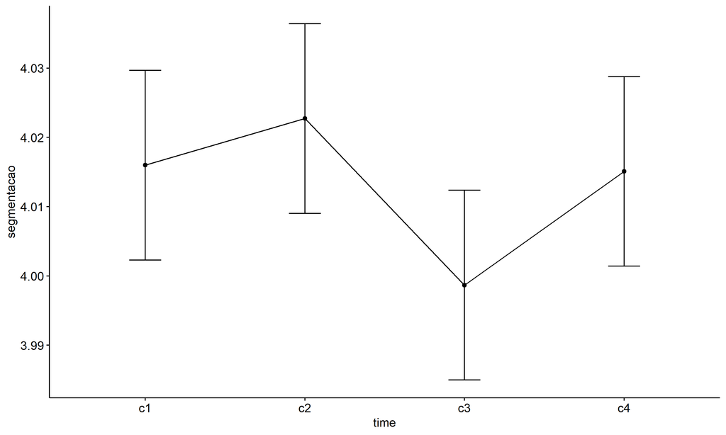

```r
pwc <- add_xy_position(pwc, x = "time", fun = "mean_se")
ggline(get_emmeans(pwc), x = "time", y = "emmean", ylab = "segmentacao") +
  geom_errorbar(aes(ymin = conf.low, ymax = conf.high), width = 0.2) +
  stat_pvalue_manual(pwc, hide.ns = T, tip.length = F)
```

# ANOVA: segmentacao ~ time*gender + Error(id/time)

## Data Preparation

```r
data <- edat[,c("aluno_id","gender","ciclo","segmentacao")]
data <- data[data$ciclo %in% c("Primeiro Ciclo","Segundo Ciclo","Terceiro Ciclo","Quarto Ciclo"),]
data$ciclo <- factor(data$ciclo, c("Primeiro Ciclo","Segundo Ciclo","Terceiro Ciclo","Quarto Ciclo"))
data <- unique(data)

wdat <- spread(data, ciclo, segmentacao)
wdat <- wdat[complete.cases(wdat),]
colnames(wdat) <- c("id","gender","c1","c2","c3","c4")

ldat <- gather(wdat, key = time, value = segmentacao, c1,c2,c3,c4) %>%
  convert_as_factor(id, time)
ldat <- remove_group_data(ldat, "segmentacao", c("time", "gender"), n.limit = 30)
ldat$gender <- factor(ldat$gender, sort(unique(ldat$gender)))
```

### Check assumptions: Identifying Outliers

```r
outliers <- identify_outliers(group_by(ldat, time, gender), segmentacao)
(outliers <- outliers[outliers$is.extreme == T,])
```

```
## # A tibble: 429 × 6
##    gender time  id                   segmentacao is.outlier is.extreme
##    <fct>  <fct> <fct>                      <dbl> <lgl>      <lgl>
##  1 Female c1    1Ao7d6oeWOGn5CkNSJxn         4.5 TRUE       TRUE
##  2 Female c1    1rGKIQ7fdZBOxxGdPFrp         5   TRUE       TRUE
##  3 Female c1    2DvDBlRadL6QdD6eJdDP         5   TRUE       TRUE
##  4 Female c1    2JRv4aJX5ZiAWFd1UXo7         3.5 TRUE       TRUE
##  5 Female c1    2qbgEyCWhU8ChVoKwmf5         5   TRUE       TRUE
##  6 Female c1    46nUNvt4sDOPsC9jnkiG         3.5 TRUE       TRUE
##  7 Female c1    4AM4nonwJ45LiMy6b4lp         4.5 TRUE       TRUE
##  8 Female c1    4tC0rHbjrsSU8gnHaaJ3         3.5 TRUE       TRUE
##  9 Female c1    4tkeMKZn4I9ZqCsB9HtZ         4.5 TRUE       TRUE
## 10 Female c1    5AeP0IQ84CerIQVenp2G         4.5 TRUE       TRUE
## # ℹ 419 more rows
```

| gender | time | id | segmentacao | is.outlier | is.extreme |
| --- | --- | --- | --- | --- | --- |
| Female | c1 | 1Ao7d6oeWOGn5CkNSJxn | 4.500 | TRUE | TRUE |
| Female | c1 | 1rGKIQ7fdZBOxxGdPFrp | 5.000 | TRUE | TRUE |
| Female | c1 | 2DvDBlRadL6QdD6eJdDP | 5.000 | TRUE | TRUE |
| Female | c1 | 2JRv4aJX5ZiAWFd1UXo7 | 3.500 | TRUE | TRUE |
| Female | c1 | 2qbgEyCWhU8ChVoKwmf5 | 5.000 | TRUE | TRUE |
| Female | c1 | 46nUNvt4sDOPsC9jnkiG | 3.500 | TRUE | TRUE |
| Female | c1 | 4AM4nonwJ45LiMy6b4lp | 4.500 | TRUE | TRUE |
| Female | c1 | 4tC0rHbjrsSU8gnHaaJ3 | 3.500 | TRUE | TRUE |
| Female | c1 | 4tkeMKZn4I9ZqCsB9HtZ | 4.500 | TRUE | TRUE |
| Female | c1 | 5AeP0IQ84CerIQVenp2G | 4.500 | TRUE | TRUE |
| Female | c1 | 5aLGVYNAMR84kxneNKFw | 3.000 | TRUE | TRUE |
| Female | c1 | 5WOchSZgUhx0OWTzb7cj | 3.000 | TRUE | TRUE |
| Female | c1 | AcPM8yalCG1JwgFkGEUa | 5.000 | TRUE | TRUE |
| Female | c1 | aOGxFSPrreKjHqmQIKKA | 4.500 | TRUE | TRUE |
| Female | c1 | bOhetFcZCcckN4VKJMtL | 3.000 | TRUE | TRUE |
| Female | c1 | CquTenVuBSFELLzcDuZm | 5.000 | TRUE | TRUE |
| Female | c1 | CRe8TWnc28z2KudiaQpG | 4.500 | TRUE | TRUE |
| Female | c1 | cV5XHPnJL5QhFRSG3oM4 | 3.000 | TRUE | TRUE |
| Female | c1 | d1JgyezU4pt7F4SebGoe | 3.000 | TRUE | TRUE |
| Female | c1 | D3zCmRj97N1xSw2RGyIX | 4.500 | TRUE | TRUE |
| Female | c1 | dJQJl5Fk0r29tPHPdig0 | 3.000 | TRUE | TRUE |
| Female | c1 | DP1fbT1lGhLiBnOFILLi | 4.500 | TRUE | TRUE |
| Female | c1 | e01kWx8LyQ5MBbqcIbXn | 5.000 | TRUE | TRUE |
| Female | c1 | ffnFAMZehkOjgmmGyq3E | 3.000 | TRUE | TRUE |
| Female | c1 | g6NpZa7qfNr4u2gcV0gv | 5.000 | TRUE | TRUE |
| Female | c1 | GcoCtxzprm7V40SNuUHZ | 5.000 | TRUE | TRUE |
| Female | c1 | gTUYwk2z23T9FqE617Q6 | 3.500 | TRUE | TRUE |
| Female | c1 | hruSgzhJbTGT2UHE0CPK | 4.500 | TRUE | TRUE |
| Female | c1 | jipIzfMPngc6Se2mEtoO | 5.000 | TRUE | TRUE |
| Female | c1 | k1Byic1gWlgNIFT8qDpn | 4.500 | TRUE | TRUE |

[output cut: 399 more lines]

### Check assumptions: Normality Test

```r
(normality.df <- normality.test.per.groups(ldat, "segmentacao", c("time", "gender")))
```

```
##           var    variable time gender   n   skewness  kurtosis symmetry statistic     method p
## 1 segmentacao segmentacao   c1 Female 552  0.3935709  8.213271       NO 110.59448 D'Agostino 0
## 2 segmentacao segmentacao   c1   Male 513 -0.1555346  6.053425       NO  76.33144 D'Agostino 0
## 3 segmentacao segmentacao   c2 Female 552  0.8705609 11.880326       NO 174.40232 D'Agostino 0
## 4 segmentacao segmentacao   c2   Male 513  0.4729871  9.629611       NO 117.86395 D'Agostino 0
## 5 segmentacao segmentacao   c3 Female 552 -0.3824561 17.061744       NO 155.38361 D'Agostino 0
## 6 segmentacao segmentacao   c3   Male 513 -1.0744335 16.313777       NO 201.38931 D'Agostino 0
## 7 segmentacao segmentacao   c4 Female 552  0.3554236 11.717500       NO 130.01724 D'Agostino 0
## 8 segmentacao segmentacao   c4   Male 513  0.4610782 20.223917       NO 160.74726 D'Agostino 0
##   p.signif normality
## 1     ****         -
## 2     ****         -
## 3     ****         -
## 4     ****         -
## 5     ****         -
## 6     ****         -
## 7     ****         -
## 8     ****         -
```

| var | variable | time | gender | n | skewness | kurtosis | symmetry | statistic | method | p | p.signif | normality |
| --- | --- | --- | --- | --- | --- | --- | --- | --- | --- | --- | --- | --- |
| segmentacao | segmentacao | c1 | Female | 552 | 0.394 | 8.213 | NO | 110.594 | D’Agostino | 0 | **** | - |
| segmentacao | segmentacao | c1 | Male | 513 | -0.156 | 6.053 | NO | 76.331 | D’Agostino | 0 | **** | - |
| segmentacao | segmentacao | c2 | Female | 552 | 0.871 | 11.880 | NO | 174.402 | D’Agostino | 0 | **** | - |
| segmentacao | segmentacao | c2 | Male | 513 | 0.473 | 9.630 | NO | 117.864 | D’Agostino | 0 | **** | - |
| segmentacao | segmentacao | c3 | Female | 552 | -0.382 | 17.062 | NO | 155.384 | D’Agostino | 0 | **** | - |
| segmentacao | segmentacao | c3 | Male | 513 | -1.074 | 16.314 | NO | 201.389 | D’Agostino | 0 | **** | - |
| segmentacao | segmentacao | c4 | Female | 552 | 0.355 | 11.718 | NO | 130.017 | D’Agostino | 0 | **** | - |
| segmentacao | segmentacao | c4 | Male | 513 | 0.461 | 20.224 | NO | 160.747 | D’Agostino | 0 | **** | - |

```r
(non.ids <- unique(do.call(
  c, lapply(which(normality.df$normality == 'NO'), FUN = function(i) {
  idx = which(ldat$time == normality.df$time[i] &
                ldat$gender == normality.df$gender[i])
  getNonNormal(ldat$"segmentacao"[idx], ldat$id[idx])
}))))
```

```r
if (length(non.ids) > 0)
  ldat2 <- ldat[!ldat$id %in% non.ids,]
```

### Summary Statistics

```r
(sdat <- ldat %>% group_by(time, gender) %>%
   get_summary_stats(segmentacao, type = "mean_sd"))
```

```
## # A tibble: 8 × 6
##   gender time  variable        n  mean    sd
##   <fct>  <fct> <fct>       <dbl> <dbl> <dbl>
## 1 Female c1    segmentacao   552  4.03 0.27
## 2 Male   c1    segmentacao   513  4.00 0.304
## 3 Female c2    segmentacao   552  4.03 0.223
## 4 Male   c2    segmentacao   513  4.02 0.257
## 5 Female c3    segmentacao   552  4.01 0.202
## 6 Male   c3    segmentacao   513  3.99 0.182
## 7 Female c4    segmentacao   552  4.02 0.232
## 8 Male   c4    segmentacao   513  4.01 0.179
```

| gender | time | variable | n | mean | sd |
| --- | --- | --- | --- | --- | --- |
| Female | c1 | segmentacao | 552 | 4.029 | 0.270 |
| Male | c1 | segmentacao | 513 | 3.999 | 0.304 |
| Female | c2 | segmentacao | 552 | 4.031 | 0.223 |
| Male | c2 | segmentacao | 513 | 4.016 | 0.257 |
| Female | c3 | segmentacao | 552 | 4.007 | 0.202 |
| Male | c3 | segmentacao | 513 | 3.986 | 0.182 |
| Female | c4 | segmentacao | 552 | 4.020 | 0.232 |
| Male | c4 | segmentacao | 513 | 4.008 | 0.179 |

```r
if (length(non.ids) > 0)
  (sdat <- ldat2 %>% group_by(time, gender) %>%
      get_summary_stats(segmentacao, type = "mean_sd"))
```

| gender | time | variable | n | mean | sd |
| --- | --- | --- | --- | --- | --- |
| Female | c1 | segmentacao | 552 | 4.029 | 0.270 |
| Male | c1 | segmentacao | 513 | 3.999 | 0.304 |
| Female | c2 | segmentacao | 552 | 4.031 | 0.223 |
| Male | c2 | segmentacao | 513 | 4.016 | 0.257 |
| Female | c3 | segmentacao | 552 | 4.007 | 0.202 |
| Male | c3 | segmentacao | 513 | 3.986 | 0.182 |
| Female | c4 | segmentacao | 552 | 4.020 | 0.232 |
| Male | c4 | segmentacao | 513 | 4.008 | 0.179 |

## ANOVA Computation

```r
(res.aov <- anova_test(ldat, dv = segmentacao, wid = id, between = gender, within = time))
```

```
## ANOVA Table (type III tests)
##
## $ANOVA
##        Effect DFn  DFd     F     p p<.05      ges
## 1      gender   1 1063 6.687 0.010     * 0.002000
## 2        time   3 3189 2.511 0.057       0.002000
## 3 gender:time   3 3189 0.305 0.821       0.000208
##
## $`Mauchly's Test for Sphericity`
##        Effect     W                          p p<.05
## 1        time 0.901 0.000000000000000000000285     *
## 2 gender:time 0.901 0.000000000000000000000285     *
##
## $`Sphericity Corrections`
##        Effect   GGe       DF[GG] p[GG] p[GG]<.05   HFe        DF[HF] p[HF] p[HF]<.05
## 1        time 0.935 2.8, 2981.05 0.061           0.938 2.81, 2989.74 0.061
## 2 gender:time 0.935 2.8, 2981.05 0.808           0.938 2.81, 2989.74 0.809
```

| Effect | DFn | DFd | F | p | p<.05 | ges |
| --- | --- | --- | --- | --- | --- | --- |
| gender | 1 | 1063 | 6.687 | 0.010 | * | 0.002 |
| time | 3 | 3189 | 2.511 | 0.057 |  | 0.002 |
| gender:time | 3 | 3189 | 0.305 | 0.821 |  | 0.000 |

| Effect | W | p | p<.05 |
| --- | --- | --- | --- |
| time | 0.901 | 0 | * |
| gender:time | 0.901 | 0 | * |

| Effect | GGe | DF[GG] | p[GG] | p[GG]<.05 | HFe | DF[HF] | p[HF] | p[HF]<.05 |
| --- | --- | --- | --- | --- | --- | --- | --- | --- |
| time | 0.935 | 2.8, 2981.05 | 0.061 |  | 0.938 | 2.81, 2989.74 | 0.061 |  |
| gender:time | 0.935 | 2.8, 2981.05 | 0.808 |  | 0.938 | 2.81, 2989.74 | 0.809 |  |

## ANOVA Computation after removing non.normal data

```r
if (length(non.ids) > 0)
  (res.aov2 <- anova_test(ldat2, dv = segmentacao, wid = id, between = gender , within = time))
```

## PairWise Computation

```r
(pwc <- ldat %>% group_by(time) %>%
   emmeans_test(segmentacao ~ gender, detailed = T, p.adjust.method = "bonferroni"))
```

```
## # A tibble: 4 × 15
##   time  term   .y.        group1 group2 null.value estimate     se    df conf.low conf.high statistic
## * <fct> <chr>  <chr>      <chr>  <chr>       <dbl>    <dbl>  <dbl> <dbl>    <dbl>     <dbl>     <dbl>
## 1 c1    gender segmentac… Female Male            0   0.0300 0.0144  4252  0.00174    0.0582     2.08
## 2 c2    gender segmentac… Female Male            0   0.0153 0.0144  4252 -0.0129     0.0435     1.06
## 3 c3    gender segmentac… Female Male            0   0.0209 0.0144  4252 -0.00733    0.0491     1.45
## 4 c4    gender segmentac… Female Male            0   0.0121 0.0144  4252 -0.0161     0.0403     0.843
## # ℹ 3 more variables: p <dbl>, p.adj <dbl>, p.adj.signif <chr>
```

| time | term | .y. | group1 | group2 | null.value | estimate | se | df | conf.low | conf.high | statistic | p | p.adj | p.adj.signif |
| --- | --- | --- | --- | --- | --- | --- | --- | --- | --- | --- | --- | --- | --- | --- |
| c1 | gender | segmentacao | Female | Male | 0 | 0.030 | 0.014 | 4252 | 0.002 | 0.058 | 2.081 | 0.037 | 0.037 | * |
| c2 | gender | segmentacao | Female | Male | 0 | 0.015 | 0.014 | 4252 | -0.013 | 0.044 | 1.064 | 0.287 | 0.287 | ns |
| c3 | gender | segmentacao | Female | Male | 0 | 0.021 | 0.014 | 4252 | -0.007 | 0.049 | 1.451 | 0.147 | 0.147 | ns |
| c4 | gender | segmentacao | Female | Male | 0 | 0.012 | 0.014 | 4252 | -0.016 | 0.040 | 0.843 | 0.399 | 0.399 | ns |

```r
(emms <- get_emmeans(pwc))
```

```
## # A tibble: 8 × 8
##   time  gender emmean      se    df conf.low conf.high method
##   <fct> <fct>   <dbl>   <dbl> <dbl>    <dbl>     <dbl> <chr>
## 1 c1    Female   4.03 0.00999  4252     4.01      4.05 Emmeans test
## 2 c1    Male     4.00 0.0104   4252     3.98      4.02 Emmeans test
## 3 c2    Female   4.03 0.00999  4252     4.01      4.05 Emmeans test
## 4 c2    Male     4.02 0.0104   4252     4.00      4.04 Emmeans test
## 5 c3    Female   4.01 0.00999  4252     3.99      4.03 Emmeans test
## 6 c3    Male     3.99 0.0104   4252     3.97      4.01 Emmeans test
## 7 c4    Female   4.02 0.00999  4252     4.00      4.04 Emmeans test
## 8 c4    Male     4.01 0.0104   4252     3.99      4.03 Emmeans test
```

| time | gender | emmean | se | df | conf.low | conf.high | method |
| --- | --- | --- | --- | --- | --- | --- | --- |
| c1 | Female | 4.029 | 0.01 | 4252 | 4.009 | 4.049 | Emmeans test |
| c1 | Male | 3.999 | 0.01 | 4252 | 3.979 | 4.019 | Emmeans test |
| c2 | Female | 4.031 | 0.01 | 4252 | 4.012 | 4.051 | Emmeans test |
| c2 | Male | 4.016 | 0.01 | 4252 | 3.996 | 4.036 | Emmeans test |
| c3 | Female | 4.007 | 0.01 | 4252 | 3.988 | 4.027 | Emmeans test |
| c3 | Male | 3.986 | 0.01 | 4252 | 3.966 | 4.007 | Emmeans test |
| c4 | Female | 4.020 | 0.01 | 4252 | 4.000 | 4.040 | Emmeans test |
| c4 | Male | 4.008 | 0.01 | 4252 | 3.987 | 4.028 | Emmeans test |

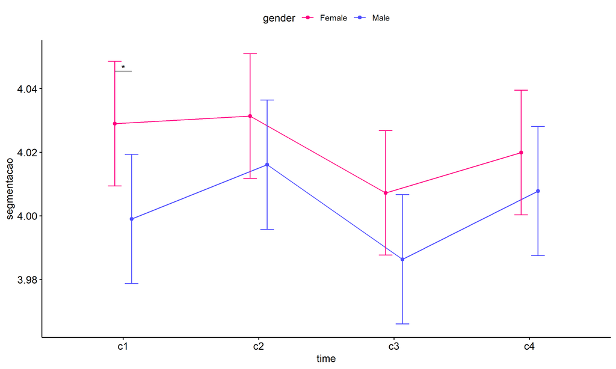

```r
pwc <- add_xy_position(pwc, x = "time", fun = "mean_se", dodge = 0.25)
pd <- position_dodge(width = 0.25)
ggline(emms, x = "time", y = "emmean", color = "gender",
       palette = c("#FF007F","#4D4DFF"),
       position = pd, ylab = "segmentacao") +
  geom_errorbar(aes(ymin = conf.low, ymax = conf.high, color = gender),
                position = pd, width = 0.2) +
  stat_pvalue_manual(pwc, hide.ns = T, tip.length = F, linetype = 1)
```

```r
(pwc <- ldat %>% group_by(gender) %>%
    emmeans_test(segmentacao ~ time, detailed = T, p.adjust.method = "bonferroni"))
```

```
## # A tibble: 12 × 15
##    gender term  .y.       group1 group2 null.value estimate     se    df conf.low conf.high statistic
##  * <fct>  <chr> <chr>     <chr>  <chr>       <dbl>    <dbl>  <dbl> <dbl>    <dbl>     <dbl>     <dbl>
##  1 Female time  segmenta… c1     c2              0 -0.00242 0.0141  4252 -3.01e-2   0.0253     -0.171
##  2 Female time  segmenta… c1     c3              0  0.0217  0.0141  4252 -5.96e-3   0.0494      1.54
##  3 Female time  segmenta… c1     c4              0  0.00906 0.0141  4252 -1.86e-2   0.0368      0.641
##  4 Female time  segmenta… c2     c3              0  0.0242  0.0141  4252 -3.54e-3   0.0519      1.71
##  5 Female time  segmenta… c2     c4              0  0.0115  0.0141  4252 -1.62e-2   0.0392      0.812
##  6 Female time  segmenta… c3     c4              0 -0.0127  0.0141  4252 -4.04e-2   0.0150     -0.898
##  7 Male   time  segmenta… c1     c2              0 -0.0171  0.0147  4252 -4.58e-2   0.0117     -1.16
##  8 Male   time  segmenta… c1     c3              0  0.0127  0.0147  4252 -1.61e-2   0.0414      0.865
##  9 Male   time  segmenta… c1     c4              0 -0.00877 0.0147  4252 -3.75e-2   0.0200     -0.599
## 10 Male   time  segmenta… c2     c3              0  0.0297  0.0147  4252  9.96e-4   0.0585      2.03
## 11 Male   time  segmenta… c2     c4              0  0.00828 0.0147  4252 -2.04e-2   0.0370      0.565
## 12 Male   time  segmenta… c3     c4              0 -0.0214  0.0147  4252 -5.02e-2   0.00729    -1.46
## # ℹ 3 more variables: p <dbl>, p.adj <dbl>, p.adj.signif <chr>
```

| gender | term | .y. | group1 | group2 | null.value | estimate | se | df | conf.low | conf.high | statistic | p | p.adj | p.adj.signif |
| --- | --- | --- | --- | --- | --- | --- | --- | --- | --- | --- | --- | --- | --- | --- |
| Female | time | segmentacao | c1 | c2 | 0 | -0.002 | 0.014 | 4252 | -0.030 | 0.025 | -0.171 | 0.864 | 1.000 | ns |
| Female | time | segmentacao | c1 | c3 | 0 | 0.022 | 0.014 | 4252 | -0.006 | 0.049 | 1.539 | 0.124 | 0.744 | ns |
| Female | time | segmentacao | c1 | c4 | 0 | 0.009 | 0.014 | 4252 | -0.019 | 0.037 | 0.641 | 0.521 | 1.000 | ns |
| Female | time | segmentacao | c2 | c3 | 0 | 0.024 | 0.014 | 4252 | -0.004 | 0.052 | 1.710 | 0.087 | 0.524 | ns |
| Female | time | segmentacao | c2 | c4 | 0 | 0.011 | 0.014 | 4252 | -0.016 | 0.039 | 0.812 | 0.417 | 1.000 | ns |
| Female | time | segmentacao | c3 | c4 | 0 | -0.013 | 0.014 | 4252 | -0.040 | 0.015 | -0.898 | 0.369 | 1.000 | ns |
| Male | time | segmentacao | c1 | c2 | 0 | -0.017 | 0.015 | 4252 | -0.046 | 0.012 | -1.164 | 0.245 | 1.000 | ns |
| Male | time | segmentacao | c1 | c3 | 0 | 0.013 | 0.015 | 4252 | -0.016 | 0.041 | 0.865 | 0.387 | 1.000 | ns |
| Male | time | segmentacao | c1 | c4 | 0 | -0.009 | 0.015 | 4252 | -0.038 | 0.020 | -0.599 | 0.549 | 1.000 | ns |
| Male | time | segmentacao | c2 | c3 | 0 | 0.030 | 0.015 | 4252 | 0.001 | 0.058 | 2.028 | 0.043 | 0.255 | ns |
| Male | time | segmentacao | c2 | c4 | 0 | 0.008 | 0.015 | 4252 | -0.020 | 0.037 | 0.565 | 0.572 | 1.000 | ns |
| Male | time | segmentacao | c3 | c4 | 0 | -0.021 | 0.015 | 4252 | -0.050 | 0.007 | -1.463 | 0.143 | 0.861 | ns |

```r
(emms <- get_emmeans(pwc))
```

```
## # A tibble: 8 × 8
##   gender time  emmean      se    df conf.low conf.high method
##   <fct>  <fct>  <dbl>   <dbl> <dbl>    <dbl>     <dbl> <chr>
## 1 Female c1      4.03 0.00999  4252     4.01      4.05 Emmeans test
## 2 Female c2      4.03 0.00999  4252     4.01      4.05 Emmeans test
## 3 Female c3      4.01 0.00999  4252     3.99      4.03 Emmeans test
## 4 Female c4      4.02 0.00999  4252     4.00      4.04 Emmeans test
## 5 Male   c1      4.00 0.0104   4252     3.98      4.02 Emmeans test
## 6 Male   c2      4.02 0.0104   4252     4.00      4.04 Emmeans test
## 7 Male   c3      3.99 0.0104   4252     3.97      4.01 Emmeans test
## 8 Male   c4      4.01 0.0104   4252     3.99      4.03 Emmeans test
```

| gender | time | emmean | se | df | conf.low | conf.high | method |
| --- | --- | --- | --- | --- | --- | --- | --- |
| Female | c1 | 4.029 | 0.01 | 4252 | 4.009 | 4.049 | Emmeans test |
| Female | c2 | 4.031 | 0.01 | 4252 | 4.012 | 4.051 | Emmeans test |
| Female | c3 | 4.007 | 0.01 | 4252 | 3.988 | 4.027 | Emmeans test |
| Female | c4 | 4.020 | 0.01 | 4252 | 4.000 | 4.040 | Emmeans test |
| Male | c1 | 3.999 | 0.01 | 4252 | 3.979 | 4.019 | Emmeans test |
| Male | c2 | 4.016 | 0.01 | 4252 | 3.996 | 4.036 | Emmeans test |
| Male | c3 | 3.986 | 0.01 | 4252 | 3.966 | 4.007 | Emmeans test |
| Male | c4 | 4.008 | 0.01 | 4252 | 3.987 | 4.028 | Emmeans test |

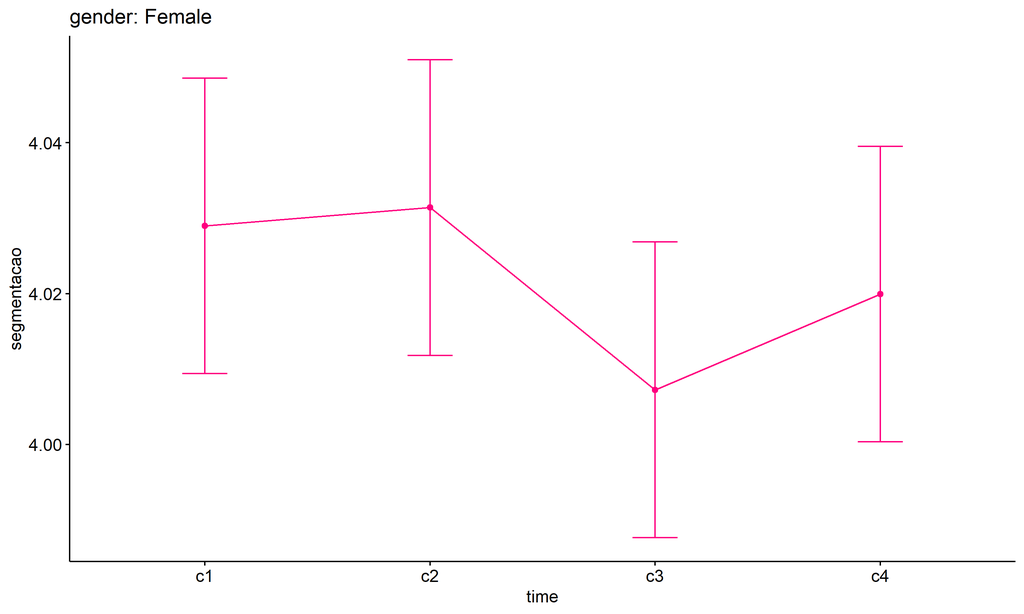

```r
emms.gg <- emms[which(emms$gender == "Female"),]
if (nrow(emms.gg) > 0)
  ggline(emms.gg, x = "time", y = "emmean", color = "#FF007F", ylab = "segmentacao") +
    geom_errorbar(aes(ymin = conf.low, ymax = conf.high),
                  width = 0.2, color = "#FF007F") +
    stat_pvalue_manual(
      add_xy_position(pwc[which(pwc$gender == "Female"),],
                      x = "time", fun = "mean_se"),
      hide.ns = T, color = "#FF007F", tip.length = F) +
    labs(title = "gender: Female")+
    theme(legend.text = element_blank())
```

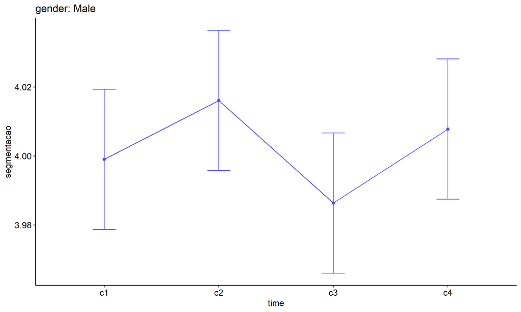

```r
emms.gg <- emms[which(emms$gender == "Male"),]
if (nrow(emms.gg) > 0)
  ggline(emms.gg, x = "time", y = "emmean", color = "#4D4DFF", ylab = "segmentacao") +
    geom_errorbar(aes(ymin = conf.low, ymax = conf.high),
                  width = 0.2, color = "#4D4DFF") +
    stat_pvalue_manual(
      add_xy_position(pwc[which(pwc$gender == "Male"),],
                      x = "time", fun = "mean_se"),
      hide.ns = T, color = "#4D4DFF", tip.length = F) +
    labs(title = "gender: Male")+
    theme(legend.text = element_blank())
```

## PairWise Computation after removing non.normal data

```r
if (length(non.ids) > 0)
  (pwc2 <- ldat2 %>% group_by(time) %>%
     emmeans_test(segmentacao ~ gender, detailed = T, p.adjust.method = "bonferroni"))
```

```r
if (length(non.ids) > 0)
  (emms2 <- get_emmeans(pwc2))
```

```r
if (length(non.ids) > 0) {
  pwc2 <- add_xy_position(pwc2, x = "time", fun = "mean_se", dodge = 0.25)
  pd2 <- position_dodge(width = 0.25)

  ggline(emms2, x = "time", y = "emmean", color = "gender",
         palette = c("#FF007F","#4D4DFF"),
         position = pd, ylab = "segmentacao") +
    geom_errorbar(aes(ymin = conf.low, ymax = conf.high, color = gender),
                position = pd, width = 0.2) +
    stat_pvalue_manual(pwc2, hide.ns = T, tip.length = F, linetype = 1)
}
```

```r
if (length(non.ids) > 0)
  (pwc2 <- ldat2 %>% group_by(gender) %>%
     emmeans_test(segmentacao ~ time, detailed = T, p.adjust.method = "bonferroni"))
```

```r
if (length(non.ids) > 0)
  (emms2 <- get_emmeans(pwc2))
```

```r
if (length(non.ids) > 0) {
  emms.gg <- emms2[which(emms2$gender == "Female"),]
  if (nrow(emms.gg) > 0)
    ggline(emms.gg, x = "time", y = "emmean", color = "#FF007F", ylab = "segmentacao") +
    geom_errorbar(aes(ymin = conf.low, ymax = conf.high),
                  width = 0.2, color = "#FF007F") +
    stat_pvalue_manual(
      add_xy_position(pwc[which(pwc$gender == "Female"),],
                      x = "time", fun = "mean_se"),
      hide.ns = T, color = "#FF007F", tip.length = F) +
    labs(title = "gender: Female") +
    theme(legend.text = element_blank())
}
```

```r
if (length(non.ids) > 0) {
  emms.gg <- emms2[which(emms2$gender == "Male"),]
  if (nrow(emms.gg) > 0)
    ggline(emms.gg, x = "time", y = "emmean", color = "#4D4DFF", ylab = "segmentacao") +
    geom_errorbar(aes(ymin = conf.low, ymax = conf.high),
                  width = 0.2, color = "#4D4DFF") +
    stat_pvalue_manual(
      add_xy_position(pwc[which(pwc$gender == "Male"),],
                      x = "time", fun = "mean_se"),
      hide.ns = T, color = "#4D4DFF", tip.length = F) +
    labs(title = "gender: Male") +
    theme(legend.text = element_blank())
}
```

# ANOVA: segmentacao ~ time*localizacao + Error(id/time)

## Data Preparation

```r
data <- edat[,c("aluno_id","localizacao","ciclo","segmentacao")]
data <- data[data$ciclo %in% c("Primeiro Ciclo","Segundo Ciclo","Terceiro Ciclo","Quarto Ciclo"),]
data$ciclo <- factor(data$ciclo, c("Primeiro Ciclo","Segundo Ciclo","Terceiro Ciclo","Quarto Ciclo"))
data <- unique(data)

wdat <- spread(data, ciclo, segmentacao)
wdat <- wdat[complete.cases(wdat),]
colnames(wdat) <- c("id","localizacao","c1","c2","c3","c4")

ldat <- gather(wdat, key = time, value = segmentacao, c1,c2,c3,c4) %>%
  convert_as_factor(id, time)
ldat <- remove_group_data(ldat, "segmentacao", c("time", "localizacao"), n.limit = 30)
ldat$localizacao <- factor(ldat$localizacao, sort(unique(ldat$localizacao)))
```

### Check assumptions: Identifying Outliers

```r
outliers <- identify_outliers(group_by(ldat, time, localizacao), segmentacao)
(outliers <- outliers[outliers$is.extreme == T,])
```

```
## # A tibble: 446 × 6
##    localizacao time  id                   segmentacao is.outlier is.extreme
##    <fct>       <fct> <fct>                      <dbl> <lgl>      <lgl>
##  1 Rural       c1    1Ao7d6oeWOGn5CkNSJxn         4.5 TRUE       TRUE
##  2 Rural       c1    2wBgWJVF1mK6rnsBiZ99         3   TRUE       TRUE
##  3 Rural       c1    7AsCrRYMyhVRQHX4kZdc         3   TRUE       TRUE
##  4 Rural       c1    D3zCmRj97N1xSw2RGyIX         4.5 TRUE       TRUE
##  5 Rural       c1    fETGhIde8enSW1EPqWMS         3   TRUE       TRUE
##  6 Rural       c1    GRXCU0bF6TElSKj1QNCL         4.5 TRUE       TRUE
##  7 Rural       c1    hruSgzhJbTGT2UHE0CPK         4.5 TRUE       TRUE
##  8 Rural       c1    k1Byic1gWlgNIFT8qDpn         4.5 TRUE       TRUE
##  9 Rural       c1    KBTZEriJAFvcWw48Xxgc         3.5 TRUE       TRUE
## 10 Rural       c1    m5AeVuITWa7uCAG6h1Qh         3   TRUE       TRUE
## # ℹ 436 more rows
```

| localizacao | time | id | segmentacao | is.outlier | is.extreme |
| --- | --- | --- | --- | --- | --- |
| Rural | c1 | 1Ao7d6oeWOGn5CkNSJxn | 4.500 | TRUE | TRUE |
| Rural | c1 | 2wBgWJVF1mK6rnsBiZ99 | 3.000 | TRUE | TRUE |
| Rural | c1 | 7AsCrRYMyhVRQHX4kZdc | 3.000 | TRUE | TRUE |
| Rural | c1 | D3zCmRj97N1xSw2RGyIX | 4.500 | TRUE | TRUE |
| Rural | c1 | fETGhIde8enSW1EPqWMS | 3.000 | TRUE | TRUE |
| Rural | c1 | GRXCU0bF6TElSKj1QNCL | 4.500 | TRUE | TRUE |
| Rural | c1 | hruSgzhJbTGT2UHE0CPK | 4.500 | TRUE | TRUE |
| Rural | c1 | k1Byic1gWlgNIFT8qDpn | 4.500 | TRUE | TRUE |
| Rural | c1 | KBTZEriJAFvcWw48Xxgc | 3.500 | TRUE | TRUE |
| Rural | c1 | m5AeVuITWa7uCAG6h1Qh | 3.000 | TRUE | TRUE |
| Rural | c1 | MePraql0XSzwJi42Obwf | 5.000 | TRUE | TRUE |
| Rural | c1 | Nxx94hXNUgZI0TqkLGim | 4.500 | TRUE | TRUE |
| Rural | c1 | o0DoDtp2hSE7RkEiiHPo | 5.000 | TRUE | TRUE |
| Rural | c1 | oGSieiW0e0ZBuFzxvRmw | 5.000 | TRUE | TRUE |
| Rural | c1 | pP3lgJSF2kQmRiN1eltw | 3.000 | TRUE | TRUE |
| Rural | c1 | qVf3yLO4EGyVqSr6kJyV | 4.500 | TRUE | TRUE |
| Rural | c1 | RTbkHP5ZAedrE08Wg5kZ | 5.000 | TRUE | TRUE |
| Rural | c1 | Tpl9wyWP6dRFrgwOV5RA | 4.500 | TRUE | TRUE |
| Rural | c1 | uSDPAxQySD9MjbYUf3Wu | 5.000 | TRUE | TRUE |
| Rural | c1 | wf0v2mo3wtJsolYy5uzg | 4.500 | TRUE | TRUE |
| Rural | c1 | YCwKAjLsULoWxNT4JSDS | 4.500 | TRUE | TRUE |
| Rural | c1 | z21xC87TEju0zLTwYiBi | 3.000 | TRUE | TRUE |
| Rural | c1 | z3p6Ot4uvkPmGXOS9D3e | 4.500 | TRUE | TRUE |
| Urbana | c1 | 03prrbuQMUZ1aXaNSpNg | 3.500 | TRUE | TRUE |
| Urbana | c1 | 0rFiZU3E0rQ5w337VW1f | 4.500 | TRUE | TRUE |
| Urbana | c1 | 1rGKIQ7fdZBOxxGdPFrp | 5.000 | TRUE | TRUE |
| Urbana | c1 | 2DvDBlRadL6QdD6eJdDP | 5.000 | TRUE | TRUE |
| Urbana | c1 | 2eFfyVVi6PFZAieFgek6 | 4.500 | TRUE | TRUE |
| Urbana | c1 | 2JRv4aJX5ZiAWFd1UXo7 | 3.500 | TRUE | TRUE |
| Urbana | c1 | 2qbgEyCWhU8ChVoKwmf5 | 5.000 | TRUE | TRUE |

[output cut: 416 more lines]

### Check assumptions: Normality Test

```r
(normality.df <- normality.test.per.groups(ldat, "segmentacao", c("time", "localizacao")))
```

```
##           var    variable time localizacao   n   skewness  kurtosis symmetry statistic     method
## 1 segmentacao segmentacao   c1       Rural 181 -0.1733796  7.885394       NO  39.55224 D'Agostino
## 2 segmentacao segmentacao   c1      Urbana 945  0.1593504  6.912409       NO 145.03165 D'Agostino
## 3 segmentacao segmentacao   c2       Rural 181  1.1329429 13.281624       NO  80.72200 D'Agostino
## 4 segmentacao segmentacao   c2      Urbana 945  0.5426896 10.628970       NO 224.81788 D'Agostino
## 5 segmentacao segmentacao   c3       Rural 181 -0.8187323 23.048496       NO  83.63012 D'Agostino
## 6 segmentacao segmentacao   c3      Urbana 945 -0.3328726 16.318713       NO 243.78321 D'Agostino
## 7 segmentacao segmentacao   c4       Rural 181 -0.8902676 16.239011       NO  77.04043 D'Agostino
## 8 segmentacao segmentacao   c4      Urbana 945  0.7929620 15.030016       NO 298.03516 D'Agostino
##                   p p.signif normality
## 1 0.000000002578341     ****        QQ
## 2 0.000000000000000     ****         -
## 3 0.000000000000000     ****        QQ
## 4 0.000000000000000     ****         -
## 5 0.000000000000000     ****        QQ
## 6 0.000000000000000     ****         -
## 7 0.000000000000000     ****        QQ
## 8 0.000000000000000     ****         -
```

| var | variable | time | localizacao | n | skewness | kurtosis | symmetry | statistic | method | p | p.signif | normality |
| --- | --- | --- | --- | --- | --- | --- | --- | --- | --- | --- | --- | --- |
| segmentacao | segmentacao | c1 | Rural | 181 | -0.173 | 7.885 | NO | 39.552 | D’Agostino | 0 | **** | QQ |
| segmentacao | segmentacao | c1 | Urbana | 945 | 0.159 | 6.912 | NO | 145.032 | D’Agostino | 0 | **** | - |
| segmentacao | segmentacao | c2 | Rural | 181 | 1.133 | 13.282 | NO | 80.722 | D’Agostino | 0 | **** | QQ |
| segmentacao | segmentacao | c2 | Urbana | 945 | 0.543 | 10.629 | NO | 224.818 | D’Agostino | 0 | **** | - |
| segmentacao | segmentacao | c3 | Rural | 181 | -0.819 | 23.048 | NO | 83.630 | D’Agostino | 0 | **** | QQ |
| segmentacao | segmentacao | c3 | Urbana | 945 | -0.333 | 16.319 | NO | 243.783 | D’Agostino | 0 | **** | - |
| segmentacao | segmentacao | c4 | Rural | 181 | -0.890 | 16.239 | NO | 77.040 | D’Agostino | 0 | **** | QQ |
| segmentacao | segmentacao | c4 | Urbana | 945 | 0.793 | 15.030 | NO | 298.035 | D’Agostino | 0 | **** | - |

```r
(non.ids <- unique(do.call(
  c, lapply(which(normality.df$normality == 'NO'), FUN = function(i) {
  idx = which(ldat$time == normality.df$time[i] &
                ldat$localizacao == normality.df$localizacao[i])
  getNonNormal(ldat$"segmentacao"[idx], ldat$id[idx])
}))))
```

```r
if (length(non.ids) > 0)
  ldat2 <- ldat[!ldat$id %in% non.ids,]
```

### Summary Statistics

```r
(sdat <- ldat %>% group_by(time, localizacao) %>%
   get_summary_stats(segmentacao, type = "mean_sd"))
```

```
## # A tibble: 8 × 6
##   localizacao time  variable        n  mean    sd
##   <fct>       <fct> <fct>       <dbl> <dbl> <dbl>
## 1 Rural       c1    segmentacao   181  4.02 0.278
## 2 Urbana      c1    segmentacao   945  4.01 0.291
## 3 Rural       c2    segmentacao   181  4.03 0.216
## 4 Urbana      c2    segmentacao   945  4.02 0.243
## 5 Rural       c3    segmentacao   181  3.99 0.182
## 6 Urbana      c3    segmentacao   945  4.00 0.195
## 7 Rural       c4    segmentacao   181  4.00 0.207
## 8 Urbana      c4    segmentacao   945  4.02 0.206
```

| localizacao | time | variable | n | mean | sd |
| --- | --- | --- | --- | --- | --- |
| Rural | c1 | segmentacao | 181 | 4.022 | 0.278 |
| Urbana | c1 | segmentacao | 945 | 4.015 | 0.291 |
| Rural | c2 | segmentacao | 181 | 4.028 | 0.216 |
| Urbana | c2 | segmentacao | 945 | 4.022 | 0.243 |
| Rural | c3 | segmentacao | 181 | 3.994 | 0.182 |
| Urbana | c3 | segmentacao | 945 | 3.999 | 0.195 |
| Rural | c4 | segmentacao | 181 | 4.003 | 0.207 |
| Urbana | c4 | segmentacao | 945 | 4.017 | 0.206 |

```r
if (length(non.ids) > 0)
  (sdat <- ldat2 %>% group_by(time, localizacao) %>%
      get_summary_stats(segmentacao, type = "mean_sd"))
```

| localizacao | time | variable | n | mean | sd |
| --- | --- | --- | --- | --- | --- |
| Rural | c1 | segmentacao | 181 | 4.022 | 0.278 |
| Urbana | c1 | segmentacao | 945 | 4.015 | 0.291 |
| Rural | c2 | segmentacao | 181 | 4.028 | 0.216 |
| Urbana | c2 | segmentacao | 945 | 4.022 | 0.243 |
| Rural | c3 | segmentacao | 181 | 3.994 | 0.182 |
| Urbana | c3 | segmentacao | 945 | 3.999 | 0.195 |
| Rural | c4 | segmentacao | 181 | 4.003 | 0.207 |
| Urbana | c4 | segmentacao | 945 | 4.017 | 0.206 |

## ANOVA Computation

```r
(res.aov <- anova_test(ldat, dv = segmentacao, wid = id, between = localizacao, within = time))
```

```
## ANOVA Table (type III tests)
##
## $ANOVA
##             Effect DFn  DFd     F     p p<.05        ges
## 1      localizacao   1 1124 0.027 0.870       0.00000663
## 2             time   3 3372 1.646 0.177       0.00100000
## 3 localizacao:time   3 3372 0.303 0.823       0.00019500
##
## $`Mauchly's Test for Sphericity`
##             Effect     W                             p p<.05
## 1             time 0.895 0.000000000000000000000000306     *
## 2 localizacao:time 0.895 0.000000000000000000000000306     *
##
## $`Sphericity Corrections`
##             Effect  GGe        DF[GG] p[GG] p[GG]<.05   HFe       DF[HF] p[HF] p[HF]<.05
## 1             time 0.93 2.79, 3136.88 0.180           0.933 2.8, 3145.48 0.180
## 2 localizacao:time 0.93 2.79, 3136.88 0.809           0.933 2.8, 3145.48 0.809
```

| Effect | DFn | DFd | F | p | p<.05 | ges |
| --- | --- | --- | --- | --- | --- | --- |
| localizacao | 1 | 1124 | 0.027 | 0.870 |  | 0.000 |
| time | 3 | 3372 | 1.646 | 0.177 |  | 0.001 |
| localizacao:time | 3 | 3372 | 0.303 | 0.823 |  | 0.000 |

| Effect | W | p | p<.05 |
| --- | --- | --- | --- |
| time | 0.895 | 0 | * |
| localizacao:time | 0.895 | 0 | * |

| Effect | GGe | DF[GG] | p[GG] | p[GG]<.05 | HFe | DF[HF] | p[HF] | p[HF]<.05 |
| --- | --- | --- | --- | --- | --- | --- | --- | --- |
| time | 0.93 | 2.79, 3136.88 | 0.180 |  | 0.933 | 2.8, 3145.48 | 0.180 |  |
| localizacao:time | 0.93 | 2.79, 3136.88 | 0.809 |  | 0.933 | 2.8, 3145.48 | 0.809 |  |

## ANOVA Computation after removing non.normal data

```r
if (length(non.ids) > 0)
  (res.aov2 <- anova_test(ldat2, dv = segmentacao, wid = id, between = localizacao , within = time))
```

## PairWise Computation

```r
(pwc <- ldat %>% group_by(time) %>%
   emmeans_test(segmentacao ~ localizacao, detailed = T, p.adjust.method = "bonferroni"))
```

```
## # A tibble: 4 × 15
##   time  term  .y.   group1 group2 null.value estimate     se    df conf.low conf.high statistic     p
## * <fct> <chr> <chr> <chr>  <chr>       <dbl>    <dbl>  <dbl> <dbl>    <dbl>     <dbl>     <dbl> <dbl>
## 1 c1    loca… segm… Rural  Urbana          0  0.00728 0.0190  4496  -0.0300    0.0446     0.383 0.702
## 2 c2    loca… segm… Rural  Urbana          0  0.00584 0.0190  4496  -0.0314    0.0431     0.307 0.759
## 3 c3    loca… segm… Rural  Urbana          0 -0.00500 0.0190  4496  -0.0423    0.0323    -0.263 0.793
## 4 c4    loca… segm… Rural  Urbana          0 -0.0147  0.0190  4496  -0.0520    0.0226    -0.773 0.440
## # ℹ 2 more variables: p.adj <dbl>, p.adj.signif <chr>
```

| time | term | .y. | group1 | group2 | null.value | estimate | se | df | conf.low | conf.high | statistic | p | p.adj | p.adj.signif |
| --- | --- | --- | --- | --- | --- | --- | --- | --- | --- | --- | --- | --- | --- | --- |
| c1 | localizacao | segmentacao | Rural | Urbana | 0 | 0.007 | 0.019 | 4496 | -0.030 | 0.045 | 0.383 | 0.702 | 0.702 | ns |
| c2 | localizacao | segmentacao | Rural | Urbana | 0 | 0.006 | 0.019 | 4496 | -0.031 | 0.043 | 0.307 | 0.759 | 0.759 | ns |
| c3 | localizacao | segmentacao | Rural | Urbana | 0 | -0.005 | 0.019 | 4496 | -0.042 | 0.032 | -0.263 | 0.793 | 0.793 | ns |
| c4 | localizacao | segmentacao | Rural | Urbana | 0 | -0.015 | 0.019 | 4496 | -0.052 | 0.023 | -0.773 | 0.440 | 0.440 | ns |

```r
(emms <- get_emmeans(pwc))
```

```
## # A tibble: 8 × 8
##   time  localizacao emmean      se    df conf.low conf.high method
##   <fct> <fct>        <dbl>   <dbl> <dbl>    <dbl>     <dbl> <chr>
## 1 c1    Rural         4.02 0.0174   4496     3.99      4.06 Emmeans test
## 2 c1    Urbana        4.01 0.00763  4496     4.00      4.03 Emmeans test
## 3 c2    Rural         4.03 0.0174   4496     3.99      4.06 Emmeans test
## 4 c2    Urbana        4.02 0.00763  4496     4.01      4.04 Emmeans test
## 5 c3    Rural         3.99 0.0174   4496     3.96      4.03 Emmeans test
## 6 c3    Urbana        4.00 0.00763  4496     3.98      4.01 Emmeans test
## 7 c4    Rural         4.00 0.0174   4496     3.97      4.04 Emmeans test
## 8 c4    Urbana        4.02 0.00763  4496     4.00      4.03 Emmeans test
```

| time | localizacao | emmean | se | df | conf.low | conf.high | method |
| --- | --- | --- | --- | --- | --- | --- | --- |
| c1 | Rural | 4.022 | 0.017 | 4496 | 3.988 | 4.056 | Emmeans test |
| c1 | Urbana | 4.015 | 0.008 | 4496 | 4.000 | 4.030 | Emmeans test |
| c2 | Rural | 4.028 | 0.017 | 4496 | 3.993 | 4.062 | Emmeans test |
| c2 | Urbana | 4.022 | 0.008 | 4496 | 4.007 | 4.037 | Emmeans test |
| c3 | Rural | 3.994 | 0.017 | 4496 | 3.960 | 4.029 | Emmeans test |
| c3 | Urbana | 3.999 | 0.008 | 4496 | 3.985 | 4.014 | Emmeans test |
| c4 | Rural | 4.003 | 0.017 | 4496 | 3.969 | 4.037 | Emmeans test |
| c4 | Urbana | 4.017 | 0.008 | 4496 | 4.003 | 4.032 | Emmeans test |

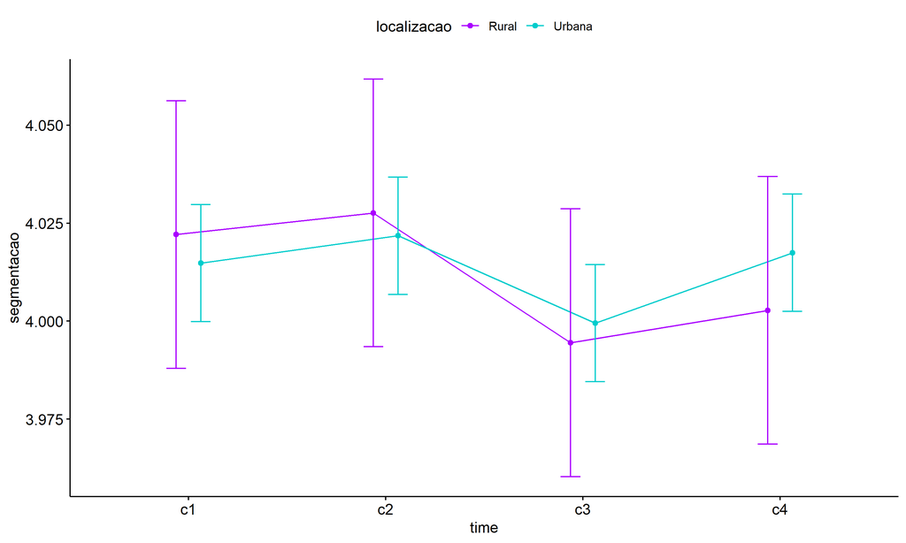

```r
pwc <- add_xy_position(pwc, x = "time", fun = "mean_se", dodge = 0.25)
pd <- position_dodge(width = 0.25)
ggline(emms, x = "time", y = "emmean", color = "localizacao",
       palette = c("#AA00FF","#00CCCC"),
       position = pd, ylab = "segmentacao") +
  geom_errorbar(aes(ymin = conf.low, ymax = conf.high, color = localizacao),
                position = pd, width = 0.2) +
  stat_pvalue_manual(pwc, hide.ns = T, tip.length = F, linetype = 1)
```

```r
(pwc <- ldat %>% group_by(localizacao) %>%
    emmeans_test(segmentacao ~ time, detailed = T, p.adjust.method = "bonferroni"))
```

```
## # A tibble: 12 × 15
##    localizacao term  .y.         group1 group2 null.value estimate     se    df conf.low conf.high
##  * <fct>       <chr> <chr>       <chr>  <chr>       <dbl>    <dbl>  <dbl> <dbl>    <dbl>     <dbl>
##  1 Rural       time  segmentacao c1     c2              0 -0.00552 0.0246  4496 -0.0538    0.0428
##  2 Rural       time  segmentacao c1     c3              0  0.0276  0.0246  4496 -0.0207    0.0759
##  3 Rural       time  segmentacao c1     c4              0  0.0193  0.0246  4496 -0.0290    0.0676
##  4 Rural       time  segmentacao c2     c3              0  0.0331  0.0246  4496 -0.0152    0.0815
##  5 Rural       time  segmentacao c2     c4              0  0.0249  0.0246  4496 -0.0234    0.0732
##  6 Rural       time  segmentacao c3     c4              0 -0.00829 0.0246  4496 -0.0566    0.0400
##  7 Urbana      time  segmentacao c1     c2              0 -0.00697 0.0108  4496 -0.0281    0.0142
##  8 Urbana      time  segmentacao c1     c3              0  0.0153  0.0108  4496 -0.00580   0.0365
##  9 Urbana      time  segmentacao c1     c4              0 -0.00265 0.0108  4496 -0.0238    0.0185
## 10 Urbana      time  segmentacao c2     c3              0  0.0223  0.0108  4496  0.00117   0.0435
## 11 Urbana      time  segmentacao c2     c4              0  0.00432 0.0108  4496 -0.0168    0.0255
## 12 Urbana      time  segmentacao c3     c4              0 -0.0180  0.0108  4496 -0.0391    0.00315
## # ℹ 4 more variables: statistic <dbl>, p <dbl>, p.adj <dbl>, p.adj.signif <chr>
```

| localizacao | term | .y. | group1 | group2 | null.value | estimate | se | df | conf.low | conf.high | statistic | p | p.adj | p.adj.signif |
| --- | --- | --- | --- | --- | --- | --- | --- | --- | --- | --- | --- | --- | --- | --- |
| Rural | time | segmentacao | c1 | c2 | 0 | -0.006 | 0.025 | 4496 | -0.054 | 0.043 | -0.224 | 0.823 | 1.000 | ns |
| Rural | time | segmentacao | c1 | c3 | 0 | 0.028 | 0.025 | 4496 | -0.021 | 0.076 | 1.121 | 0.262 | 1.000 | ns |
| Rural | time | segmentacao | c1 | c4 | 0 | 0.019 | 0.025 | 4496 | -0.029 | 0.068 | 0.785 | 0.433 | 1.000 | ns |
| Rural | time | segmentacao | c2 | c3 | 0 | 0.033 | 0.025 | 4496 | -0.015 | 0.081 | 1.345 | 0.179 | 1.000 | ns |
| Rural | time | segmentacao | c2 | c4 | 0 | 0.025 | 0.025 | 4496 | -0.023 | 0.073 | 1.009 | 0.313 | 1.000 | ns |
| Rural | time | segmentacao | c3 | c4 | 0 | -0.008 | 0.025 | 4496 | -0.057 | 0.040 | -0.336 | 0.737 | 1.000 | ns |
| Urbana | time | segmentacao | c1 | c2 | 0 | -0.007 | 0.011 | 4496 | -0.028 | 0.014 | -0.646 | 0.518 | 1.000 | ns |
| Urbana | time | segmentacao | c1 | c3 | 0 | 0.015 | 0.011 | 4496 | -0.006 | 0.036 | 1.423 | 0.155 | 0.929 | ns |
| Urbana | time | segmentacao | c1 | c4 | 0 | -0.003 | 0.011 | 4496 | -0.024 | 0.018 | -0.245 | 0.806 | 1.000 | ns |
| Urbana | time | segmentacao | c2 | c3 | 0 | 0.022 | 0.011 | 4496 | 0.001 | 0.043 | 2.069 | 0.039 | 0.232 | ns |
| Urbana | time | segmentacao | c2 | c4 | 0 | 0.004 | 0.011 | 4496 | -0.017 | 0.025 | 0.401 | 0.689 | 1.000 | ns |
| Urbana | time | segmentacao | c3 | c4 | 0 | -0.018 | 0.011 | 4496 | -0.039 | 0.003 | -1.668 | 0.095 | 0.572 | ns |

```r
(emms <- get_emmeans(pwc))
```

```
## # A tibble: 8 × 8
##   localizacao time  emmean      se    df conf.low conf.high method
##   <fct>       <fct>  <dbl>   <dbl> <dbl>    <dbl>     <dbl> <chr>
## 1 Rural       c1      4.02 0.0174   4496     3.99      4.06 Emmeans test
## 2 Rural       c2      4.03 0.0174   4496     3.99      4.06 Emmeans test
## 3 Rural       c3      3.99 0.0174   4496     3.96      4.03 Emmeans test
## 4 Rural       c4      4.00 0.0174   4496     3.97      4.04 Emmeans test
## 5 Urbana      c1      4.01 0.00763  4496     4.00      4.03 Emmeans test
## 6 Urbana      c2      4.02 0.00763  4496     4.01      4.04 Emmeans test
## 7 Urbana      c3      4.00 0.00763  4496     3.98      4.01 Emmeans test
## 8 Urbana      c4      4.02 0.00763  4496     4.00      4.03 Emmeans test
```

| localizacao | time | emmean | se | df | conf.low | conf.high | method |
| --- | --- | --- | --- | --- | --- | --- | --- |
| Rural | c1 | 4.022 | 0.017 | 4496 | 3.988 | 4.056 | Emmeans test |
| Rural | c2 | 4.028 | 0.017 | 4496 | 3.993 | 4.062 | Emmeans test |
| Rural | c3 | 3.994 | 0.017 | 4496 | 3.960 | 4.029 | Emmeans test |
| Rural | c4 | 4.003 | 0.017 | 4496 | 3.969 | 4.037 | Emmeans test |
| Urbana | c1 | 4.015 | 0.008 | 4496 | 4.000 | 4.030 | Emmeans test |
| Urbana | c2 | 4.022 | 0.008 | 4496 | 4.007 | 4.037 | Emmeans test |
| Urbana | c3 | 3.999 | 0.008 | 4496 | 3.985 | 4.014 | Emmeans test |
| Urbana | c4 | 4.017 | 0.008 | 4496 | 4.003 | 4.032 | Emmeans test |

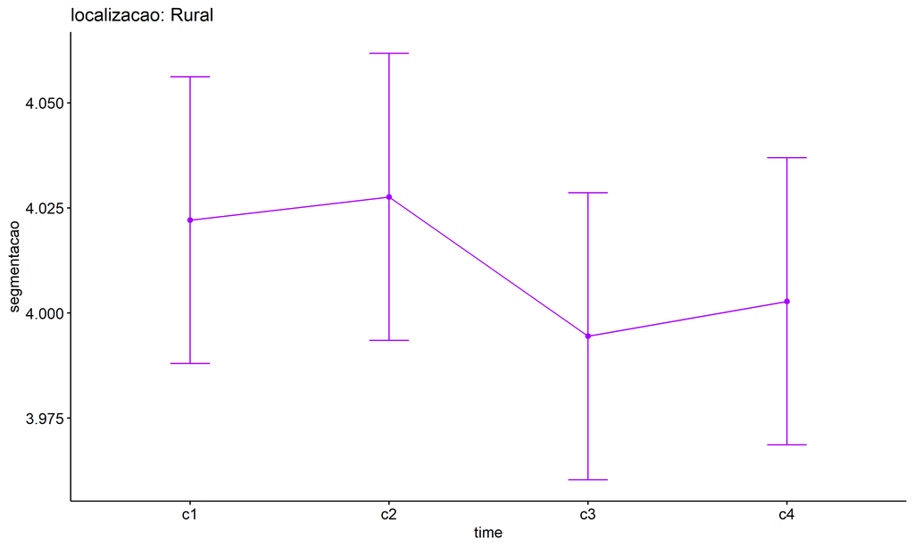

```r
emms.gg <- emms[which(emms$localizacao == "Rural"),]
if (nrow(emms.gg) > 0)
  ggline(emms.gg, x = "time", y = "emmean", color = "#AA00FF", ylab = "segmentacao") +
    geom_errorbar(aes(ymin = conf.low, ymax = conf.high),
                  width = 0.2, color = "#AA00FF") +
    stat_pvalue_manual(
      add_xy_position(pwc[which(pwc$localizacao == "Rural"),],
                      x = "time", fun = "mean_se"),
      hide.ns = T, color = "#AA00FF", tip.length = F) +
    labs(title = "localizacao: Rural")+
    theme(legend.text = element_blank())
```

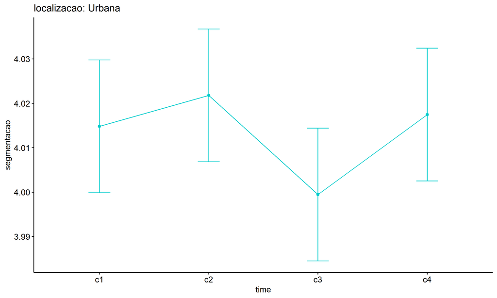

```r
emms.gg <- emms[which(emms$localizacao == "Urbana"),]
if (nrow(emms.gg) > 0)
  ggline(emms.gg, x = "time", y = "emmean", color = "#00CCCC", ylab = "segmentacao") +
    geom_errorbar(aes(ymin = conf.low, ymax = conf.high),
                  width = 0.2, color = "#00CCCC") +
    stat_pvalue_manual(
      add_xy_position(pwc[which(pwc$localizacao == "Urbana"),],
                      x = "time", fun = "mean_se"),
      hide.ns = T, color = "#00CCCC", tip.length = F) +
    labs(title = "localizacao: Urbana")+
    theme(legend.text = element_blank())
```

## PairWise Computation after removing non.normal data

```r
if (length(non.ids) > 0)
  (pwc2 <- ldat2 %>% group_by(time) %>%
     emmeans_test(segmentacao ~ localizacao, detailed = T, p.adjust.method = "bonferroni"))
```

```r
if (length(non.ids) > 0)
  (emms2 <- get_emmeans(pwc2))
```

```r
if (length(non.ids) > 0) {
  pwc2 <- add_xy_position(pwc2, x = "time", fun = "mean_se", dodge = 0.25)
  pd2 <- position_dodge(width = 0.25)

  ggline(emms2, x = "time", y = "emmean", color = "localizacao",
         palette = c("#AA00FF","#00CCCC"),
         position = pd, ylab = "segmentacao") +
    geom_errorbar(aes(ymin = conf.low, ymax = conf.high, color = localizacao),
                position = pd, width = 0.2) +
    stat_pvalue_manual(pwc2, hide.ns = T, tip.length = F, linetype = 1)
}
```

```r
if (length(non.ids) > 0)
  (pwc2 <- ldat2 %>% group_by(localizacao) %>%
     emmeans_test(segmentacao ~ time, detailed = T, p.adjust.method = "bonferroni"))
```

```r
if (length(non.ids) > 0)
  (emms2 <- get_emmeans(pwc2))
```

```r
if (length(non.ids) > 0) {
  emms.gg <- emms2[which(emms2$localizacao == "Rural"),]
  if (nrow(emms.gg) > 0)
    ggline(emms.gg, x = "time", y = "emmean", color = "#AA00FF", ylab = "segmentacao") +
    geom_errorbar(aes(ymin = conf.low, ymax = conf.high),
                  width = 0.2, color = "#AA00FF") +
    stat_pvalue_manual(
      add_xy_position(pwc[which(pwc$localizacao == "Rural"),],
                      x = "time", fun = "mean_se"),
      hide.ns = T, color = "#AA00FF", tip.length = F) +
    labs(title = "localizacao: Rural") +
    theme(legend.text = element_blank())
}
```

```r
if (length(non.ids) > 0) {
  emms.gg <- emms2[which(emms2$localizacao == "Urbana"),]
  if (nrow(emms.gg) > 0)
    ggline(emms.gg, x = "time", y = "emmean", color = "#00CCCC", ylab = "segmentacao") +
    geom_errorbar(aes(ymin = conf.low, ymax = conf.high),
                  width = 0.2, color = "#00CCCC") +
    stat_pvalue_manual(
      add_xy_position(pwc[which(pwc$localizacao == "Urbana"),],
                      x = "time", fun = "mean_se"),
      hide.ns = T, color = "#00CCCC", tip.length = F) +
    labs(title = "localizacao: Urbana") +
    theme(legend.text = element_blank())
}
```

# ANOVA: segmentacao ~ time*regiao + Error(id/time)

## Data Preparation

```r
data <- edat[,c("aluno_id","regiao","ciclo","segmentacao")]
data <- data[data$ciclo %in% c("Primeiro Ciclo","Segundo Ciclo","Terceiro Ciclo","Quarto Ciclo"),]
data$ciclo <- factor(data$ciclo, c("Primeiro Ciclo","Segundo Ciclo","Terceiro Ciclo","Quarto Ciclo"))
data <- unique(data)

wdat <- spread(data, ciclo, segmentacao)
wdat <- wdat[complete.cases(wdat),]
colnames(wdat) <- c("id","regiao","c1","c2","c3","c4")

ldat <- gather(wdat, key = time, value = segmentacao, c1,c2,c3,c4) %>%
  convert_as_factor(id, time)
ldat <- remove_group_data(ldat, "segmentacao", c("time", "regiao"), n.limit = 30)
ldat$regiao <- factor(ldat$regiao, sort(unique(ldat$regiao)))
```

### Check assumptions: Identifying Outliers

```r
outliers <- identify_outliers(group_by(ldat, time, regiao), segmentacao)
(outliers <- outliers[outliers$is.extreme == T,])
```

```
## # A tibble: 446 × 6
##    regiao       time  id                   segmentacao is.outlier is.extreme
##    <fct>        <fct> <fct>                      <dbl> <lgl>      <lgl>
##  1 Centro-Oeste c1    9jd1C85ixCoJf3EINYfx         5   TRUE       TRUE
##  2 Centro-Oeste c1    aOGxFSPrreKjHqmQIKKA         4.5 TRUE       TRUE
##  3 Centro-Oeste c1    atydp19vM0PjiOQCWemR         5   TRUE       TRUE
##  4 Centro-Oeste c1    LC1uBEBe3hZn8Q1mQe7A         4.5 TRUE       TRUE
##  5 Centro-Oeste c1    oB5KNHL8aUZyGZK3jNIP         4.5 TRUE       TRUE
##  6 Centro-Oeste c1    q1RelulkOweB4lCMWfxy         4.5 TRUE       TRUE
##  7 Centro-Oeste c1    TupwpKp0mSf2xCyx7nhJ         4.5 TRUE       TRUE
##  8 Centro-Oeste c1    wSTeItj2YyZhZQ0kiCqW         4.5 TRUE       TRUE
##  9 Centro-Oeste c1    ygFJxqySABX8ax57ihIq         4.5 TRUE       TRUE
## 10 Nordeste     c1    1Ao7d6oeWOGn5CkNSJxn         4.5 TRUE       TRUE
## # ℹ 436 more rows
```

| regiao | time | id | segmentacao | is.outlier | is.extreme |
| --- | --- | --- | --- | --- | --- |
| Centro-Oeste | c1 | 9jd1C85ixCoJf3EINYfx | 5.000 | TRUE | TRUE |
| Centro-Oeste | c1 | aOGxFSPrreKjHqmQIKKA | 4.500 | TRUE | TRUE |
| Centro-Oeste | c1 | atydp19vM0PjiOQCWemR | 5.000 | TRUE | TRUE |
| Centro-Oeste | c1 | LC1uBEBe3hZn8Q1mQe7A | 4.500 | TRUE | TRUE |
| Centro-Oeste | c1 | oB5KNHL8aUZyGZK3jNIP | 4.500 | TRUE | TRUE |
| Centro-Oeste | c1 | q1RelulkOweB4lCMWfxy | 4.500 | TRUE | TRUE |
| Centro-Oeste | c1 | TupwpKp0mSf2xCyx7nhJ | 4.500 | TRUE | TRUE |
| Centro-Oeste | c1 | wSTeItj2YyZhZQ0kiCqW | 4.500 | TRUE | TRUE |
| Centro-Oeste | c1 | ygFJxqySABX8ax57ihIq | 4.500 | TRUE | TRUE |
| Nordeste | c1 | 1Ao7d6oeWOGn5CkNSJxn | 4.500 | TRUE | TRUE |
| Nordeste | c1 | 1rGKIQ7fdZBOxxGdPFrp | 5.000 | TRUE | TRUE |
| Nordeste | c1 | 2qbgEyCWhU8ChVoKwmf5 | 5.000 | TRUE | TRUE |
| Nordeste | c1 | 2wBgWJVF1mK6rnsBiZ99 | 3.000 | TRUE | TRUE |
| Nordeste | c1 | 4tC0rHbjrsSU8gnHaaJ3 | 3.500 | TRUE | TRUE |
| Nordeste | c1 | 53lsfK6za4noVZe68et6 | 3.000 | TRUE | TRUE |
| Nordeste | c1 | 5WOchSZgUhx0OWTzb7cj | 3.000 | TRUE | TRUE |
| Nordeste | c1 | 7AsCrRYMyhVRQHX4kZdc | 3.000 | TRUE | TRUE |
| Nordeste | c1 | ao9Hy7cVw5W6MXhO5Ylm | 3.500 | TRUE | TRUE |
| Nordeste | c1 | aT7LCUsqZ1GEFzMoTQbc | 5.000 | TRUE | TRUE |
| Nordeste | c1 | CquTenVuBSFELLzcDuZm | 5.000 | TRUE | TRUE |
| Nordeste | c1 | CRe8TWnc28z2KudiaQpG | 4.500 | TRUE | TRUE |
| Nordeste | c1 | cuknOzzwN4oCRum5U5ph | 3.500 | TRUE | TRUE |
| Nordeste | c1 | cWhCU9PZ3Uh5Q4Rfe7h1 | 3.500 | TRUE | TRUE |
| Nordeste | c1 | D3zCmRj97N1xSw2RGyIX | 4.500 | TRUE | TRUE |
| Nordeste | c1 | dexrClGilncb86c5HWYP | 3.500 | TRUE | TRUE |
| Nordeste | c1 | e01kWx8LyQ5MBbqcIbXn | 5.000 | TRUE | TRUE |
| Nordeste | c1 | eJDGpLsooEaszwDWmzb7 | 5.000 | TRUE | TRUE |
| Nordeste | c1 | EMQCYuwE2sju5dZtKiOn | 3.000 | TRUE | TRUE |
| Nordeste | c1 | EXP9vzjLIJFDlyiQt1hn | 3.000 | TRUE | TRUE |
| Nordeste | c1 | fETGhIde8enSW1EPqWMS | 3.000 | TRUE | TRUE |

[output cut: 416 more lines]

### Check assumptions: Normality Test

```r
(normality.df <- normality.test.per.groups(ldat, "segmentacao", c("time", "regiao")))
```

```
##            var    variable time       regiao   n    skewness  kurtosis symmetry   statistic
## 1  segmentacao segmentacao   c1 Centro-Oeste  48  0.00000000  0.000000 few data          NA
## 2  segmentacao segmentacao   c1     Nordeste 545  0.61333781  7.667983       NO 122.0065996
## 3  segmentacao segmentacao   c1        Norte  78 -0.49498517  3.123314       NO  14.9956401
## 4  segmentacao segmentacao   c1      Sudeste 393 -0.46984330  6.903456       NO  78.4103607
## 5  segmentacao segmentacao   c1          Sul  62  1.47200348 10.110293       NO  41.6119255
## 6  segmentacao segmentacao   c2 Centro-Oeste  48 -3.47028011 13.782854       NO   0.3513151
## 7  segmentacao segmentacao   c2     Nordeste 545  1.21242379 10.083174       NO 197.0649245
## 8  segmentacao segmentacao   c2        Norte  78  1.37262109  6.862316       NO  39.9601250
## 9  segmentacao segmentacao   c2      Sudeste 393 -0.08212822 11.098143       NO  86.5451063
## 10 segmentacao segmentacao   c2          Sul  62 -5.42432204 32.496432       NO 110.0656686
## 11 segmentacao segmentacao   c3 Centro-Oeste  48  0.00000000  0.000000 few data          NA
## 12 segmentacao segmentacao   c3     Nordeste 545  0.58055837 17.583116       NO 170.1656449
## 13 segmentacao segmentacao   c3        Norte  78  1.33010145 16.240227       NO  52.3073281
## 14 segmentacao segmentacao   c3      Sudeste 393 -2.21984692 13.467655       NO 234.0167022
```

[output cut: 27 more lines]

| var | variable | time | regiao | n | skewness | kurtosis | symmetry | statistic | method | p | p.signif | normality |
| --- | --- | --- | --- | --- | --- | --- | --- | --- | --- | --- | --- | --- |
| segmentacao | segmentacao | c1 | Centro-Oeste | 48 | 0.000 | 0.000 | few data | NA | NA | 1.000 | NA | NO |
| segmentacao | segmentacao | c1 | Nordeste | 545 | 0.613 | 7.668 | NO | 122.007 | D’Agostino | 0.000 | **** | - |
| segmentacao | segmentacao | c1 | Norte | 78 | -0.495 | 3.123 | NO | 14.996 | D’Agostino | 0.001 | *** | NO |
| segmentacao | segmentacao | c1 | Sudeste | 393 | -0.470 | 6.903 | NO | 78.410 | D’Agostino | 0.000 | **** | - |
| segmentacao | segmentacao | c1 | Sul | 62 | 1.472 | 10.110 | NO | 41.612 | D’Agostino | 0.000 | **** | NO |
| segmentacao | segmentacao | c2 | Centro-Oeste | 48 | -3.470 | 13.783 | NO | 0.351 | Shapiro-Wilk | 0.000 | **** | NO |
| segmentacao | segmentacao | c2 | Nordeste | 545 | 1.212 | 10.083 | NO | 197.065 | D’Agostino | 0.000 | **** | - |
| segmentacao | segmentacao | c2 | Norte | 78 | 1.373 | 6.862 | NO | 39.960 | D’Agostino | 0.000 | **** | NO |
| segmentacao | segmentacao | c2 | Sudeste | 393 | -0.082 | 11.098 | NO | 86.545 | D’Agostino | 0.000 | **** | - |
| segmentacao | segmentacao | c2 | Sul | 62 | -5.424 | 32.496 | NO | 110.066 | D’Agostino | 0.000 | **** | NO |
| segmentacao | segmentacao | c3 | Centro-Oeste | 48 | 0.000 | 0.000 | few data | NA | NA | 1.000 | NA | NO |
| segmentacao | segmentacao | c3 | Nordeste | 545 | 0.581 | 17.583 | NO | 170.166 | D’Agostino | 0.000 | **** | - |
| segmentacao | segmentacao | c3 | Norte | 78 | 1.330 | 16.240 | NO | 52.307 | D’Agostino | 0.000 | **** | NO |
| segmentacao | segmentacao | c3 | Sudeste | 393 | -2.220 | 13.468 | NO | 234.017 | D’Agostino | 0.000 | **** | - |
| segmentacao | segmentacao | c3 | Sul | 62 | 0.000 | 0.000 | few data | NA | NA | 1.000 | NA | NO |
| segmentacao | segmentacao | c4 | Centro-Oeste | 48 | 0.851 | 4.555 | NO | 0.562 | Shapiro-Wilk | 0.000 | **** | NO |
| segmentacao | segmentacao | c4 | Nordeste | 545 | 1.406 | 11.865 | NO | 227.057 | D’Agostino | 0.000 | **** | - |
| segmentacao | segmentacao | c4 | Norte | 78 | -0.711 | 12.681 | NO | 37.119 | D’Agostino | 0.000 | **** | NO |
| segmentacao | segmentacao | c4 | Sudeste | 393 | -2.533 | 22.880 | NO | 280.053 | D’Agostino | 0.000 | **** | - |
| segmentacao | segmentacao | c4 | Sul | 62 | 0.000 | 0.000 | few data | NA | NA | 1.000 | NA | NO |

```r
(non.ids <- unique(do.call(
  c, lapply(which(normality.df$normality == 'NO'), FUN = function(i) {
  idx = which(ldat$time == normality.df$time[i] &
                ldat$regiao == normality.df$regiao[i])
  getNonNormal(ldat$"segmentacao"[idx], ldat$id[idx])
}))))
```

```
##  [1] "bOhetFcZCcckN4VKJMtL" "goC0bbJnYpzgY6ol6rsz" "Ho6XhD21vYcP3f3cT4x5" "K34anZEBbiYHYRSBkUK2"
##  [5] "LENIWLSSDEOzE5PXnvXp" "y5L9fA08vmo684jURWry" "nzSi9kSv8tyksM7sR4WD" "ojZafSSNhdquBdGe5nyl"
##  [9] "x3Xw8snMHFPilY4HCQUJ" "m5AeVuITWa7uCAG6h1Qh" "3fTmP8cTTJq8WUIEU0Xl" "WCSObSsiS3xWwGKtJ3Wu"
## [13] "84eMLEkOxEAhysQoqAVy" "3Ugm6wd42djxxIa9v8nX" "5MJshP0kp19vpSf9kCw1" "66k1mgdisI5m2S7kJsyb"
## [17] "zkW6c2m0BkbGXx8JpERU" "KgqoDcMNgZGVvBJkoiie" "lpeOVPtPO4XZ29YrnWY7" "dKIqav6TRc1lClMWW6hS"
## [21] "KPMkDhksSiEWVEIUT1LG" "QasU7a9JiIu1XHAPVJk9" "6G6n552emVnSHTVpUDh7" "p60GU5cf9uaftl79CXwQ"
```

```r
if (length(non.ids) > 0)
  ldat2 <- ldat[!ldat$id %in% non.ids,]
```

### Summary Statistics

```r
(sdat <- ldat %>% group_by(time, regiao) %>%
   get_summary_stats(segmentacao, type = "mean_sd"))
```

```
## # A tibble: 20 × 6
##    regiao       time  variable        n  mean    sd
##    <fct>        <fct> <fct>       <dbl> <dbl> <dbl>
##  1 Centro-Oeste c1    segmentacao    48  4.12 0.258
##  2 Nordeste     c1    segmentacao   545  4.03 0.277
##  3 Norte        c1    segmentacao    78  3.98 0.373
##  4 Sudeste      c1    segmentacao   393  3.98 0.29
##  5 Sul          c1    segmentacao    62  4.04 0.261
##  6 Centro-Oeste c2    segmentacao    48  3.98 0.219
##  7 Nordeste     c2    segmentacao   545  4.04 0.244
##  8 Norte        c2    segmentacao    78  4.06 0.279
##  9 Sudeste      c2    segmentacao   393  4.01 0.234
## 10 Sul          c2    segmentacao    62  3.98 0.145
## 11 Centro-Oeste c3    segmentacao    48  4.01 0.163
## 12 Nordeste     c3    segmentacao   545  4.01 0.193
## 13 Norte        c3    segmentacao    78  4.03 0.212
## 14 Sudeste      c3    segmentacao   393  3.98 0.202
## 15 Sul          c3    segmentacao    62  4    0.091
## 16 Centro-Oeste c4    segmentacao    48  4.04 0.323
## 17 Nordeste     c4    segmentacao   545  4.03 0.223
## 18 Norte        c4    segmentacao    78  4.01 0.228
## 19 Sudeste      c4    segmentacao   393  3.99 0.171
## 20 Sul          c4    segmentacao    62  4    0
```

| regiao | time | variable | n | mean | sd |
| --- | --- | --- | --- | --- | --- |
| Centro-Oeste | c1 | segmentacao | 48 | 4.115 | 0.258 |
| Nordeste | c1 | segmentacao | 545 | 4.032 | 0.277 |
| Norte | c1 | segmentacao | 78 | 3.981 | 0.373 |
| Sudeste | c1 | segmentacao | 393 | 3.985 | 0.290 |
| Sul | c1 | segmentacao | 62 | 4.040 | 0.261 |
| Centro-Oeste | c2 | segmentacao | 48 | 3.977 | 0.219 |
| Nordeste | c2 | segmentacao | 545 | 4.038 | 0.244 |
| Norte | c2 | segmentacao | 78 | 4.058 | 0.279 |
| Sudeste | c2 | segmentacao | 393 | 4.007 | 0.234 |
| Sul | c2 | segmentacao | 62 | 3.980 | 0.145 |
| Centro-Oeste | c3 | segmentacao | 48 | 4.010 | 0.163 |
| Nordeste | c3 | segmentacao | 545 | 4.010 | 0.193 |
| Norte | c3 | segmentacao | 78 | 4.026 | 0.212 |
| Sudeste | c3 | segmentacao | 393 | 3.976 | 0.202 |
| Sul | c3 | segmentacao | 62 | 4.000 | 0.091 |
| Centro-Oeste | c4 | segmentacao | 48 | 4.042 | 0.323 |
| Nordeste | c4 | segmentacao | 545 | 4.031 | 0.223 |
| Norte | c4 | segmentacao | 78 | 4.013 | 0.228 |
| Sudeste | c4 | segmentacao | 393 | 3.992 | 0.171 |
| Sul | c4 | segmentacao | 62 | 4.000 | 0.000 |

```r
if (length(non.ids) > 0)
  (sdat <- ldat2 %>% group_by(time, regiao) %>%
      get_summary_stats(segmentacao, type = "mean_sd"))
```

```
## # A tibble: 20 × 6
##    regiao       time  variable        n  mean    sd
##    <fct>        <fct> <fct>       <dbl> <dbl> <dbl>
##  1 Centro-Oeste c1    segmentacao    42  4.13 0.272
##  2 Nordeste     c1    segmentacao   545  4.03 0.277
##  3 Norte        c1    segmentacao    62  4.02 0.156
##  4 Sudeste      c1    segmentacao   393  3.98 0.29
##  5 Sul          c1    segmentacao    60  4.06 0.227
##  6 Centro-Oeste c2    segmentacao    42  4.02 0.08
##  7 Nordeste     c2    segmentacao   545  4.04 0.244
##  8 Norte        c2    segmentacao    62  4.02 0.141
##  9 Sudeste      c2    segmentacao   393  4.01 0.234
## 10 Sul          c2    segmentacao    60  4.00 0.073
## 11 Centro-Oeste c3    segmentacao    42  4.01 0.174
## 12 Nordeste     c3    segmentacao   545  4.01 0.193
## 13 Norte        c3    segmentacao    62  4.03 0.153
## 14 Sudeste      c3    segmentacao   393  3.98 0.202
## 15 Sul          c3    segmentacao    60  4    0.092
## 16 Centro-Oeste c4    segmentacao    42  4    0.156
## 17 Nordeste     c4    segmentacao   545  4.03 0.223
## 18 Norte        c4    segmentacao    62  4.05 0.174
## 19 Sudeste      c4    segmentacao   393  3.99 0.171
## 20 Sul          c4    segmentacao    60  4    0
```

| regiao | time | variable | n | mean | sd |
| --- | --- | --- | --- | --- | --- |
| Centro-Oeste | c1 | segmentacao | 42 | 4.131 | 0.272 |
| Nordeste | c1 | segmentacao | 545 | 4.032 | 0.277 |
| Norte | c1 | segmentacao | 62 | 4.016 | 0.156 |
| Sudeste | c1 | segmentacao | 393 | 3.985 | 0.290 |
| Sul | c1 | segmentacao | 60 | 4.058 | 0.227 |
| Centro-Oeste | c2 | segmentacao | 42 | 4.022 | 0.080 |
| Nordeste | c2 | segmentacao | 545 | 4.038 | 0.244 |
| Norte | c2 | segmentacao | 62 | 4.024 | 0.141 |
| Sudeste | c2 | segmentacao | 393 | 4.007 | 0.234 |
| Sul | c2 | segmentacao | 60 | 3.996 | 0.073 |
| Centro-Oeste | c3 | segmentacao | 42 | 4.012 | 0.174 |
| Nordeste | c3 | segmentacao | 545 | 4.010 | 0.193 |
| Norte | c3 | segmentacao | 62 | 4.032 | 0.153 |
| Sudeste | c3 | segmentacao | 393 | 3.976 | 0.202 |
| Sul | c3 | segmentacao | 60 | 4.000 | 0.092 |
| Centro-Oeste | c4 | segmentacao | 42 | 4.000 | 0.156 |
| Nordeste | c4 | segmentacao | 545 | 4.031 | 0.223 |
| Norte | c4 | segmentacao | 62 | 4.048 | 0.174 |
| Sudeste | c4 | segmentacao | 393 | 3.992 | 0.171 |
| Sul | c4 | segmentacao | 60 | 4.000 | 0.000 |

## ANOVA Computation

```r
(res.aov <- anova_test(ldat, dv = segmentacao, wid = id, between = regiao, within = time))
```

```
## ANOVA Table (type III tests)
##
## $ANOVA
##        Effect DFn  DFd     F         p p<.05     ges
## 1      regiao   4 1121 6.026 0.0000849     * 0.00600
## 2        time   3 3363 1.049 0.3700000       0.00068
## 3 regiao:time  12 3363 1.493 0.1190000       0.00400
##
## $`Mauchly's Test for Sphericity`
##        Effect     W                            p p<.05
## 1        time 0.897 0.00000000000000000000000152     *
## 2 regiao:time 0.897 0.00000000000000000000000152     *
##
## $`Sphericity Corrections`
##        Effect   GGe         DF[GG] p[GG] p[GG]<.05   HFe         DF[HF] p[HF] p[HF]<.05
## 1        time 0.932   2.8, 3133.93 0.367           0.934   2.8, 3142.56 0.367
## 2 regiao:time 0.932 11.18, 3133.93 0.125           0.934 11.21, 3142.56 0.125
```

| Effect | DFn | DFd | F | p | p<.05 | ges |
| --- | --- | --- | --- | --- | --- | --- |
| regiao | 4 | 1121 | 6.026 | 0.000 | * | 0.006 |
| time | 3 | 3363 | 1.049 | 0.370 |  | 0.001 |
| regiao:time | 12 | 3363 | 1.493 | 0.119 |  | 0.004 |

| Effect | W | p | p<.05 |
| --- | --- | --- | --- |
| time | 0.897 | 0 | * |
| regiao:time | 0.897 | 0 | * |

| Effect | GGe | DF[GG] | p[GG] | p[GG]<.05 | HFe | DF[HF] | p[HF] | p[HF]<.05 |
| --- | --- | --- | --- | --- | --- | --- | --- | --- |
| time | 0.932 | 2.8, 3133.93 | 0.367 |  | 0.934 | 2.8, 3142.56 | 0.367 |  |
| regiao:time | 0.932 | 11.18, 3133.93 | 0.125 |  | 0.934 | 11.21, 3142.56 | 0.125 |  |

## ANOVA Computation after removing non.normal data

```r
if (length(non.ids) > 0)
  (res.aov2 <- anova_test(ldat2, dv = segmentacao, wid = id, between = regiao , within = time))
```

```
## ANOVA Table (type III tests)
##
## $ANOVA
##        Effect DFn  DFd     F         p p<.05   ges
## 1      regiao   4 1097 6.857 0.0000189     * 0.007
## 2        time   3 3291 2.361 0.0700000       0.002
## 3 regiao:time  12 3291 1.246 0.2450000       0.003
##
## $`Mauchly's Test for Sphericity`
##        Effect     W                          p p<.05
## 1        time 0.901 0.000000000000000000000057     *
## 2 regiao:time 0.901 0.000000000000000000000057     *
##
## $`Sphericity Corrections`
##        Effect   GGe        DF[GG] p[GG] p[GG]<.05   HFe         DF[HF] p[HF] p[HF]<.05
## 1        time 0.933  2.8, 3071.27 0.074           0.936  2.81, 3079.93 0.074
## 2 regiao:time 0.933 11.2, 3071.27 0.249           0.936 11.23, 3079.93 0.249
```

| Effect | DFn | DFd | F | p | p<.05 | ges |
| --- | --- | --- | --- | --- | --- | --- |
| regiao | 4 | 1097 | 6.857 | 0.000 | * | 0.007 |
| time | 3 | 3291 | 2.361 | 0.070 |  | 0.002 |
| regiao:time | 12 | 3291 | 1.246 | 0.245 |  | 0.003 |

| Effect | W | p | p<.05 |
| --- | --- | --- | --- |
| time | 0.901 | 0 | * |
| regiao:time | 0.901 | 0 | * |

| Effect | GGe | DF[GG] | p[GG] | p[GG]<.05 | HFe | DF[HF] | p[HF] | p[HF]<.05 |
| --- | --- | --- | --- | --- | --- | --- | --- | --- |
| time | 0.933 | 2.8, 3071.27 | 0.074 |  | 0.936 | 2.81, 3079.93 | 0.074 |  |
| regiao:time | 0.933 | 11.2, 3071.27 | 0.249 |  | 0.936 | 11.23, 3079.93 | 0.249 |  |

## PairWise Computation

```r
(pwc <- ldat %>% group_by(time) %>%
   emmeans_test(segmentacao ~ regiao, detailed = T, p.adjust.method = "bonferroni"))
```

| time | term | .y. | group1 | group2 | null.value | estimate | se | df | conf.low | conf.high | statistic | p | p.adj | p.adj.signif |
| --- | --- | --- | --- | --- | --- | --- | --- | --- | --- | --- | --- | --- | --- | --- |
| c1 | regiao | segmentacao | Centro | Oeste | 0 | 0.082 | 0.035 | 4484 | 0.014 | 0.151 | 2.345 | 0.019 | 0.191 | ns |
| c1 | regiao | segmentacao | Centro | Oeste | 0 | 0.134 | 0.043 | 4484 | 0.050 | 0.218 | 3.122 | 0.002 | 0.018 | * |
| c1 | regiao | segmentacao | Centro | Oeste | 0 | 0.130 | 0.036 | 4484 | 0.060 | 0.200 | 3.635 | 0.000 | 0.003 | ** |
| c1 | regiao | segmentacao | Centro | Oeste | 0 | 0.074 | 0.045 | 4484 | -0.014 | 0.162 | 1.653 | 0.098 | 0.983 | ns |
| c1 | regiao | segmentacao | Nordeste | Norte | 0 | 0.051 | 0.028 | 4484 | -0.004 | 0.107 | 1.815 | 0.070 | 0.695 | ns |
| c1 | regiao | segmentacao | Nordeste | Sudeste | 0 | 0.047 | 0.015 | 4484 | 0.017 | 0.078 | 3.064 | 0.002 | 0.022 | * |
| c1 | regiao | segmentacao | Nordeste | Sul | 0 | -0.008 | 0.031 | 4484 | -0.070 | 0.053 | -0.262 | 0.793 | 1.000 | ns |
| c1 | regiao | segmentacao | Norte | Sudeste | 0 | -0.004 | 0.029 | 4484 | -0.061 | 0.053 | -0.137 | 0.891 | 1.000 | ns |
| c1 | regiao | segmentacao | Norte | Sul | 0 | -0.060 | 0.040 | 4484 | -0.137 | 0.018 | -1.498 | 0.134 | 1.000 | ns |
| c1 | regiao | segmentacao | Sudeste | Sul | 0 | -0.056 | 0.032 | 4484 | -0.118 | 0.007 | -1.741 | 0.082 | 0.817 | ns |
| c2 | regiao | segmentacao | Centro | Oeste | 0 | -0.060 | 0.035 | 4484 | -0.129 | 0.009 | -1.715 | 0.086 | 0.863 | ns |
| c2 | regiao | segmentacao | Centro | Oeste | 0 | -0.080 | 0.043 | 4484 | -0.164 | 0.004 | -1.873 | 0.061 | 0.612 | ns |
| c2 | regiao | segmentacao | Centro | Oeste | 0 | -0.030 | 0.036 | 4484 | -0.100 | 0.040 | -0.834 | 0.405 | 1.000 | ns |
| c2 | regiao | segmentacao | Centro | Oeste | 0 | -0.002 | 0.045 | 4484 | -0.090 | 0.086 | -0.054 | 0.957 | 1.000 | ns |
| c2 | regiao | segmentacao | Nordeste | Norte | 0 | -0.020 | 0.028 | 4484 | -0.075 | 0.036 | -0.705 | 0.481 | 1.000 | ns |
| c2 | regiao | segmentacao | Nordeste | Sudeste | 0 | 0.031 | 0.015 | 4484 | 0.000 | 0.061 | 1.977 | 0.048 | 0.482 | ns |
| c2 | regiao | segmentacao | Nordeste | Sul | 0 | 0.058 | 0.031 | 4484 | -0.003 | 0.119 | 1.850 | 0.064 | 0.644 | ns |
| c2 | regiao | segmentacao | Norte | Sudeste | 0 | 0.050 | 0.029 | 4484 | -0.006 | 0.107 | 1.743 | 0.081 | 0.814 | ns |
| c2 | regiao | segmentacao | Norte | Sul | 0 | 0.078 | 0.040 | 4484 | 0.000 | 0.156 | 1.959 | 0.050 | 0.502 | ns |
| c2 | regiao | segmentacao | Sudeste | Sul | 0 | 0.027 | 0.032 | 4484 | -0.035 | 0.090 | 0.857 | 0.391 | 1.000 | ns |
| c3 | regiao | segmentacao | Centro | Oeste | 0 | 0.000 | 0.035 | 4484 | -0.069 | 0.069 | 0.009 | 0.993 | 1.000 | ns |
| c3 | regiao | segmentacao | Centro | Oeste | 0 | -0.015 | 0.043 | 4484 | -0.099 | 0.069 | -0.355 | 0.722 | 1.000 | ns |
| c3 | regiao | segmentacao | Centro | Oeste | 0 | 0.035 | 0.036 | 4484 | -0.035 | 0.105 | 0.968 | 0.333 | 1.000 | ns |
| c3 | regiao | segmentacao | Centro | Oeste | 0 | 0.010 | 0.045 | 4484 | -0.078 | 0.098 | 0.232 | 0.817 | 1.000 | ns |
| c3 | regiao | segmentacao | Nordeste | Norte | 0 | -0.016 | 0.028 | 4484 | -0.071 | 0.040 | -0.550 | 0.582 | 1.000 | ns |
| c3 | regiao | segmentacao | Nordeste | Sudeste | 0 | 0.034 | 0.015 | 4484 | 0.004 | 0.065 | 2.216 | 0.027 | 0.267 | ns |
| c3 | regiao | segmentacao | Nordeste | Sul | 0 | 0.010 | 0.031 | 4484 | -0.051 | 0.071 | 0.322 | 0.747 | 1.000 | ns |
| c3 | regiao | segmentacao | Norte | Sudeste | 0 | 0.050 | 0.029 | 4484 | -0.007 | 0.107 | 1.720 | 0.085 | 0.855 | ns |
| c3 | regiao | segmentacao | Norte | Sul | 0 | 0.026 | 0.040 | 4484 | -0.052 | 0.104 | 0.645 | 0.519 | 1.000 | ns |
| c3 | regiao | segmentacao | Sudeste | Sul | 0 | -0.024 | 0.032 | 4484 | -0.087 | 0.038 | -0.757 | 0.449 | 1.000 | ns |
| c4 | regiao | segmentacao | Centro | Oeste | 0 | 0.010 | 0.035 | 4484 | -0.058 | 0.079 | 0.298 | 0.766 | 1.000 | ns |
| c4 | regiao | segmentacao | Centro | Oeste | 0 | 0.029 | 0.043 | 4484 | -0.055 | 0.113 | 0.673 | 0.501 | 1.000 | ns |
| c4 | regiao | segmentacao | Centro | Oeste | 0 | 0.049 | 0.036 | 4484 | -0.021 | 0.119 | 1.380 | 0.168 | 1.000 | ns |
| c4 | regiao | segmentacao | Centro | Oeste | 0 | 0.042 | 0.045 | 4484 | -0.046 | 0.130 | 0.928 | 0.354 | 1.000 | ns |
| c4 | regiao | segmentacao | Nordeste | Norte | 0 | 0.018 | 0.028 | 4484 | -0.037 | 0.074 | 0.650 | 0.516 | 1.000 | ns |
| c4 | regiao | segmentacao | Nordeste | Sudeste | 0 | 0.039 | 0.015 | 4484 | 0.009 | 0.069 | 2.511 | 0.012 | 0.121 | ns |
| c4 | regiao | segmentacao | Nordeste | Sul | 0 | 0.031 | 0.031 | 4484 | -0.030 | 0.093 | 0.996 | 0.319 | 1.000 | ns |
| c4 | regiao | segmentacao | Norte | Sudeste | 0 | 0.020 | 0.029 | 4484 | -0.036 | 0.077 | 0.706 | 0.480 | 1.000 | ns |
| c4 | regiao | segmentacao | Norte | Sul | 0 | 0.013 | 0.040 | 4484 | -0.065 | 0.091 | 0.323 | 0.747 | 1.000 | ns |
| c4 | regiao | segmentacao | Sudeste | Sul | 0 | -0.008 | 0.032 | 4484 | -0.070 | 0.055 | -0.239 | 0.811 | 1.000 | ns |

```r
(emms <- get_emmeans(pwc))
```

```
## # A tibble: 20 × 8
##    time  regiao       emmean     se    df conf.low conf.high method
##    <fct> <fct>         <dbl>  <dbl> <dbl>    <dbl>     <dbl> <chr>
##  1 c1    Centro-Oeste   4.11 0.0337  4484     4.05      4.18 Emmeans test
##  2 c1    Nordeste       4.03 0.0100  4484     4.01      4.05 Emmeans test
##  3 c1    Norte          3.98 0.0265  4484     3.93      4.03 Emmeans test
##  4 c1    Sudeste        3.98 0.0118  4484     3.96      4.01 Emmeans test
##  5 c1    Sul            4.04 0.0297  4484     3.98      4.10 Emmeans test
##  6 c2    Centro-Oeste   3.98 0.0337  4484     3.91      4.04 Emmeans test
##  7 c2    Nordeste       4.04 0.0100  4484     4.02      4.06 Emmeans test
##  8 c2    Norte          4.06 0.0265  4484     4.01      4.11 Emmeans test
##  9 c2    Sudeste        4.01 0.0118  4484     3.98      4.03 Emmeans test
## 10 c2    Sul            3.98 0.0297  4484     3.92      4.04 Emmeans test
## 11 c3    Centro-Oeste   4.01 0.0337  4484     3.94      4.08 Emmeans test
## 12 c3    Nordeste       4.01 0.0100  4484     3.99      4.03 Emmeans test
## 13 c3    Norte          4.03 0.0265  4484     3.97      4.08 Emmeans test
## 14 c3    Sudeste        3.98 0.0118  4484     3.95      4.00 Emmeans test
## 15 c3    Sul            4.00 0.0297  4484     3.94      4.06 Emmeans test
## 16 c4    Centro-Oeste   4.04 0.0337  4484     3.98      4.11 Emmeans test
## 17 c4    Nordeste       4.03 0.0100  4484     4.01      4.05 Emmeans test
## 18 c4    Norte          4.01 0.0265  4484     3.96      4.06 Emmeans test
## 19 c4    Sudeste        3.99 0.0118  4484     3.97      4.02 Emmeans test
## 20 c4    Sul            4.00 0.0297  4484     3.94      4.06 Emmeans test
```

| time | regiao | emmean | se | df | conf.low | conf.high | method |
| --- | --- | --- | --- | --- | --- | --- | --- |
| c1 | Centro-Oeste | 4.115 | 0.034 | 4484 | 4.048 | 4.181 | Emmeans test |
| c1 | Nordeste | 4.032 | 0.010 | 4484 | 4.012 | 4.052 | Emmeans test |
| c1 | Norte | 3.981 | 0.026 | 4484 | 3.929 | 4.033 | Emmeans test |
| c1 | Sudeste | 3.985 | 0.012 | 4484 | 3.962 | 4.008 | Emmeans test |
| c1 | Sul | 4.040 | 0.030 | 4484 | 3.982 | 4.098 | Emmeans test |
| c2 | Centro-Oeste | 3.977 | 0.034 | 4484 | 3.911 | 4.044 | Emmeans test |
| c2 | Nordeste | 4.038 | 0.010 | 4484 | 4.018 | 4.057 | Emmeans test |
| c2 | Norte | 4.058 | 0.026 | 4484 | 4.006 | 4.110 | Emmeans test |
| c2 | Sudeste | 4.007 | 0.012 | 4484 | 3.984 | 4.030 | Emmeans test |
| c2 | Sul | 3.980 | 0.030 | 4484 | 3.922 | 4.038 | Emmeans test |
| c3 | Centro-Oeste | 4.010 | 0.034 | 4484 | 3.944 | 4.077 | Emmeans test |
| c3 | Nordeste | 4.010 | 0.010 | 4484 | 3.990 | 4.030 | Emmeans test |
| c3 | Norte | 4.026 | 0.026 | 4484 | 3.974 | 4.078 | Emmeans test |
| c3 | Sudeste | 3.976 | 0.012 | 4484 | 3.953 | 3.999 | Emmeans test |
| c3 | Sul | 4.000 | 0.030 | 4484 | 3.942 | 4.058 | Emmeans test |
| c4 | Centro-Oeste | 4.042 | 0.034 | 4484 | 3.976 | 4.108 | Emmeans test |
| c4 | Nordeste | 4.031 | 0.010 | 4484 | 4.012 | 4.051 | Emmeans test |
| c4 | Norte | 4.013 | 0.026 | 4484 | 3.961 | 4.065 | Emmeans test |
| c4 | Sudeste | 3.992 | 0.012 | 4484 | 3.969 | 4.015 | Emmeans test |
| c4 | Sul | 4.000 | 0.030 | 4484 | 3.942 | 4.058 | Emmeans test |

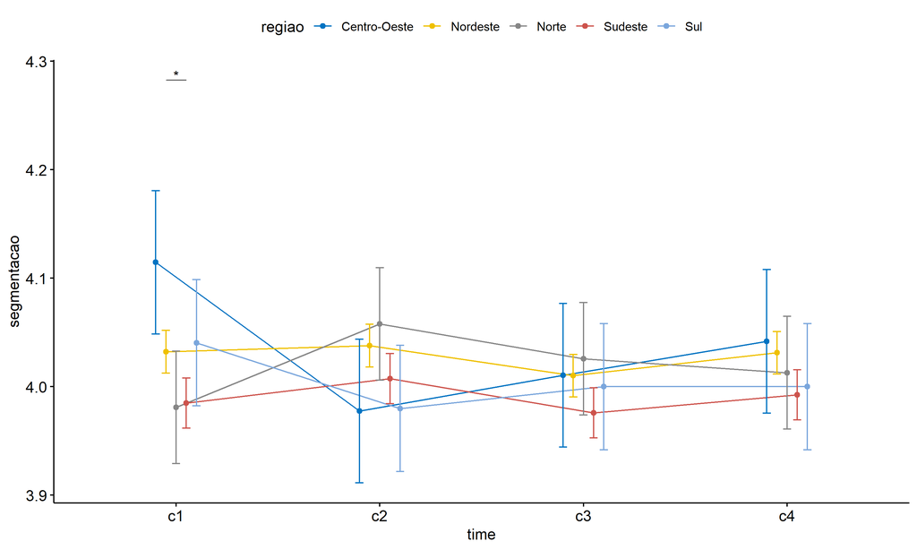

```r
pwc <- add_xy_position(pwc, x = "time", fun = "mean_se", dodge = 0.25)
pd <- position_dodge(width = 0.25)
ggline(emms, x = "time", y = "emmean", color = "regiao",
       palette = c("#0073C2FF","#EFC000FF","#868686FF","#CD534CFF","#7AA6DCFF"),
       position = pd, ylab = "segmentacao") +
  geom_errorbar(aes(ymin = conf.low, ymax = conf.high, color = regiao),
                position = pd, width = 0.2) +
  stat_pvalue_manual(pwc, hide.ns = T, tip.length = F, linetype = 1)
```

```r
(pwc <- ldat %>% group_by(regiao) %>%
    emmeans_test(segmentacao ~ time, detailed = T, p.adjust.method = "bonferroni"))
```

```
## # A tibble: 30 × 15
##    regiao     term  .y.   group1 group2 null.value estimate     se    df conf.low conf.high statistic
##  * <fct>      <chr> <chr> <chr>  <chr>       <dbl>    <dbl>  <dbl> <dbl>    <dbl>     <dbl>     <dbl>
##  1 Centro-Oe… time  segm… c1     c2              0  1.37e-1 0.0477  4484  4.37e-2    0.231     2.88
##  2 Centro-Oe… time  segm… c1     c3              0  1.04e-1 0.0477  4484  1.07e-2    0.198     2.18
##  3 Centro-Oe… time  segm… c1     c4              0  7.29e-2 0.0477  4484 -2.06e-2    0.166     1.53
##  4 Centro-Oe… time  segm… c2     c3              0 -3.30e-2 0.0477  4484 -1.26e-1    0.0605   -0.692
##  5 Centro-Oe… time  segm… c2     c4              0 -6.42e-2 0.0477  4484 -1.58e-1    0.0293   -1.35
##  6 Centro-Oe… time  segm… c3     c4              0 -3.13e-2 0.0477  4484 -1.25e-1    0.0622   -0.655
##  7 Nordeste   time  segm… c1     c2              0 -5.66e-3 0.0142  4484 -3.34e-2    0.0221   -0.400
##  8 Nordeste   time  segm… c1     c3              0  2.20e-2 0.0142  4484 -5.73e-3    0.0498    1.56
##  9 Nordeste   time  segm… c1     c4              0  9.17e-4 0.0142  4484 -2.68e-2    0.0287    0.0648
## 10 Nordeste   time  segm… c2     c3              0  2.77e-2 0.0142  4484 -6.98e-5    0.0554    1.96
## # ℹ 20 more rows
## # ℹ 3 more variables: p <dbl>, p.adj <dbl>, p.adj.signif <chr>
```

| regiao | term | .y. | group1 | group2 | null.value | estimate | se | df | conf.low | conf.high | statistic | p | p.adj | p.adj.signif |
| --- | --- | --- | --- | --- | --- | --- | --- | --- | --- | --- | --- | --- | --- | --- |
| Centro-Oeste | time | segmentacao | c1 | c2 | 0 | 0.137 | 0.048 | 4484 | 0.044 | 0.231 | 2.876 | 0.004 | 0.024 | * |
| Centro-Oeste | time | segmentacao | c1 | c3 | 0 | 0.104 | 0.048 | 4484 | 0.011 | 0.198 | 2.184 | 0.029 | 0.174 | ns |
| Centro-Oeste | time | segmentacao | c1 | c4 | 0 | 0.073 | 0.048 | 4484 | -0.021 | 0.166 | 1.529 | 0.126 | 0.758 | ns |
| Centro-Oeste | time | segmentacao | c2 | c3 | 0 | -0.033 | 0.048 | 4484 | -0.126 | 0.061 | -0.692 | 0.489 | 1.000 | ns |
| Centro-Oeste | time | segmentacao | c2 | c4 | 0 | -0.064 | 0.048 | 4484 | -0.158 | 0.029 | -1.347 | 0.178 | 1.000 | ns |
| Centro-Oeste | time | segmentacao | c3 | c4 | 0 | -0.031 | 0.048 | 4484 | -0.125 | 0.062 | -0.655 | 0.512 | 1.000 | ns |
| Nordeste | time | segmentacao | c1 | c2 | 0 | -0.006 | 0.014 | 4484 | -0.033 | 0.022 | -0.400 | 0.689 | 1.000 | ns |
| Nordeste | time | segmentacao | c1 | c3 | 0 | 0.022 | 0.014 | 4484 | -0.006 | 0.050 | 1.556 | 0.120 | 0.719 | ns |
| Nordeste | time | segmentacao | c1 | c4 | 0 | 0.001 | 0.014 | 4484 | -0.027 | 0.029 | 0.065 | 0.948 | 1.000 | ns |
| Nordeste | time | segmentacao | c2 | c3 | 0 | 0.028 | 0.014 | 4484 | 0.000 | 0.055 | 1.956 | 0.051 | 0.303 | ns |
| Nordeste | time | segmentacao | c2 | c4 | 0 | 0.007 | 0.014 | 4484 | -0.021 | 0.034 | 0.465 | 0.642 | 1.000 | ns |
| Nordeste | time | segmentacao | c3 | c4 | 0 | -0.021 | 0.014 | 4484 | -0.049 | 0.007 | -1.491 | 0.136 | 0.816 | ns |
| Norte | time | segmentacao | c1 | c2 | 0 | -0.077 | 0.037 | 4484 | -0.150 | -0.004 | -2.056 | 0.040 | 0.239 | ns |
| Norte | time | segmentacao | c1 | c3 | 0 | -0.045 | 0.037 | 4484 | -0.118 | 0.028 | -1.199 | 0.230 | 1.000 | ns |
| Norte | time | segmentacao | c1 | c4 | 0 | -0.032 | 0.037 | 4484 | -0.105 | 0.041 | -0.857 | 0.392 | 1.000 | ns |
| Norte | time | segmentacao | c2 | c3 | 0 | 0.032 | 0.037 | 4484 | -0.041 | 0.105 | 0.857 | 0.392 | 1.000 | ns |
| Norte | time | segmentacao | c2 | c4 | 0 | 0.045 | 0.037 | 4484 | -0.028 | 0.118 | 1.199 | 0.230 | 1.000 | ns |
| Norte | time | segmentacao | c3 | c4 | 0 | 0.013 | 0.037 | 4484 | -0.061 | 0.086 | 0.343 | 0.732 | 1.000 | ns |
| Sudeste | time | segmentacao | c1 | c2 | 0 | -0.022 | 0.017 | 4484 | -0.055 | 0.010 | -1.349 | 0.178 | 1.000 | ns |
| Sudeste | time | segmentacao | c1 | c3 | 0 | 0.009 | 0.017 | 4484 | -0.024 | 0.042 | 0.534 | 0.593 | 1.000 | ns |
| Sudeste | time | segmentacao | c1 | c4 | 0 | -0.008 | 0.017 | 4484 | -0.040 | 0.025 | -0.458 | 0.647 | 1.000 | ns |
| Sudeste | time | segmentacao | c2 | c3 | 0 | 0.031 | 0.017 | 4484 | -0.001 | 0.064 | 1.883 | 0.060 | 0.359 | ns |
| Sudeste | time | segmentacao | c2 | c4 | 0 | 0.015 | 0.017 | 4484 | -0.018 | 0.048 | 0.891 | 0.373 | 1.000 | ns |
| Sudeste | time | segmentacao | c3 | c4 | 0 | -0.017 | 0.017 | 4484 | -0.049 | 0.016 | -0.992 | 0.321 | 1.000 | ns |
| Sul | time | segmentacao | c1 | c2 | 0 | 0.060 | 0.042 | 4484 | -0.022 | 0.143 | 1.441 | 0.150 | 0.897 | ns |
| Sul | time | segmentacao | c1 | c3 | 0 | 0.040 | 0.042 | 4484 | -0.042 | 0.123 | 0.961 | 0.337 | 1.000 | ns |
| Sul | time | segmentacao | c1 | c4 | 0 | 0.040 | 0.042 | 4484 | -0.042 | 0.123 | 0.961 | 0.337 | 1.000 | ns |
| Sul | time | segmentacao | c2 | c3 | 0 | -0.020 | 0.042 | 4484 | -0.102 | 0.062 | -0.480 | 0.631 | 1.000 | ns |
| Sul | time | segmentacao | c2 | c4 | 0 | -0.020 | 0.042 | 4484 | -0.102 | 0.062 | -0.480 | 0.631 | 1.000 | ns |
| Sul | time | segmentacao | c3 | c4 | 0 | 0.000 | 0.042 | 4484 | -0.082 | 0.082 | 0.000 | 1.000 | 1.000 | ns |

```r
(emms <- get_emmeans(pwc))
```

```
## # A tibble: 20 × 8
##    regiao       time  emmean     se    df conf.low conf.high method
##    <fct>        <fct>  <dbl>  <dbl> <dbl>    <dbl>     <dbl> <chr>
##  1 Centro-Oeste c1      4.11 0.0337  4484     4.05      4.18 Emmeans test
##  2 Centro-Oeste c2      3.98 0.0337  4484     3.91      4.04 Emmeans test
##  3 Centro-Oeste c3      4.01 0.0337  4484     3.94      4.08 Emmeans test
##  4 Centro-Oeste c4      4.04 0.0337  4484     3.98      4.11 Emmeans test
##  5 Nordeste     c1      4.03 0.0100  4484     4.01      4.05 Emmeans test
##  6 Nordeste     c2      4.04 0.0100  4484     4.02      4.06 Emmeans test
##  7 Nordeste     c3      4.01 0.0100  4484     3.99      4.03 Emmeans test
##  8 Nordeste     c4      4.03 0.0100  4484     4.01      4.05 Emmeans test
##  9 Norte        c1      3.98 0.0265  4484     3.93      4.03 Emmeans test
## 10 Norte        c2      4.06 0.0265  4484     4.01      4.11 Emmeans test
## 11 Norte        c3      4.03 0.0265  4484     3.97      4.08 Emmeans test
## 12 Norte        c4      4.01 0.0265  4484     3.96      4.06 Emmeans test
## 13 Sudeste      c1      3.98 0.0118  4484     3.96      4.01 Emmeans test
## 14 Sudeste      c2      4.01 0.0118  4484     3.98      4.03 Emmeans test
## 15 Sudeste      c3      3.98 0.0118  4484     3.95      4.00 Emmeans test
## 16 Sudeste      c4      3.99 0.0118  4484     3.97      4.02 Emmeans test
## 17 Sul          c1      4.04 0.0297  4484     3.98      4.10 Emmeans test
## 18 Sul          c2      3.98 0.0297  4484     3.92      4.04 Emmeans test
## 19 Sul          c3      4.00 0.0297  4484     3.94      4.06 Emmeans test
## 20 Sul          c4      4.00 0.0297  4484     3.94      4.06 Emmeans test
```

| regiao | time | emmean | se | df | conf.low | conf.high | method |
| --- | --- | --- | --- | --- | --- | --- | --- |
| Centro-Oeste | c1 | 4.115 | 0.034 | 4484 | 4.048 | 4.181 | Emmeans test |
| Centro-Oeste | c2 | 3.977 | 0.034 | 4484 | 3.911 | 4.044 | Emmeans test |
| Centro-Oeste | c3 | 4.010 | 0.034 | 4484 | 3.944 | 4.077 | Emmeans test |
| Centro-Oeste | c4 | 4.042 | 0.034 | 4484 | 3.976 | 4.108 | Emmeans test |
| Nordeste | c1 | 4.032 | 0.010 | 4484 | 4.012 | 4.052 | Emmeans test |
| Nordeste | c2 | 4.038 | 0.010 | 4484 | 4.018 | 4.057 | Emmeans test |
| Nordeste | c3 | 4.010 | 0.010 | 4484 | 3.990 | 4.030 | Emmeans test |
| Nordeste | c4 | 4.031 | 0.010 | 4484 | 4.012 | 4.051 | Emmeans test |
| Norte | c1 | 3.981 | 0.026 | 4484 | 3.929 | 4.033 | Emmeans test |
| Norte | c2 | 4.058 | 0.026 | 4484 | 4.006 | 4.110 | Emmeans test |
| Norte | c3 | 4.026 | 0.026 | 4484 | 3.974 | 4.078 | Emmeans test |
| Norte | c4 | 4.013 | 0.026 | 4484 | 3.961 | 4.065 | Emmeans test |
| Sudeste | c1 | 3.985 | 0.012 | 4484 | 3.962 | 4.008 | Emmeans test |
| Sudeste | c2 | 4.007 | 0.012 | 4484 | 3.984 | 4.030 | Emmeans test |
| Sudeste | c3 | 3.976 | 0.012 | 4484 | 3.953 | 3.999 | Emmeans test |
| Sudeste | c4 | 3.992 | 0.012 | 4484 | 3.969 | 4.015 | Emmeans test |
| Sul | c1 | 4.040 | 0.030 | 4484 | 3.982 | 4.098 | Emmeans test |
| Sul | c2 | 3.980 | 0.030 | 4484 | 3.922 | 4.038 | Emmeans test |
| Sul | c3 | 4.000 | 0.030 | 4484 | 3.942 | 4.058 | Emmeans test |
| Sul | c4 | 4.000 | 0.030 | 4484 | 3.942 | 4.058 | Emmeans test |

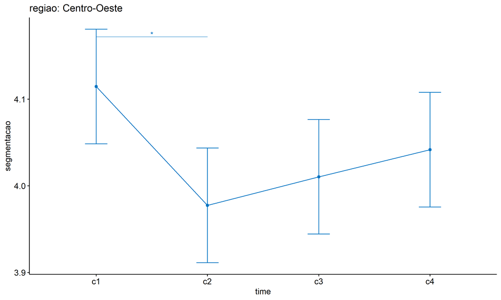

```r
emms.gg <- emms[which(emms$regiao == "Centro-Oeste"),]
if (nrow(emms.gg) > 0)
  ggline(emms.gg, x = "time", y = "emmean", color = "#0073C2FF", ylab = "segmentacao") +
    geom_errorbar(aes(ymin = conf.low, ymax = conf.high),
                  width = 0.2, color = "#0073C2FF") +
    stat_pvalue_manual(
      add_xy_position(pwc[which(pwc$regiao == "Centro-Oeste"),],
                      x = "time", fun = "mean_se"),
      hide.ns = T, color = "#0073C2FF", tip.length = F) +
    labs(title = "regiao: Centro-Oeste")+
    theme(legend.text = element_blank())
```

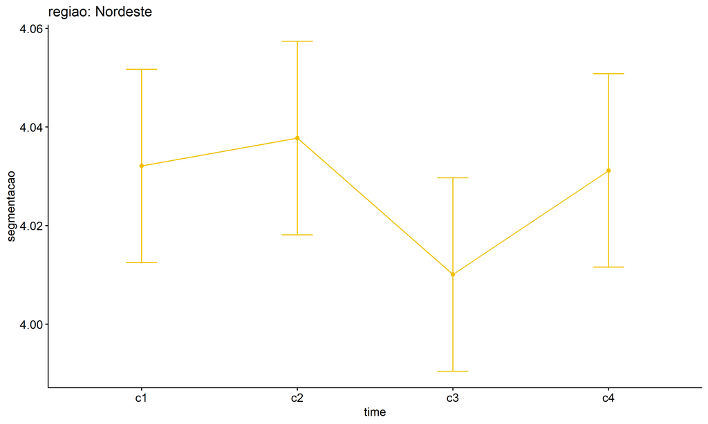

```r
emms.gg <- emms[which(emms$regiao == "Nordeste"),]
if (nrow(emms.gg) > 0)
  ggline(emms.gg, x = "time", y = "emmean", color = "#EFC000FF", ylab = "segmentacao") +
    geom_errorbar(aes(ymin = conf.low, ymax = conf.high),
                  width = 0.2, color = "#EFC000FF") +
    stat_pvalue_manual(
      add_xy_position(pwc[which(pwc$regiao == "Nordeste"),],
                      x = "time", fun = "mean_se"),
      hide.ns = T, color = "#EFC000FF", tip.length = F) +
    labs(title = "regiao: Nordeste")+
    theme(legend.text = element_blank())
```

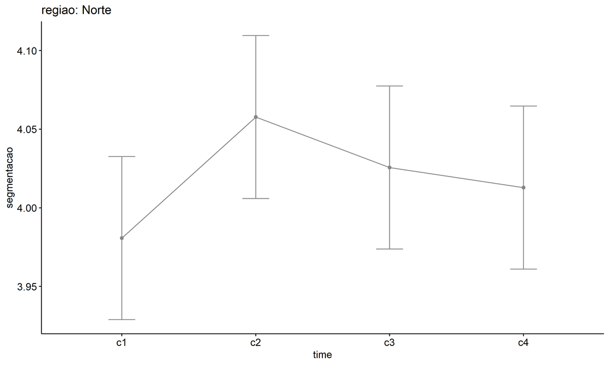

```r
emms.gg <- emms[which(emms$regiao == "Norte"),]
if (nrow(emms.gg) > 0)
  ggline(emms.gg, x = "time", y = "emmean", color = "#868686FF", ylab = "segmentacao") +
    geom_errorbar(aes(ymin = conf.low, ymax = conf.high),
                  width = 0.2, color = "#868686FF") +
    stat_pvalue_manual(
      add_xy_position(pwc[which(pwc$regiao == "Norte"),],
                      x = "time", fun = "mean_se"),
      hide.ns = T, color = "#868686FF", tip.length = F) +
    labs(title = "regiao: Norte")+
    theme(legend.text = element_blank())
```

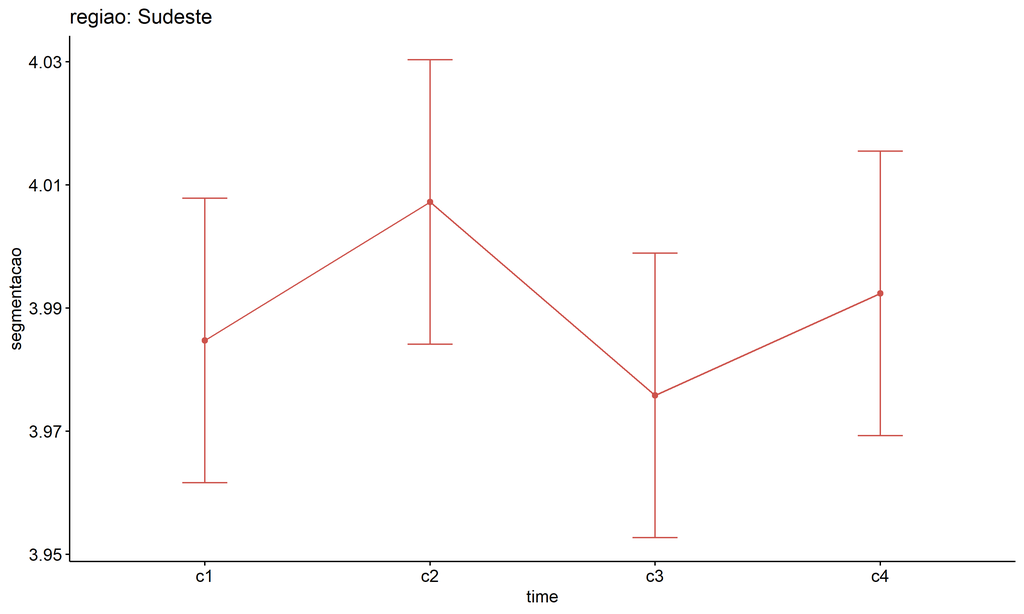

```r
emms.gg <- emms[which(emms$regiao == "Sudeste"),]
if (nrow(emms.gg) > 0)
  ggline(emms.gg, x = "time", y = "emmean", color = "#CD534CFF", ylab = "segmentacao") +
    geom_errorbar(aes(ymin = conf.low, ymax = conf.high),
                  width = 0.2, color = "#CD534CFF") +
    stat_pvalue_manual(
      add_xy_position(pwc[which(pwc$regiao == "Sudeste"),],
                      x = "time", fun = "mean_se"),
      hide.ns = T, color = "#CD534CFF", tip.length = F) +
    labs(title = "regiao: Sudeste")+
    theme(legend.text = element_blank())
```

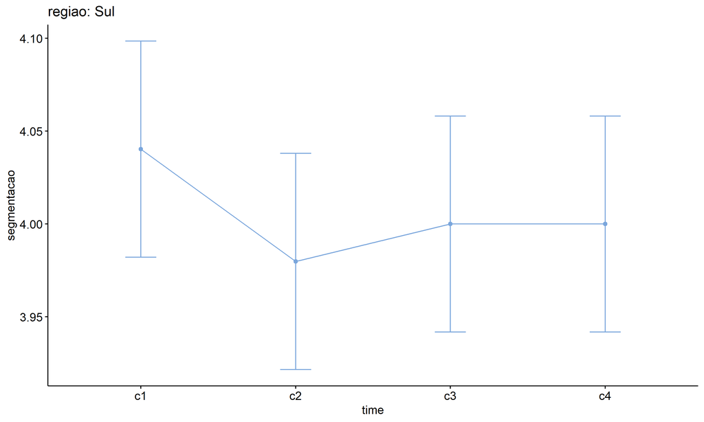

```r
emms.gg <- emms[which(emms$regiao == "Sul"),]
if (nrow(emms.gg) > 0)
  ggline(emms.gg, x = "time", y = "emmean", color = "#7AA6DCFF", ylab = "segmentacao") +
    geom_errorbar(aes(ymin = conf.low, ymax = conf.high),
                  width = 0.2, color = "#7AA6DCFF") +
    stat_pvalue_manual(
      add_xy_position(pwc[which(pwc$regiao == "Sul"),],
                      x = "time", fun = "mean_se"),
      hide.ns = T, color = "#7AA6DCFF", tip.length = F) +
    labs(title = "regiao: Sul")+
    theme(legend.text = element_blank())
```

## PairWise Computation after removing non.normal data

```r
if (length(non.ids) > 0)
  (pwc2 <- ldat2 %>% group_by(time) %>%
     emmeans_test(segmentacao ~ regiao, detailed = T, p.adjust.method = "bonferroni"))
```

| time | term | .y. | group1 | group2 | null.value | estimate | se | df | conf.low | conf.high | statistic | p | p.adj | p.adj.signif |
| --- | --- | --- | --- | --- | --- | --- | --- | --- | --- | --- | --- | --- | --- | --- |
| c1 | regiao | segmentacao | Centro | Oeste | 0 | 0.099 | 0.036 | 4388 | 0.029 | 0.169 | 2.766 | 0.006 | 0.057 | ns |
| c1 | regiao | segmentacao | Centro | Oeste | 0 | 0.115 | 0.045 | 4388 | 0.027 | 0.202 | 2.575 | 0.010 | 0.101 | ns |
| c1 | regiao | segmentacao | Centro | Oeste | 0 | 0.146 | 0.036 | 4388 | 0.075 | 0.217 | 4.036 | 0.000 | 0.001 | *** |
| c1 | regiao | segmentacao | Centro | Oeste | 0 | 0.073 | 0.045 | 4388 | -0.015 | 0.161 | 1.618 | 0.106 | 1.000 | ns |
| c1 | regiao | segmentacao | Nordeste | Norte | 0 | 0.016 | 0.030 | 4388 | -0.043 | 0.075 | 0.534 | 0.593 | 1.000 | ns |
| c1 | regiao | segmentacao | Nordeste | Sudeste | 0 | 0.047 | 0.015 | 4388 | 0.018 | 0.076 | 3.208 | 0.001 | 0.013 | * |
| c1 | regiao | segmentacao | Nordeste | Sul | 0 | -0.026 | 0.030 | 4388 | -0.086 | 0.033 | -0.864 | 0.388 | 1.000 | ns |
| c1 | regiao | segmentacao | Norte | Sudeste | 0 | 0.031 | 0.030 | 4388 | -0.028 | 0.091 | 1.030 | 0.303 | 1.000 | ns |
| c1 | regiao | segmentacao | Norte | Sul | 0 | -0.042 | 0.040 | 4388 | -0.121 | 0.037 | -1.044 | 0.296 | 1.000 | ns |
| c1 | regiao | segmentacao | Sudeste | Sul | 0 | -0.074 | 0.031 | 4388 | -0.134 | -0.013 | -2.380 | 0.017 | 0.174 | ns |
| c2 | regiao | segmentacao | Centro | Oeste | 0 | -0.016 | 0.036 | 4388 | -0.086 | 0.054 | -0.446 | 0.656 | 1.000 | ns |
| c2 | regiao | segmentacao | Centro | Oeste | 0 | -0.002 | 0.045 | 4388 | -0.090 | 0.085 | -0.053 | 0.958 | 1.000 | ns |
| c2 | regiao | segmentacao | Centro | Oeste | 0 | 0.015 | 0.036 | 4388 | -0.056 | 0.086 | 0.403 | 0.687 | 1.000 | ns |
| c2 | regiao | segmentacao | Centro | Oeste | 0 | 0.026 | 0.045 | 4388 | -0.062 | 0.114 | 0.579 | 0.563 | 1.000 | ns |
| c2 | regiao | segmentacao | Nordeste | Norte | 0 | 0.014 | 0.030 | 4388 | -0.045 | 0.072 | 0.454 | 0.650 | 1.000 | ns |
| c2 | regiao | segmentacao | Nordeste | Sudeste | 0 | 0.031 | 0.015 | 4388 | 0.002 | 0.060 | 2.069 | 0.039 | 0.386 | ns |
| c2 | regiao | segmentacao | Nordeste | Sul | 0 | 0.042 | 0.030 | 4388 | -0.018 | 0.101 | 1.382 | 0.167 | 1.000 | ns |
| c2 | regiao | segmentacao | Norte | Sudeste | 0 | 0.017 | 0.030 | 4388 | -0.043 | 0.077 | 0.557 | 0.578 | 1.000 | ns |
| c2 | regiao | segmentacao | Norte | Sul | 0 | 0.028 | 0.040 | 4388 | -0.051 | 0.108 | 0.702 | 0.483 | 1.000 | ns |
| c2 | regiao | segmentacao | Sudeste | Sul | 0 | 0.011 | 0.031 | 4388 | -0.049 | 0.072 | 0.368 | 0.713 | 1.000 | ns |
| c3 | regiao | segmentacao | Centro | Oeste | 0 | 0.002 | 0.036 | 4388 | -0.068 | 0.072 | 0.051 | 0.960 | 1.000 | ns |
| c3 | regiao | segmentacao | Centro | Oeste | 0 | -0.020 | 0.045 | 4388 | -0.108 | 0.067 | -0.456 | 0.648 | 1.000 | ns |
| c3 | regiao | segmentacao | Centro | Oeste | 0 | 0.036 | 0.036 | 4388 | -0.035 | 0.107 | 0.996 | 0.319 | 1.000 | ns |
| c3 | regiao | segmentacao | Centro | Oeste | 0 | 0.012 | 0.045 | 4388 | -0.076 | 0.100 | 0.265 | 0.791 | 1.000 | ns |
| c3 | regiao | segmentacao | Nordeste | Norte | 0 | -0.022 | 0.030 | 4388 | -0.081 | 0.036 | -0.741 | 0.459 | 1.000 | ns |
| c3 | regiao | segmentacao | Nordeste | Sudeste | 0 | 0.034 | 0.015 | 4388 | 0.005 | 0.063 | 2.320 | 0.020 | 0.204 | ns |
| c3 | regiao | segmentacao | Nordeste | Sul | 0 | 0.010 | 0.030 | 4388 | -0.049 | 0.070 | 0.332 | 0.740 | 1.000 | ns |
| c3 | regiao | segmentacao | Norte | Sudeste | 0 | 0.056 | 0.030 | 4388 | -0.003 | 0.116 | 1.851 | 0.064 | 0.643 | ns |
| c3 | regiao | segmentacao | Norte | Sul | 0 | 0.032 | 0.040 | 4388 | -0.047 | 0.111 | 0.798 | 0.425 | 1.000 | ns |
| c3 | regiao | segmentacao | Sudeste | Sul | 0 | -0.024 | 0.031 | 4388 | -0.085 | 0.036 | -0.782 | 0.435 | 1.000 | ns |
| c4 | regiao | segmentacao | Centro | Oeste | 0 | -0.031 | 0.036 | 4388 | -0.101 | 0.039 | -0.873 | 0.383 | 1.000 | ns |
| c4 | regiao | segmentacao | Centro | Oeste | 0 | -0.048 | 0.045 | 4388 | -0.136 | 0.039 | -1.085 | 0.278 | 1.000 | ns |
| c4 | regiao | segmentacao | Centro | Oeste | 0 | 0.008 | 0.036 | 4388 | -0.063 | 0.079 | 0.211 | 0.833 | 1.000 | ns |
| c4 | regiao | segmentacao | Centro | Oeste | 0 | 0.000 | 0.045 | 4388 | -0.088 | 0.088 | 0.000 | 1.000 | 1.000 | ns |
| c4 | regiao | segmentacao | Nordeste | Norte | 0 | -0.017 | 0.030 | 4388 | -0.076 | 0.041 | -0.575 | 0.565 | 1.000 | ns |
| c4 | regiao | segmentacao | Nordeste | Sudeste | 0 | 0.039 | 0.015 | 4388 | 0.010 | 0.068 | 2.629 | 0.009 | 0.086 | ns |
| c4 | regiao | segmentacao | Nordeste | Sul | 0 | 0.031 | 0.030 | 4388 | -0.028 | 0.091 | 1.028 | 0.304 | 1.000 | ns |
| c4 | regiao | segmentacao | Norte | Sudeste | 0 | 0.056 | 0.030 | 4388 | -0.004 | 0.116 | 1.837 | 0.066 | 0.663 | ns |
| c4 | regiao | segmentacao | Norte | Sul | 0 | 0.048 | 0.040 | 4388 | -0.031 | 0.128 | 1.197 | 0.231 | 1.000 | ns |
| c4 | regiao | segmentacao | Sudeste | Sul | 0 | -0.008 | 0.031 | 4388 | -0.068 | 0.053 | -0.247 | 0.805 | 1.000 | ns |

```r
if (length(non.ids) > 0)
  (emms2 <- get_emmeans(pwc2))
```

```
## # A tibble: 20 × 8
##    time  regiao       emmean      se    df conf.low conf.high method
##    <fct> <fct>         <dbl>   <dbl> <dbl>    <dbl>     <dbl> <chr>
##  1 c1    Centro-Oeste   4.13 0.0344   4388     4.06      4.20 Emmeans test
##  2 c1    Nordeste       4.03 0.00956  4388     4.01      4.05 Emmeans test
##  3 c1    Norte          4.02 0.0283   4388     3.96      4.07 Emmeans test
##  4 c1    Sudeste        3.98 0.0113   4388     3.96      4.01 Emmeans test
##  5 c1    Sul            4.06 0.0288   4388     4.00      4.11 Emmeans test
##  6 c2    Centro-Oeste   4.02 0.0344   4388     3.95      4.09 Emmeans test
##  7 c2    Nordeste       4.04 0.00956  4388     4.02      4.06 Emmeans test
##  8 c2    Norte          4.02 0.0283   4388     3.97      4.08 Emmeans test
##  9 c2    Sudeste        4.01 0.0113   4388     3.99      4.03 Emmeans test
## 10 c2    Sul            4.00 0.0288   4388     3.94      4.05 Emmeans test
## 11 c3    Centro-Oeste   4.01 0.0344   4388     3.94      4.08 Emmeans test
## 12 c3    Nordeste       4.01 0.00956  4388     3.99      4.03 Emmeans test
## 13 c3    Norte          4.03 0.0283   4388     3.98      4.09 Emmeans test
## 14 c3    Sudeste        3.98 0.0113   4388     3.95      4.00 Emmeans test
## 15 c3    Sul            4.00 0.0288   4388     3.94      4.06 Emmeans test
## 16 c4    Centro-Oeste   4.00 0.0344   4388     3.93      4.07 Emmeans test
## 17 c4    Nordeste       4.03 0.00956  4388     4.01      4.05 Emmeans test
## 18 c4    Norte          4.05 0.0283   4388     3.99      4.10 Emmeans test
## 19 c4    Sudeste        3.99 0.0113   4388     3.97      4.01 Emmeans test
## 20 c4    Sul            4.00 0.0288   4388     3.94      4.06 Emmeans test
```

| time | regiao | emmean | se | df | conf.low | conf.high | method |
| --- | --- | --- | --- | --- | --- | --- | --- |
| c1 | Centro-Oeste | 4.131 | 0.034 | 4388 | 4.063 | 4.198 | Emmeans test |
| c1 | Nordeste | 4.032 | 0.010 | 4388 | 4.013 | 4.051 | Emmeans test |
| c1 | Norte | 4.016 | 0.028 | 4388 | 3.961 | 4.072 | Emmeans test |
| c1 | Sudeste | 3.985 | 0.011 | 4388 | 3.963 | 4.007 | Emmeans test |
| c1 | Sul | 4.058 | 0.029 | 4388 | 4.002 | 4.115 | Emmeans test |
| c2 | Centro-Oeste | 4.022 | 0.034 | 4388 | 3.954 | 4.089 | Emmeans test |
| c2 | Nordeste | 4.038 | 0.010 | 4388 | 4.019 | 4.057 | Emmeans test |
| c2 | Norte | 4.024 | 0.028 | 4388 | 3.969 | 4.080 | Emmeans test |
| c2 | Sudeste | 4.007 | 0.011 | 4388 | 3.985 | 4.029 | Emmeans test |
| c2 | Sul | 3.996 | 0.029 | 4388 | 3.939 | 4.052 | Emmeans test |
| c3 | Centro-Oeste | 4.012 | 0.034 | 4388 | 3.944 | 4.079 | Emmeans test |
| c3 | Nordeste | 4.010 | 0.010 | 4388 | 3.991 | 4.029 | Emmeans test |
| c3 | Norte | 4.032 | 0.028 | 4388 | 3.977 | 4.088 | Emmeans test |
| c3 | Sudeste | 3.976 | 0.011 | 4388 | 3.954 | 3.998 | Emmeans test |
| c3 | Sul | 4.000 | 0.029 | 4388 | 3.944 | 4.056 | Emmeans test |
| c4 | Centro-Oeste | 4.000 | 0.034 | 4388 | 3.932 | 4.068 | Emmeans test |
| c4 | Nordeste | 4.031 | 0.010 | 4388 | 4.012 | 4.050 | Emmeans test |
| c4 | Norte | 4.048 | 0.028 | 4388 | 3.993 | 4.104 | Emmeans test |
| c4 | Sudeste | 3.992 | 0.011 | 4388 | 3.970 | 4.014 | Emmeans test |
| c4 | Sul | 4.000 | 0.029 | 4388 | 3.944 | 4.056 | Emmeans test |

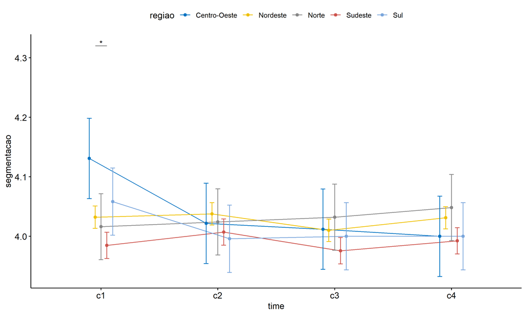

```r
if (length(non.ids) > 0) {
  pwc2 <- add_xy_position(pwc2, x = "time", fun = "mean_se", dodge = 0.25)
  pd2 <- position_dodge(width = 0.25)

  ggline(emms2, x = "time", y = "emmean", color = "regiao",
         palette = c("#0073C2FF","#EFC000FF","#868686FF","#CD534CFF","#7AA6DCFF"),
         position = pd, ylab = "segmentacao") +
    geom_errorbar(aes(ymin = conf.low, ymax = conf.high, color = regiao),
                position = pd, width = 0.2) +
    stat_pvalue_manual(pwc2, hide.ns = T, tip.length = F, linetype = 1)
}
```

```r
if (length(non.ids) > 0)
  (pwc2 <- ldat2 %>% group_by(regiao) %>%
     emmeans_test(segmentacao ~ time, detailed = T, p.adjust.method = "bonferroni"))
```

```
## # A tibble: 30 × 15
##    regiao     term  .y.   group1 group2 null.value estimate     se    df conf.low conf.high statistic
##  * <fct>      <chr> <chr> <chr>  <chr>       <dbl>    <dbl>  <dbl> <dbl>    <dbl>     <dbl>     <dbl>
##  1 Centro-Oe… time  segm… c1     c2              0  1.09e-1 0.0487  4388  0.0137     0.205     2.24
##  2 Centro-Oe… time  segm… c1     c3              0  1.19e-1 0.0487  4388  0.0236     0.215     2.44
##  3 Centro-Oe… time  segm… c1     c4              0  1.31e-1 0.0487  4388  0.0355     0.226     2.69
##  4 Centro-Oe… time  segm… c2     c3              0  9.92e-3 0.0487  4388 -0.0855     0.105     0.204
##  5 Centro-Oe… time  segm… c2     c4              0  2.18e-2 0.0487  4388 -0.0736     0.117     0.448
##  6 Centro-Oe… time  segm… c3     c4              0  1.19e-2 0.0487  4388 -0.0836     0.107     0.244
##  7 Nordeste   time  segm… c1     c2              0 -5.66e-3 0.0135  4388 -0.0322     0.0208   -0.419
##  8 Nordeste   time  segm… c1     c3              0  2.20e-2 0.0135  4388 -0.00448    0.0485    1.63
##  9 Nordeste   time  segm… c1     c4              0  9.17e-4 0.0135  4388 -0.0256     0.0274    0.0679
## 10 Nordeste   time  segm… c2     c3              0  2.77e-2 0.0135  4388  0.00117    0.0542    2.05
## # ℹ 20 more rows
## # ℹ 3 more variables: p <dbl>, p.adj <dbl>, p.adj.signif <chr>
```

| regiao | term | .y. | group1 | group2 | null.value | estimate | se | df | conf.low | conf.high | statistic | p | p.adj | p.adj.signif |
| --- | --- | --- | --- | --- | --- | --- | --- | --- | --- | --- | --- | --- | --- | --- |
| Centro-Oeste | time | segmentacao | c1 | c2 | 0 | 0.109 | 0.049 | 4388 | 0.014 | 0.205 | 2.241 | 0.025 | 0.150 | ns |
| Centro-Oeste | time | segmentacao | c1 | c3 | 0 | 0.119 | 0.049 | 4388 | 0.024 | 0.215 | 2.445 | 0.015 | 0.087 | ns |
| Centro-Oeste | time | segmentacao | c1 | c4 | 0 | 0.131 | 0.049 | 4388 | 0.035 | 0.226 | 2.689 | 0.007 | 0.043 | * |
| Centro-Oeste | time | segmentacao | c2 | c3 | 0 | 0.010 | 0.049 | 4388 | -0.086 | 0.105 | 0.204 | 0.839 | 1.000 | ns |
| Centro-Oeste | time | segmentacao | c2 | c4 | 0 | 0.022 | 0.049 | 4388 | -0.074 | 0.117 | 0.448 | 0.654 | 1.000 | ns |
| Centro-Oeste | time | segmentacao | c3 | c4 | 0 | 0.012 | 0.049 | 4388 | -0.084 | 0.107 | 0.244 | 0.807 | 1.000 | ns |
| Nordeste | time | segmentacao | c1 | c2 | 0 | -0.006 | 0.014 | 4388 | -0.032 | 0.021 | -0.419 | 0.676 | 1.000 | ns |
| Nordeste | time | segmentacao | c1 | c3 | 0 | 0.022 | 0.014 | 4388 | -0.004 | 0.049 | 1.629 | 0.103 | 0.620 | ns |
| Nordeste | time | segmentacao | c1 | c4 | 0 | 0.001 | 0.014 | 4388 | -0.026 | 0.027 | 0.068 | 0.946 | 1.000 | ns |
| Nordeste | time | segmentacao | c2 | c3 | 0 | 0.028 | 0.014 | 4388 | 0.001 | 0.054 | 2.047 | 0.041 | 0.244 | ns |
| Nordeste | time | segmentacao | c2 | c4 | 0 | 0.007 | 0.014 | 4388 | -0.020 | 0.033 | 0.486 | 0.627 | 1.000 | ns |
| Nordeste | time | segmentacao | c3 | c4 | 0 | -0.021 | 0.014 | 4388 | -0.048 | 0.005 | -1.561 | 0.119 | 0.712 | ns |
| Norte | time | segmentacao | c1 | c2 | 0 | -0.008 | 0.040 | 4388 | -0.087 | 0.071 | -0.201 | 0.841 | 1.000 | ns |
| Norte | time | segmentacao | c1 | c3 | 0 | -0.016 | 0.040 | 4388 | -0.095 | 0.062 | -0.402 | 0.687 | 1.000 | ns |
| Norte | time | segmentacao | c1 | c4 | 0 | -0.032 | 0.040 | 4388 | -0.111 | 0.046 | -0.805 | 0.421 | 1.000 | ns |
| Norte | time | segmentacao | c2 | c3 | 0 | -0.008 | 0.040 | 4388 | -0.087 | 0.071 | -0.201 | 0.841 | 1.000 | ns |
| Norte | time | segmentacao | c2 | c4 | 0 | -0.024 | 0.040 | 4388 | -0.103 | 0.054 | -0.604 | 0.546 | 1.000 | ns |
| Norte | time | segmentacao | c3 | c4 | 0 | -0.016 | 0.040 | 4388 | -0.095 | 0.062 | -0.402 | 0.687 | 1.000 | ns |
| Sudeste | time | segmentacao | c1 | c2 | 0 | -0.022 | 0.016 | 4388 | -0.054 | 0.009 | -1.412 | 0.158 | 0.948 | ns |
| Sudeste | time | segmentacao | c1 | c3 | 0 | 0.009 | 0.016 | 4388 | -0.022 | 0.040 | 0.559 | 0.576 | 1.000 | ns |
| Sudeste | time | segmentacao | c1 | c4 | 0 | -0.008 | 0.016 | 4388 | -0.039 | 0.024 | -0.480 | 0.632 | 1.000 | ns |
| Sudeste | time | segmentacao | c2 | c3 | 0 | 0.031 | 0.016 | 4388 | 0.000 | 0.063 | 1.971 | 0.049 | 0.292 | ns |
| Sudeste | time | segmentacao | c2 | c4 | 0 | 0.015 | 0.016 | 4388 | -0.016 | 0.046 | 0.932 | 0.351 | 1.000 | ns |
| Sudeste | time | segmentacao | c3 | c4 | 0 | -0.017 | 0.016 | 4388 | -0.048 | 0.015 | -1.039 | 0.299 | 1.000 | ns |
| Sul | time | segmentacao | c1 | c2 | 0 | 0.062 | 0.041 | 4388 | -0.017 | 0.142 | 1.534 | 0.125 | 0.750 | ns |
| Sul | time | segmentacao | c1 | c3 | 0 | 0.058 | 0.041 | 4388 | -0.022 | 0.138 | 1.432 | 0.152 | 0.914 | ns |
| Sul | time | segmentacao | c1 | c4 | 0 | 0.058 | 0.041 | 4388 | -0.022 | 0.138 | 1.432 | 0.152 | 0.914 | ns |
| Sul | time | segmentacao | c2 | c3 | 0 | -0.004 | 0.041 | 4388 | -0.084 | 0.076 | -0.102 | 0.919 | 1.000 | ns |
| Sul | time | segmentacao | c2 | c4 | 0 | -0.004 | 0.041 | 4388 | -0.084 | 0.076 | -0.102 | 0.919 | 1.000 | ns |
| Sul | time | segmentacao | c3 | c4 | 0 | 0.000 | 0.041 | 4388 | -0.080 | 0.080 | 0.000 | 1.000 | 1.000 | ns |

```r
if (length(non.ids) > 0)
  (emms2 <- get_emmeans(pwc2))
```

```
## # A tibble: 20 × 8
##    regiao       time  emmean      se    df conf.low conf.high method
##    <fct>        <fct>  <dbl>   <dbl> <dbl>    <dbl>     <dbl> <chr>
##  1 Centro-Oeste c1      4.13 0.0344   4388     4.06      4.20 Emmeans test
##  2 Centro-Oeste c2      4.02 0.0344   4388     3.95      4.09 Emmeans test
##  3 Centro-Oeste c3      4.01 0.0344   4388     3.94      4.08 Emmeans test
##  4 Centro-Oeste c4      4.00 0.0344   4388     3.93      4.07 Emmeans test
##  5 Nordeste     c1      4.03 0.00956  4388     4.01      4.05 Emmeans test
##  6 Nordeste     c2      4.04 0.00956  4388     4.02      4.06 Emmeans test
##  7 Nordeste     c3      4.01 0.00956  4388     3.99      4.03 Emmeans test
##  8 Nordeste     c4      4.03 0.00956  4388     4.01      4.05 Emmeans test
##  9 Norte        c1      4.02 0.0283   4388     3.96      4.07 Emmeans test
## 10 Norte        c2      4.02 0.0283   4388     3.97      4.08 Emmeans test
## 11 Norte        c3      4.03 0.0283   4388     3.98      4.09 Emmeans test
## 12 Norte        c4      4.05 0.0283   4388     3.99      4.10 Emmeans test
## 13 Sudeste      c1      3.98 0.0113   4388     3.96      4.01 Emmeans test
## 14 Sudeste      c2      4.01 0.0113   4388     3.99      4.03 Emmeans test
## 15 Sudeste      c3      3.98 0.0113   4388     3.95      4.00 Emmeans test
## 16 Sudeste      c4      3.99 0.0113   4388     3.97      4.01 Emmeans test
## 17 Sul          c1      4.06 0.0288   4388     4.00      4.11 Emmeans test
## 18 Sul          c2      4.00 0.0288   4388     3.94      4.05 Emmeans test
## 19 Sul          c3      4.00 0.0288   4388     3.94      4.06 Emmeans test
## 20 Sul          c4      4.00 0.0288   4388     3.94      4.06 Emmeans test
```

| regiao | time | emmean | se | df | conf.low | conf.high | method |
| --- | --- | --- | --- | --- | --- | --- | --- |
| Centro-Oeste | c1 | 4.131 | 0.034 | 4388 | 4.063 | 4.198 | Emmeans test |
| Centro-Oeste | c2 | 4.022 | 0.034 | 4388 | 3.954 | 4.089 | Emmeans test |
| Centro-Oeste | c3 | 4.012 | 0.034 | 4388 | 3.944 | 4.079 | Emmeans test |
| Centro-Oeste | c4 | 4.000 | 0.034 | 4388 | 3.932 | 4.068 | Emmeans test |
| Nordeste | c1 | 4.032 | 0.010 | 4388 | 4.013 | 4.051 | Emmeans test |
| Nordeste | c2 | 4.038 | 0.010 | 4388 | 4.019 | 4.057 | Emmeans test |
| Nordeste | c3 | 4.010 | 0.010 | 4388 | 3.991 | 4.029 | Emmeans test |
| Nordeste | c4 | 4.031 | 0.010 | 4388 | 4.012 | 4.050 | Emmeans test |
| Norte | c1 | 4.016 | 0.028 | 4388 | 3.961 | 4.072 | Emmeans test |
| Norte | c2 | 4.024 | 0.028 | 4388 | 3.969 | 4.080 | Emmeans test |
| Norte | c3 | 4.032 | 0.028 | 4388 | 3.977 | 4.088 | Emmeans test |
| Norte | c4 | 4.048 | 0.028 | 4388 | 3.993 | 4.104 | Emmeans test |
| Sudeste | c1 | 3.985 | 0.011 | 4388 | 3.963 | 4.007 | Emmeans test |
| Sudeste | c2 | 4.007 | 0.011 | 4388 | 3.985 | 4.029 | Emmeans test |
| Sudeste | c3 | 3.976 | 0.011 | 4388 | 3.954 | 3.998 | Emmeans test |
| Sudeste | c4 | 3.992 | 0.011 | 4388 | 3.970 | 4.014 | Emmeans test |
| Sul | c1 | 4.058 | 0.029 | 4388 | 4.002 | 4.115 | Emmeans test |
| Sul | c2 | 3.996 | 0.029 | 4388 | 3.939 | 4.052 | Emmeans test |
| Sul | c3 | 4.000 | 0.029 | 4388 | 3.944 | 4.056 | Emmeans test |
| Sul | c4 | 4.000 | 0.029 | 4388 | 3.944 | 4.056 | Emmeans test |

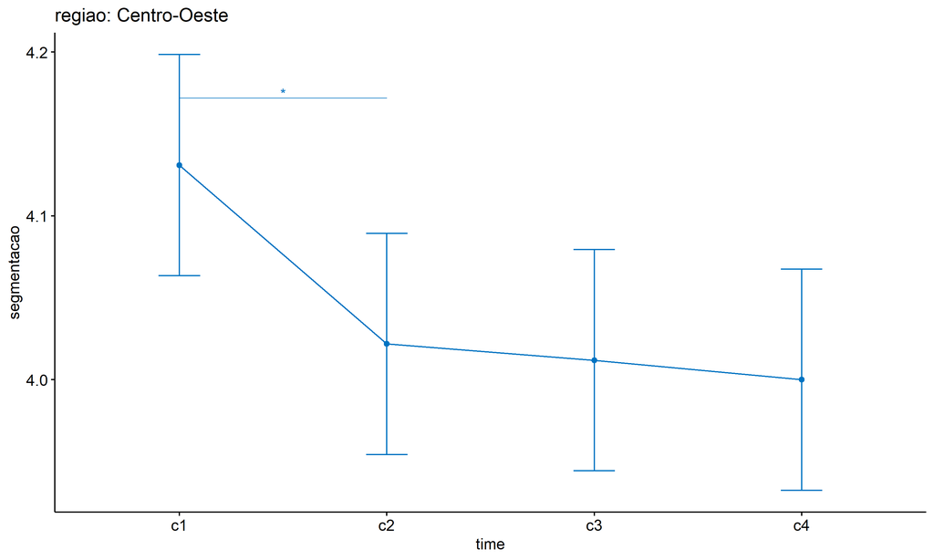

```r
if (length(non.ids) > 0) {
  emms.gg <- emms2[which(emms2$regiao == "Centro-Oeste"),]
  if (nrow(emms.gg) > 0)
    ggline(emms.gg, x = "time", y = "emmean", color = "#0073C2FF", ylab = "segmentacao") +
    geom_errorbar(aes(ymin = conf.low, ymax = conf.high),
                  width = 0.2, color = "#0073C2FF") +
    stat_pvalue_manual(
      add_xy_position(pwc[which(pwc$regiao == "Centro-Oeste"),],
                      x = "time", fun = "mean_se"),
      hide.ns = T, color = "#0073C2FF", tip.length = F) +
    labs(title = "regiao: Centro-Oeste") +
    theme(legend.text = element_blank())
}
```

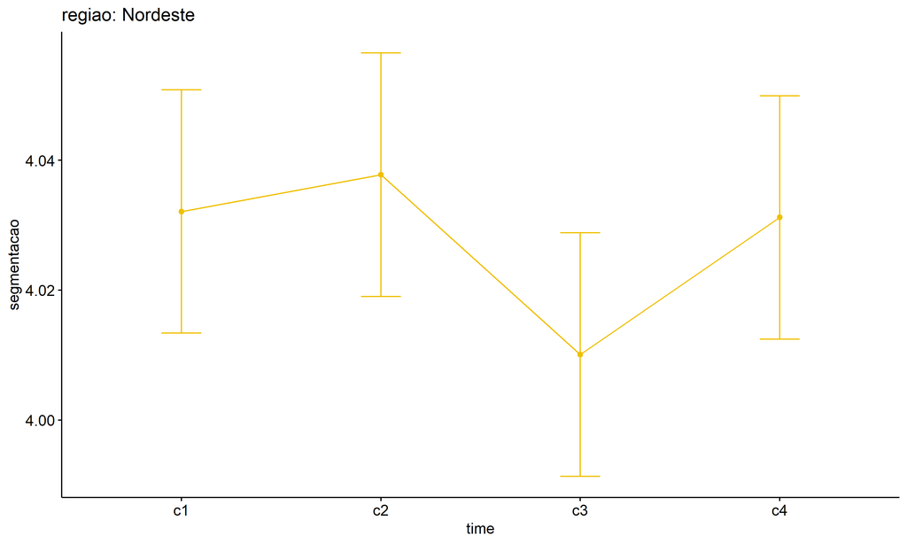

```r
if (length(non.ids) > 0) {
  emms.gg <- emms2[which(emms2$regiao == "Nordeste"),]
  if (nrow(emms.gg) > 0)
    ggline(emms.gg, x = "time", y = "emmean", color = "#EFC000FF", ylab = "segmentacao") +
    geom_errorbar(aes(ymin = conf.low, ymax = conf.high),
                  width = 0.2, color = "#EFC000FF") +
    stat_pvalue_manual(
      add_xy_position(pwc[which(pwc$regiao == "Nordeste"),],
                      x = "time", fun = "mean_se"),
      hide.ns = T, color = "#EFC000FF", tip.length = F) +
    labs(title = "regiao: Nordeste") +
    theme(legend.text = element_blank())
}
```

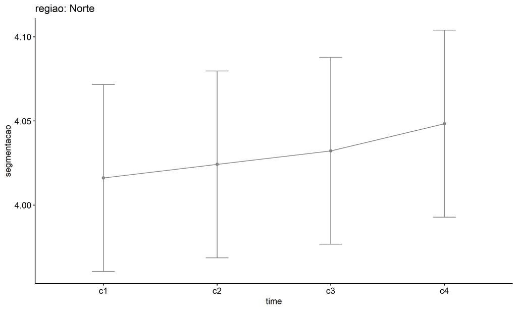

```r
if (length(non.ids) > 0) {
  emms.gg <- emms2[which(emms2$regiao == "Norte"),]
  if (nrow(emms.gg) > 0)
    ggline(emms.gg, x = "time", y = "emmean", color = "#868686FF", ylab = "segmentacao") +
    geom_errorbar(aes(ymin = conf.low, ymax = conf.high),
                  width = 0.2, color = "#868686FF") +
    stat_pvalue_manual(
      add_xy_position(pwc[which(pwc$regiao == "Norte"),],
                      x = "time", fun = "mean_se"),
      hide.ns = T, color = "#868686FF", tip.length = F) +
    labs(title = "regiao: Norte") +
    theme(legend.text = element_blank())
}
```

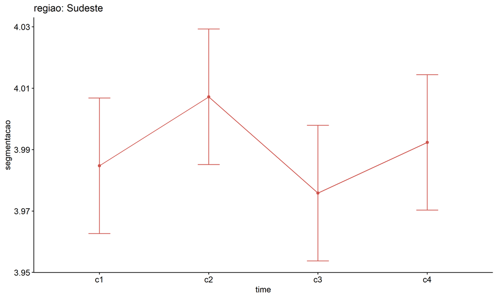

```r
if (length(non.ids) > 0) {
  emms.gg <- emms2[which(emms2$regiao == "Sudeste"),]
  if (nrow(emms.gg) > 0)
    ggline(emms.gg, x = "time", y = "emmean", color = "#CD534CFF", ylab = "segmentacao") +
    geom_errorbar(aes(ymin = conf.low, ymax = conf.high),
                  width = 0.2, color = "#CD534CFF") +
    stat_pvalue_manual(
      add_xy_position(pwc[which(pwc$regiao == "Sudeste"),],
                      x = "time", fun = "mean_se"),
      hide.ns = T, color = "#CD534CFF", tip.length = F) +
    labs(title = "regiao: Sudeste") +
    theme(legend.text = element_blank())
}
```

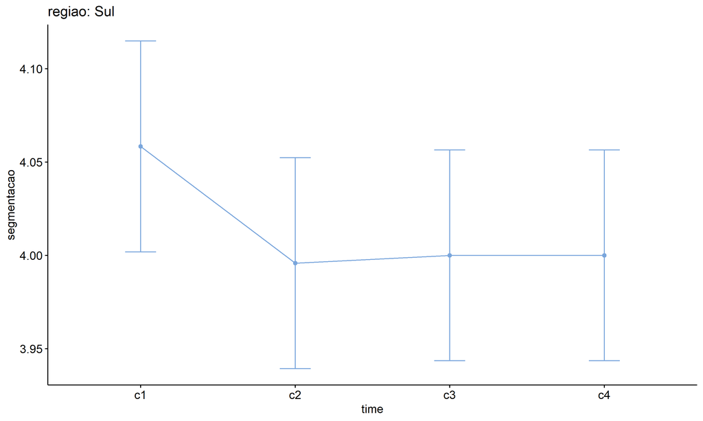

```r
if (length(non.ids) > 0) {
  emms.gg <- emms2[which(emms2$regiao == "Sul"),]
  if (nrow(emms.gg) > 0)
    ggline(emms.gg, x = "time", y = "emmean", color = "#7AA6DCFF", ylab = "segmentacao") +
    geom_errorbar(aes(ymin = conf.low, ymax = conf.high),
                  width = 0.2, color = "#7AA6DCFF") +
    stat_pvalue_manual(
      add_xy_position(pwc[which(pwc$regiao == "Sul"),],
                      x = "time", fun = "mean_se"),
      hide.ns = T, color = "#7AA6DCFF", tip.length = F) +
    labs(title = "regiao: Sul") +
    theme(legend.text = element_blank())
}
```

# ANOVA: segmentacao ~ time*porte + Error(id/time)

## Data Preparation

```r
data <- edat[,c("aluno_id","porte","ciclo","segmentacao")]
data <- data[data$ciclo %in% c("Primeiro Ciclo","Segundo Ciclo","Terceiro Ciclo","Quarto Ciclo"),]
data$ciclo <- factor(data$ciclo, c("Primeiro Ciclo","Segundo Ciclo","Terceiro Ciclo","Quarto Ciclo"))
data <- unique(data)

wdat <- spread(data, ciclo, segmentacao)
wdat <- wdat[complete.cases(wdat),]
colnames(wdat) <- c("id","porte","c1","c2","c3","c4")

ldat <- gather(wdat, key = time, value = segmentacao, c1,c2,c3,c4) %>%
  convert_as_factor(id, time)
ldat <- remove_group_data(ldat, "segmentacao", c("time", "porte"), n.limit = 30)
ldat$porte <- factor(ldat$porte, sort(unique(ldat$porte)))
```

### Check assumptions: Identifying Outliers

```r
outliers <- identify_outliers(group_by(ldat, time, porte), segmentacao)
(outliers <- outliers[outliers$is.extreme == T,])
```

```
## # A tibble: 443 × 6
##    porte                                       time  id             segmentacao is.outlier is.extreme
##    <fct>                                       <fct> <fct>                <dbl> <lgl>      <lgl>
##  1 Até 50 matrículas de escolarização          c1    KBTZEriJAFvcW…         3.5 TRUE       TRUE
##  2 Entre 201 e 500 matrículas de escolarização c1    1Ao7d6oeWOGn5…         4.5 TRUE       TRUE
##  3 Entre 201 e 500 matrículas de escolarização c1    1rGKIQ7fdZBOx…         5   TRUE       TRUE
##  4 Entre 201 e 500 matrículas de escolarização c1    2qbgEyCWhU8Ch…         5   TRUE       TRUE
##  5 Entre 201 e 500 matrículas de escolarização c1    46nUNvt4sDOPs…         3.5 TRUE       TRUE
##  6 Entre 201 e 500 matrículas de escolarização c1    4AM4nonwJ45Li…         4.5 TRUE       TRUE
##  7 Entre 201 e 500 matrículas de escolarização c1    4tC0rHbjrsSU8…         3.5 TRUE       TRUE
##  8 Entre 201 e 500 matrículas de escolarização c1    53lsfK6za4noV…         3   TRUE       TRUE
##  9 Entre 201 e 500 matrículas de escolarização c1    5AeP0IQ84CerI…         4.5 TRUE       TRUE
## 10 Entre 201 e 500 matrículas de escolarização c1    5aLGVYNAMR84k…         3   TRUE       TRUE
## # ℹ 433 more rows
```

| porte | time | id | segmentacao | is.outlier | is.extreme |
| --- | --- | --- | --- | --- | --- |
| Até 50 matrículas de escolarização | c1 | KBTZEriJAFvcWw48Xxgc | 3.500 | TRUE | TRUE |
| Entre 201 e 500 matrículas de escolarização | c1 | 1Ao7d6oeWOGn5CkNSJxn | 4.500 | TRUE | TRUE |
| Entre 201 e 500 matrículas de escolarização | c1 | 1rGKIQ7fdZBOxxGdPFrp | 5.000 | TRUE | TRUE |
| Entre 201 e 500 matrículas de escolarização | c1 | 2qbgEyCWhU8ChVoKwmf5 | 5.000 | TRUE | TRUE |
| Entre 201 e 500 matrículas de escolarização | c1 | 46nUNvt4sDOPsC9jnkiG | 3.500 | TRUE | TRUE |
| Entre 201 e 500 matrículas de escolarização | c1 | 4AM4nonwJ45LiMy6b4lp | 4.500 | TRUE | TRUE |
| Entre 201 e 500 matrículas de escolarização | c1 | 4tC0rHbjrsSU8gnHaaJ3 | 3.500 | TRUE | TRUE |
| Entre 201 e 500 matrículas de escolarização | c1 | 53lsfK6za4noVZe68et6 | 3.000 | TRUE | TRUE |
| Entre 201 e 500 matrículas de escolarização | c1 | 5AeP0IQ84CerIQVenp2G | 4.500 | TRUE | TRUE |
| Entre 201 e 500 matrículas de escolarização | c1 | 5aLGVYNAMR84kxneNKFw | 3.000 | TRUE | TRUE |
| Entre 201 e 500 matrículas de escolarização | c1 | 5WOchSZgUhx0OWTzb7cj | 3.000 | TRUE | TRUE |
| Entre 201 e 500 matrículas de escolarização | c1 | 7AsCrRYMyhVRQHX4kZdc | 3.000 | TRUE | TRUE |
| Entre 201 e 500 matrículas de escolarização | c1 | 7g3GunKKkHWAtnvcV4AX | 4.500 | TRUE | TRUE |
| Entre 201 e 500 matrículas de escolarização | c1 | 8TnTXVBQUI6JQuADMpd3 | 5.000 | TRUE | TRUE |
| Entre 201 e 500 matrículas de escolarização | c1 | 9ylUEO2PMilJk8pF3sWj | 3.500 | TRUE | TRUE |
| Entre 201 e 500 matrículas de escolarização | c1 | ao9Hy7cVw5W6MXhO5Ylm | 3.500 | TRUE | TRUE |
| Entre 201 e 500 matrículas de escolarização | c1 | aOGxFSPrreKjHqmQIKKA | 4.500 | TRUE | TRUE |
| Entre 201 e 500 matrículas de escolarização | c1 | aT7LCUsqZ1GEFzMoTQbc | 5.000 | TRUE | TRUE |
| Entre 201 e 500 matrículas de escolarização | c1 | atydp19vM0PjiOQCWemR | 5.000 | TRUE | TRUE |
| Entre 201 e 500 matrículas de escolarização | c1 | BCdMsV8b1rekzcjDGIe0 | 3.500 | TRUE | TRUE |
| Entre 201 e 500 matrículas de escolarização | c1 | bOhetFcZCcckN4VKJMtL | 3.000 | TRUE | TRUE |
| Entre 201 e 500 matrículas de escolarização | c1 | C9yrnovcTaV6PYqDq8Hh | 5.000 | TRUE | TRUE |
| Entre 201 e 500 matrículas de escolarização | c1 | CquTenVuBSFELLzcDuZm | 5.000 | TRUE | TRUE |
| Entre 201 e 500 matrículas de escolarização | c1 | CRe8TWnc28z2KudiaQpG | 4.500 | TRUE | TRUE |
| Entre 201 e 500 matrículas de escolarização | c1 | cuknOzzwN4oCRum5U5ph | 3.500 | TRUE | TRUE |
| Entre 201 e 500 matrículas de escolarização | c1 | cV5XHPnJL5QhFRSG3oM4 | 3.000 | TRUE | TRUE |
| Entre 201 e 500 matrículas de escolarização | c1 | Cwe3jJ7NE2J7kG6g1Ox7 | 5.000 | TRUE | TRUE |
| Entre 201 e 500 matrículas de escolarização | c1 | cWhCU9PZ3Uh5Q4Rfe7h1 | 3.500 | TRUE | TRUE |
| Entre 201 e 500 matrículas de escolarização | c1 | d1JgyezU4pt7F4SebGoe | 3.000 | TRUE | TRUE |
| Entre 201 e 500 matrículas de escolarização | c1 | dJQJl5Fk0r29tPHPdig0 | 3.000 | TRUE | TRUE |

[output cut: 413 more lines]

### Check assumptions: Normality Test

```r
(normality.df <- normality.test.per.groups(ldat, "segmentacao", c("time", "porte")))
```

```
##            var    variable time                                        porte   n   skewness
## 1  segmentacao segmentacao   c1           Até 50 matrículas de escolarização  33  0.0000000
## 2  segmentacao segmentacao   c1  Entre 201 e 500 matrículas de escolarização 675 -0.1745224
## 3  segmentacao segmentacao   c1 Entre 501 e 1000 matrículas de escolarização 249  0.5654681
## 4  segmentacao segmentacao   c1   Entre 51 e 200 matrículas de escolarização 162  0.6929588
## 5  segmentacao segmentacao   c2           Até 50 matrículas de escolarização  33  0.0000000
## 6  segmentacao segmentacao   c2  Entre 201 e 500 matrículas de escolarização 675  0.8401263
## 7  segmentacao segmentacao   c2 Entre 501 e 1000 matrículas de escolarização 249  1.0924844
## 8  segmentacao segmentacao   c2   Entre 51 e 200 matrículas de escolarização 162 -2.0311852
## 9  segmentacao segmentacao   c3           Até 50 matrículas de escolarização  33  0.0000000
## 10 segmentacao segmentacao   c3  Entre 201 e 500 matrículas de escolarização 675 -1.1782324
## 11 segmentacao segmentacao   c3 Entre 501 e 1000 matrículas de escolarização 249  0.9406684
## 12 segmentacao segmentacao   c3   Entre 51 e 200 matrículas de escolarização 162  0.0000000
## 13 segmentacao segmentacao   c4           Até 50 matrículas de escolarização  33  0.0000000
## 14 segmentacao segmentacao   c4  Entre 201 e 500 matrículas de escolarização 675  0.8429350
```

[output cut: 19 more lines]

| var | variable | time | porte | n | skewness | kurtosis | symmetry | statistic | method | p | p.signif | normality |
| --- | --- | --- | --- | --- | --- | --- | --- | --- | --- | --- | --- | --- |
| segmentacao | segmentacao | c1 | Até 50 matrículas de escolarização | 33 | 0.000 | 0.000 | few data | NA | NA | 1 | NA | NO |
| segmentacao | segmentacao | c1 | Entre 201 e 500 matrículas de escolarização | 675 | -0.175 | 6.419 | NO | 102.072 | D’Agostino | 0 | **** | - |
| segmentacao | segmentacao | c1 | Entre 501 e 1000 matrículas de escolarização | 249 | 0.565 | 6.229 | NO | 54.223 | D’Agostino | 0 | **** | - |
| segmentacao | segmentacao | c1 | Entre 51 e 200 matrículas de escolarização | 162 | 0.693 | 8.958 | NO | 50.639 | D’Agostino | 0 | **** | QQ |
| segmentacao | segmentacao | c2 | Até 50 matrículas de escolarização | 33 | 0.000 | 0.000 | few data | NA | NA | 1 | NA | NO |
| segmentacao | segmentacao | c2 | Entre 201 e 500 matrículas de escolarização | 675 | 0.840 | 9.615 | NO | 190.244 | D’Agostino | 0 | **** | - |
| segmentacao | segmentacao | c2 | Entre 501 e 1000 matrículas de escolarização | 249 | 1.092 | 13.008 | NO | 101.424 | D’Agostino | 0 | **** | - |
| segmentacao | segmentacao | c2 | Entre 51 e 200 matrículas de escolarização | 162 | -2.031 | 11.968 | NO | 101.832 | D’Agostino | 0 | **** | QQ |
| segmentacao | segmentacao | c3 | Até 50 matrículas de escolarização | 33 | 0.000 | 0.000 | few data | NA | NA | 1 | NA | NO |
| segmentacao | segmentacao | c3 | Entre 201 e 500 matrículas de escolarização | 675 | -1.178 | 20.192 | NO | 287.896 | D’Agostino | 0 | **** | - |
| segmentacao | segmentacao | c3 | Entre 501 e 1000 matrículas de escolarização | 249 | 0.941 | 14.250 | NO | 96.982 | D’Agostino | 0 | **** | - |
| segmentacao | segmentacao | c3 | Entre 51 e 200 matrículas de escolarização | 162 | 0.000 | 13.251 | NO | 47.869 | D’Agostino | 0 | **** | QQ |
| segmentacao | segmentacao | c4 | Até 50 matrículas de escolarização | 33 | 0.000 | 0.000 | few data | NA | NA | 1 | NA | NO |
| segmentacao | segmentacao | c4 | Entre 201 e 500 matrículas de escolarização | 675 | 0.843 | 14.320 | NO | 220.310 | D’Agostino | 0 | **** | - |
| segmentacao | segmentacao | c4 | Entre 501 e 1000 matrículas de escolarização | 249 | -1.194 | 16.930 | NO | 115.092 | D’Agostino | 0 | **** | - |
| segmentacao | segmentacao | c4 | Entre 51 e 200 matrículas de escolarização | 162 | 1.948 | 13.420 | NO | 101.876 | D’Agostino | 0 | **** | QQ |

```r
(non.ids <- unique(do.call(
  c, lapply(which(normality.df$normality == 'NO'), FUN = function(i) {
  idx = which(ldat$time == normality.df$time[i] &
                ldat$porte == normality.df$porte[i])
  getNonNormal(ldat$"segmentacao"[idx], ldat$id[idx])
}))))
```

```r
if (length(non.ids) > 0)
  ldat2 <- ldat[!ldat$id %in% non.ids,]
```

### Summary Statistics

```r
(sdat <- ldat %>% group_by(time, porte) %>%
   get_summary_stats(segmentacao, type = "mean_sd"))
```

```
## # A tibble: 16 × 6
##    porte                                        time  variable        n  mean    sd
##    <fct>                                        <fct> <fct>       <dbl> <dbl> <dbl>
##  1 Até 50 matrículas de escolarização           c1    segmentacao    33  3.98 0.087
##  2 Entre 201 e 500 matrículas de escolarização  c1    segmentacao   675  4.01 0.297
##  3 Entre 501 e 1000 matrículas de escolarização c1    segmentacao   249  4.04 0.296
##  4 Entre 51 e 200 matrículas de escolarização   c1    segmentacao   162  4.02 0.275
##  5 Até 50 matrículas de escolarização           c2    segmentacao    33  4.04 0.192
##  6 Entre 201 e 500 matrículas de escolarização  c2    segmentacao   675  4.03 0.25
##  7 Entre 501 e 1000 matrículas de escolarização c2    segmentacao   249  4.03 0.221
##  8 Entre 51 e 200 matrículas de escolarização   c2    segmentacao   162  3.97 0.223
##  9 Até 50 matrículas de escolarização           c3    segmentacao    33  4.01 0.087
## 10 Entre 201 e 500 matrículas de escolarização  c3    segmentacao   675  4.00 0.17
## 11 Entre 501 e 1000 matrículas de escolarização c3    segmentacao   249  4.01 0.218
## 12 Entre 51 e 200 matrículas de escolarização   c3    segmentacao   162  4    0.223
## 13 Até 50 matrículas de escolarização           c4    segmentacao    33  3.97 0.174
## 14 Entre 201 e 500 matrículas de escolarização  c4    segmentacao   675  4.02 0.21
## 15 Entre 501 e 1000 matrículas de escolarização c4    segmentacao   249  4.00 0.198
## 16 Entre 51 e 200 matrículas de escolarização   c4    segmentacao   162  4.03 0.209
```

| porte | time | variable | n | mean | sd |
| --- | --- | --- | --- | --- | --- |
| Até 50 matrículas de escolarização | c1 | segmentacao | 33 | 3.985 | 0.087 |
| Entre 201 e 500 matrículas de escolarização | c1 | segmentacao | 675 | 4.009 | 0.297 |
| Entre 501 e 1000 matrículas de escolarização | c1 | segmentacao | 249 | 4.036 | 0.296 |
| Entre 51 e 200 matrículas de escolarização | c1 | segmentacao | 162 | 4.022 | 0.275 |
| Até 50 matrículas de escolarização | c2 | segmentacao | 33 | 4.045 | 0.192 |
| Entre 201 e 500 matrículas de escolarização | c2 | segmentacao | 675 | 4.034 | 0.250 |
| Entre 501 e 1000 matrículas de escolarização | c2 | segmentacao | 249 | 4.026 | 0.221 |
| Entre 51 e 200 matrículas de escolarização | c2 | segmentacao | 162 | 3.967 | 0.223 |
| Até 50 matrículas de escolarização | c3 | segmentacao | 33 | 4.015 | 0.087 |
| Entre 201 e 500 matrículas de escolarização | c3 | segmentacao | 675 | 3.999 | 0.170 |
| Entre 501 e 1000 matrículas de escolarização | c3 | segmentacao | 249 | 4.006 | 0.218 |
| Entre 51 e 200 matrículas de escolarização | c3 | segmentacao | 162 | 4.000 | 0.223 |
| Até 50 matrículas de escolarização | c4 | segmentacao | 33 | 3.970 | 0.174 |
| Entre 201 e 500 matrículas de escolarização | c4 | segmentacao | 675 | 4.019 | 0.210 |
| Entre 501 e 1000 matrículas de escolarização | c4 | segmentacao | 249 | 3.998 | 0.198 |
| Entre 51 e 200 matrículas de escolarização | c4 | segmentacao | 162 | 4.034 | 0.209 |

```r
if (length(non.ids) > 0)
  (sdat <- ldat2 %>% group_by(time, porte) %>%
      get_summary_stats(segmentacao, type = "mean_sd"))
```

| porte | time | variable | n | mean | sd |
| --- | --- | --- | --- | --- | --- |
| Até 50 matrículas de escolarização | c1 | segmentacao | 33 | 3.985 | 0.087 |
| Entre 201 e 500 matrículas de escolarização | c1 | segmentacao | 675 | 4.009 | 0.297 |
| Entre 501 e 1000 matrículas de escolarização | c1 | segmentacao | 249 | 4.036 | 0.296 |
| Entre 51 e 200 matrículas de escolarização | c1 | segmentacao | 162 | 4.022 | 0.275 |
| Até 50 matrículas de escolarização | c2 | segmentacao | 33 | 4.045 | 0.192 |
| Entre 201 e 500 matrículas de escolarização | c2 | segmentacao | 675 | 4.034 | 0.250 |
| Entre 501 e 1000 matrículas de escolarização | c2 | segmentacao | 249 | 4.026 | 0.221 |
| Entre 51 e 200 matrículas de escolarização | c2 | segmentacao | 162 | 3.967 | 0.223 |
| Até 50 matrículas de escolarização | c3 | segmentacao | 33 | 4.015 | 0.087 |
| Entre 201 e 500 matrículas de escolarização | c3 | segmentacao | 675 | 3.999 | 0.170 |
| Entre 501 e 1000 matrículas de escolarização | c3 | segmentacao | 249 | 4.006 | 0.218 |
| Entre 51 e 200 matrículas de escolarização | c3 | segmentacao | 162 | 4.000 | 0.223 |
| Até 50 matrículas de escolarização | c4 | segmentacao | 33 | 3.970 | 0.174 |
| Entre 201 e 500 matrículas de escolarização | c4 | segmentacao | 675 | 4.019 | 0.210 |
| Entre 501 e 1000 matrículas de escolarização | c4 | segmentacao | 249 | 3.998 | 0.198 |
| Entre 51 e 200 matrículas de escolarização | c4 | segmentacao | 162 | 4.034 | 0.209 |

## ANOVA Computation

```r
(res.aov <- anova_test(ldat, dv = segmentacao, wid = id, between = porte, within = time))
```

```
## ANOVA Table (type III tests)
##
## $ANOVA
##       Effect DFn  DFd     F     p p<.05      ges
## 1      porte   3 1115 0.387 0.762       0.000288
## 2       time   3 3345 0.292 0.831       0.000190
## 3 porte:time   9 3345 1.996 0.036     * 0.004000
##
## $`Mauchly's Test for Sphericity`
##       Effect     W                               p p<.05
## 1       time 0.886 0.00000000000000000000000000256     *
## 2 porte:time 0.886 0.00000000000000000000000000256     *
##
## $`Sphericity Corrections`
##       Effect   GGe       DF[GG] p[GG] p[GG]<.05   HFe       DF[HF] p[HF] p[HF]<.05
## 1       time 0.925 2.77, 3094.1 0.816           0.928 2.78, 3102.6 0.816
## 2 porte:time 0.925 8.32, 3094.1 0.041         * 0.928 8.35, 3102.6 0.041         *
```

| Effect | DFn | DFd | F | p | p<.05 | ges |
| --- | --- | --- | --- | --- | --- | --- |
| porte | 3 | 1115 | 0.387 | 0.762 |  | 0.000 |
| time | 3 | 3345 | 0.292 | 0.831 |  | 0.000 |
| porte:time | 9 | 3345 | 1.996 | 0.036 | * | 0.004 |

| Effect | W | p | p<.05 |
| --- | --- | --- | --- |
| time | 0.886 | 0 | * |
| porte:time | 0.886 | 0 | * |

| Effect | GGe | DF[GG] | p[GG] | p[GG]<.05 | HFe | DF[HF] | p[HF] | p[HF]<.05 |
| --- | --- | --- | --- | --- | --- | --- | --- | --- |
| time | 0.925 | 2.77, 3094.1 | 0.816 |  | 0.928 | 2.78, 3102.6 | 0.816 |  |
| porte:time | 0.925 | 8.32, 3094.1 | 0.041 | * | 0.928 | 8.35, 3102.6 | 0.041 | * |

## ANOVA Computation after removing non.normal data

```r
if (length(non.ids) > 0)
  (res.aov2 <- anova_test(ldat2, dv = segmentacao, wid = id, between = porte , within = time))
```

## PairWise Computation

```r
(pwc <- ldat %>% group_by(time) %>%
   emmeans_test(segmentacao ~ porte, detailed = T, p.adjust.method = "bonferroni"))
```

```
## # A tibble: 24 × 15
##    time  term  .y.        group1 group2 null.value estimate     se    df conf.low conf.high statistic
##  * <fct> <chr> <chr>      <chr>  <chr>       <dbl>    <dbl>  <dbl> <dbl>    <dbl>     <dbl>     <dbl>
##  1 c1    porte segmentac… Até 5… Entre…          0 -0.0240  0.0417  4460 -0.106     0.0577     -0.577
##  2 c1    porte segmentac… Até 5… Entre…          0 -0.0513  0.0433  4460 -0.136     0.0336     -1.18
##  3 c1    porte segmentac… Até 5… Entre…          0 -0.0368  0.0447  4460 -0.124     0.0508     -0.823
##  4 c1    porte segmentac… Entre… Entre…          0 -0.0273  0.0173  4460 -0.0612    0.00673    -1.57
##  5 c1    porte segmentac… Entre… Entre…          0 -0.0127  0.0205  4460 -0.0528    0.0274     -0.622
##  6 c1    porte segmentac… Entre… Entre…          0  0.0145  0.0236  4460 -0.0317    0.0608      0.616
##  7 c2    porte segmentac… Até 5… Entre…          0  0.0114  0.0417  4460 -0.0703    0.0931      0.273
##  8 c2    porte segmentac… Até 5… Entre…          0  0.0194  0.0433  4460 -0.0656    0.104       0.447
##  9 c2    porte segmentac… Até 5… Entre…          0  0.0789  0.0447  4460 -0.00866   0.166       1.77
## 10 c2    porte segmentac… Entre… Entre…          0  0.00797 0.0173  4460 -0.0260    0.0420      0.460
## # ℹ 14 more rows
## # ℹ 3 more variables: p <dbl>, p.adj <dbl>, p.adj.signif <chr>
```

| time | term | .y. | group1 | group2 | null.value | estimate | se | df | conf.low | conf.high | statistic | p | p.adj | p.adj.signif |
| --- | --- | --- | --- | --- | --- | --- | --- | --- | --- | --- | --- | --- | --- | --- |
| c1 | porte | segmentacao | Até 50 matrículas de escolarização | Entre 201 e 500 matrículas de escolarização | 0 | -0.024 | 0.042 | 4460 | -0.106 | 0.058 | -0.577 | 0.564 | 1.000 | ns |
| c1 | porte | segmentacao | Até 50 matrículas de escolarização | Entre 501 e 1000 matrículas de escolarização | 0 | -0.051 | 0.043 | 4460 | -0.136 | 0.034 | -1.184 | 0.236 | 1.000 | ns |
| c1 | porte | segmentacao | Até 50 matrículas de escolarização | Entre 51 e 200 matrículas de escolarização | 0 | -0.037 | 0.045 | 4460 | -0.124 | 0.051 | -0.823 | 0.411 | 1.000 | ns |
| c1 | porte | segmentacao | Entre 201 e 500 matrículas de escolarização | Entre 501 e 1000 matrículas de escolarização | 0 | -0.027 | 0.017 | 4460 | -0.061 | 0.007 | -1.572 | 0.116 | 0.696 | ns |
| c1 | porte | segmentacao | Entre 201 e 500 matrículas de escolarização | Entre 51 e 200 matrículas de escolarização | 0 | -0.013 | 0.020 | 4460 | -0.053 | 0.027 | -0.622 | 0.534 | 1.000 | ns |
| c1 | porte | segmentacao | Entre 501 e 1000 matrículas de escolarização | Entre 51 e 200 matrículas de escolarização | 0 | 0.015 | 0.024 | 4460 | -0.032 | 0.061 | 0.616 | 0.538 | 1.000 | ns |
| c2 | porte | segmentacao | Até 50 matrículas de escolarização | Entre 201 e 500 matrículas de escolarização | 0 | 0.011 | 0.042 | 4460 | -0.070 | 0.093 | 0.273 | 0.785 | 1.000 | ns |
| c2 | porte | segmentacao | Até 50 matrículas de escolarização | Entre 501 e 1000 matrículas de escolarização | 0 | 0.019 | 0.043 | 4460 | -0.066 | 0.104 | 0.447 | 0.655 | 1.000 | ns |
| c2 | porte | segmentacao | Até 50 matrículas de escolarização | Entre 51 e 200 matrículas de escolarização | 0 | 0.079 | 0.045 | 4460 | -0.009 | 0.166 | 1.767 | 0.077 | 0.464 | ns |
| c2 | porte | segmentacao | Entre 201 e 500 matrículas de escolarização | Entre 501 e 1000 matrículas de escolarização | 0 | 0.008 | 0.017 | 4460 | -0.026 | 0.042 | 0.460 | 0.646 | 1.000 | ns |
| c2 | porte | segmentacao | Entre 201 e 500 matrículas de escolarização | Entre 51 e 200 matrículas de escolarização | 0 | 0.068 | 0.020 | 4460 | 0.027 | 0.108 | 3.300 | 0.001 | 0.006 | ** |
| c2 | porte | segmentacao | Entre 501 e 1000 matrículas de escolarização | Entre 51 e 200 matrículas de escolarização | 0 | 0.060 | 0.024 | 4460 | 0.013 | 0.106 | 2.523 | 0.012 | 0.070 | ns |
| c3 | porte | segmentacao | Até 50 matrículas de escolarização | Entre 201 e 500 matrículas de escolarização | 0 | 0.017 | 0.042 | 4460 | -0.065 | 0.098 | 0.399 | 0.690 | 1.000 | ns |
| c3 | porte | segmentacao | Até 50 matrículas de escolarização | Entre 501 e 1000 matrículas de escolarização | 0 | 0.009 | 0.043 | 4460 | -0.076 | 0.094 | 0.211 | 0.833 | 1.000 | ns |
| c3 | porte | segmentacao | Até 50 matrículas de escolarização | Entre 51 e 200 matrículas de escolarização | 0 | 0.015 | 0.045 | 4460 | -0.072 | 0.103 | 0.339 | 0.734 | 1.000 | ns |
| c3 | porte | segmentacao | Entre 201 e 500 matrículas de escolarização | Entre 501 e 1000 matrículas de escolarização | 0 | -0.008 | 0.017 | 4460 | -0.041 | 0.026 | -0.433 | 0.665 | 1.000 | ns |
| c3 | porte | segmentacao | Entre 201 e 500 matrículas de escolarização | Entre 51 e 200 matrículas de escolarização | 0 | -0.001 | 0.020 | 4460 | -0.042 | 0.039 | -0.072 | 0.942 | 1.000 | ns |
| c3 | porte | segmentacao | Entre 501 e 1000 matrículas de escolarização | Entre 51 e 200 matrículas de escolarização | 0 | 0.006 | 0.024 | 4460 | -0.040 | 0.052 | 0.255 | 0.799 | 1.000 | ns |
| c4 | porte | segmentacao | Até 50 matrículas de escolarização | Entre 201 e 500 matrículas de escolarização | 0 | -0.050 | 0.042 | 4460 | -0.131 | 0.032 | -1.189 | 0.235 | 1.000 | ns |
| c4 | porte | segmentacao | Até 50 matrículas de escolarização | Entre 501 e 1000 matrículas de escolarização | 0 | -0.028 | 0.043 | 4460 | -0.113 | 0.057 | -0.653 | 0.514 | 1.000 | ns |
| c4 | porte | segmentacao | Até 50 matrículas de escolarização | Entre 51 e 200 matrículas de escolarização | 0 | -0.064 | 0.045 | 4460 | -0.152 | 0.023 | -1.439 | 0.150 | 0.902 | ns |
| c4 | porte | segmentacao | Entre 201 e 500 matrículas de escolarização | Entre 501 e 1000 matrículas de escolarização | 0 | 0.021 | 0.017 | 4460 | -0.013 | 0.055 | 1.227 | 0.220 | 1.000 | ns |
| c4 | porte | segmentacao | Entre 201 e 500 matrículas de escolarização | Entre 51 e 200 matrículas de escolarização | 0 | -0.015 | 0.020 | 4460 | -0.055 | 0.025 | -0.718 | 0.473 | 1.000 | ns |
| c4 | porte | segmentacao | Entre 501 e 1000 matrículas de escolarização | Entre 51 e 200 matrículas de escolarização | 0 | -0.036 | 0.024 | 4460 | -0.082 | 0.010 | -1.524 | 0.128 | 0.766 | ns |

```r
(emms <- get_emmeans(pwc))
```

```
## # A tibble: 16 × 8
##    time  porte                                        emmean      se    df conf.low conf.high method
##    <fct> <fct>                                         <dbl>   <dbl> <dbl>    <dbl>     <dbl> <chr>
##  1 c1    Até 50 matrículas de escolarização             3.98 0.0407   4460     3.91      4.06 Emmean…
##  2 c1    Entre 201 e 500 matrículas de escolarização    4.01 0.00900  4460     3.99      4.03 Emmean…
##  3 c1    Entre 501 e 1000 matrículas de escolarização   4.04 0.0148   4460     4.01      4.07 Emmean…
##  4 c1    Entre 51 e 200 matrículas de escolarização     4.02 0.0184   4460     3.99      4.06 Emmean…
##  5 c2    Até 50 matrículas de escolarização             4.05 0.0407   4460     3.97      4.13 Emmean…
##  6 c2    Entre 201 e 500 matrículas de escolarização    4.03 0.00900  4460     4.02      4.05 Emmean…
##  7 c2    Entre 501 e 1000 matrículas de escolarização   4.03 0.0148   4460     4.00      4.06 Emmean…
##  8 c2    Entre 51 e 200 matrículas de escolarização     3.97 0.0184   4460     3.93      4.00 Emmean…
##  9 c3    Até 50 matrículas de escolarização             4.02 0.0407   4460     3.94      4.09 Emmean…
## 10 c3    Entre 201 e 500 matrículas de escolarização    4.00 0.00900  4460     3.98      4.02 Emmean…
## 11 c3    Entre 501 e 1000 matrículas de escolarização   4.01 0.0148   4460     3.98      4.04 Emmean…
## 12 c3    Entre 51 e 200 matrículas de escolarização     4.00 0.0184   4460     3.96      4.04 Emmean…
## 13 c4    Até 50 matrículas de escolarização             3.97 0.0407   4460     3.89      4.05 Emmean…
## 14 c4    Entre 201 e 500 matrículas de escolarização    4.02 0.00900  4460     4.00      4.04 Emmean…
## 15 c4    Entre 501 e 1000 matrículas de escolarização   4.00 0.0148   4460     3.97      4.03 Emmean…
## 16 c4    Entre 51 e 200 matrículas de escolarização     4.03 0.0184   4460     4.00      4.07 Emmean…
```

| time | porte | emmean | se | df | conf.low | conf.high | method |
| --- | --- | --- | --- | --- | --- | --- | --- |
| c1 | Até 50 matrículas de escolarização | 3.985 | 0.041 | 4460 | 3.905 | 4.065 | Emmeans test |
| c1 | Entre 201 e 500 matrículas de escolarização | 4.009 | 0.009 | 4460 | 3.991 | 4.027 | Emmeans test |
| c1 | Entre 501 e 1000 matrículas de escolarização | 4.036 | 0.015 | 4460 | 4.007 | 4.065 | Emmeans test |
| c1 | Entre 51 e 200 matrículas de escolarização | 4.022 | 0.018 | 4460 | 3.986 | 4.058 | Emmeans test |
| c2 | Até 50 matrículas de escolarização | 4.045 | 0.041 | 4460 | 3.966 | 4.125 | Emmeans test |
| c2 | Entre 201 e 500 matrículas de escolarização | 4.034 | 0.009 | 4460 | 4.016 | 4.052 | Emmeans test |
| c2 | Entre 501 e 1000 matrículas de escolarização | 4.026 | 0.015 | 4460 | 3.997 | 4.055 | Emmeans test |
| c2 | Entre 51 e 200 matrículas de escolarização | 3.967 | 0.018 | 4460 | 3.931 | 4.003 | Emmeans test |
| c3 | Até 50 matrículas de escolarização | 4.015 | 0.041 | 4460 | 3.935 | 4.095 | Emmeans test |
| c3 | Entre 201 e 500 matrículas de escolarização | 3.999 | 0.009 | 4460 | 3.981 | 4.016 | Emmeans test |
| c3 | Entre 501 e 1000 matrículas de escolarização | 4.006 | 0.015 | 4460 | 3.977 | 4.035 | Emmeans test |
| c3 | Entre 51 e 200 matrículas de escolarização | 4.000 | 0.018 | 4460 | 3.964 | 4.036 | Emmeans test |
| c4 | Até 50 matrículas de escolarização | 3.970 | 0.041 | 4460 | 3.890 | 4.049 | Emmeans test |
| c4 | Entre 201 e 500 matrículas de escolarização | 4.019 | 0.009 | 4460 | 4.002 | 4.037 | Emmeans test |
| c4 | Entre 501 e 1000 matrículas de escolarização | 3.998 | 0.015 | 4460 | 3.969 | 4.027 | Emmeans test |
| c4 | Entre 51 e 200 matrículas de escolarização | 4.034 | 0.018 | 4460 | 3.998 | 4.070 | Emmeans test |

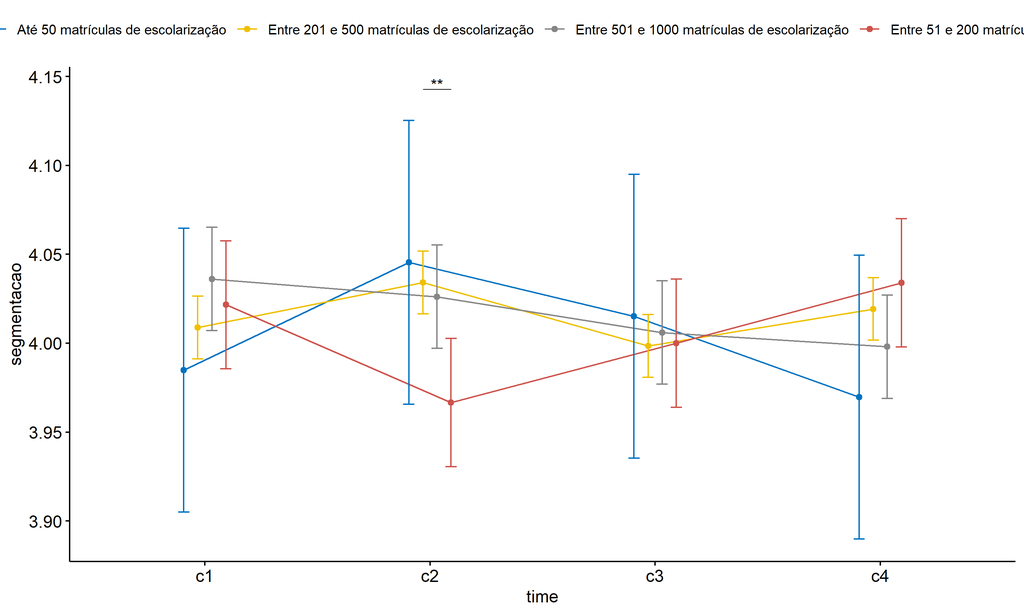

```r
pwc <- add_xy_position(pwc, x = "time", fun = "mean_se", dodge = 0.25)
pd <- position_dodge(width = 0.25)
ggline(emms, x = "time", y = "emmean", color = "porte",
       palette = c("#0073C2FF","#EFC000FF","#868686FF","#CD534CFF","#7AA6DCFF"),
       position = pd, ylab = "segmentacao") +
  geom_errorbar(aes(ymin = conf.low, ymax = conf.high, color = porte),
                position = pd, width = 0.2) +
  stat_pvalue_manual(pwc, hide.ns = T, tip.length = F, linetype = 1)
```

```r
(pwc <- ldat %>% group_by(porte) %>%
    emmeans_test(segmentacao ~ time, detailed = T, p.adjust.method = "bonferroni"))
```

```
## # A tibble: 24 × 15
##    porte      term  .y.   group1 group2 null.value estimate     se    df conf.low conf.high statistic
##  * <fct>      <chr> <chr> <chr>  <chr>       <dbl>    <dbl>  <dbl> <dbl>    <dbl>     <dbl>     <dbl>
##  1 Até 50 ma… time  segm… c1     c2              0  -0.0606 0.0576  4460  -0.173   0.0522      -1.05
##  2 Até 50 ma… time  segm… c1     c3              0  -0.0303 0.0576  4460  -0.143   0.0825      -0.526
##  3 Até 50 ma… time  segm… c1     c4              0   0.0152 0.0576  4460  -0.0977  0.128        0.263
##  4 Até 50 ma… time  segm… c2     c3              0   0.0303 0.0576  4460  -0.0825  0.143        0.526
##  5 Até 50 ma… time  segm… c2     c4              0   0.0758 0.0576  4460  -0.0371  0.189        1.32
##  6 Até 50 ma… time  segm… c3     c4              0   0.0455 0.0576  4460  -0.0674  0.158        0.790
##  7 Entre 201… time  segm… c1     c2              0  -0.0252 0.0127  4460  -0.0501 -0.000233    -1.98
##  8 Entre 201… time  segm… c1     c3              0   0.0104 0.0127  4460  -0.0146  0.0353       0.815
##  9 Entre 201… time  segm… c1     c4              0  -0.0104 0.0127  4460  -0.0353  0.0146      -0.815
## 10 Entre 201… time  segm… c2     c3              0   0.0356 0.0127  4460   0.0106  0.0605       2.79
## # ℹ 14 more rows
## # ℹ 3 more variables: p <dbl>, p.adj <dbl>, p.adj.signif <chr>
```

| porte | term | .y. | group1 | group2 | null.value | estimate | se | df | conf.low | conf.high | statistic | p | p.adj | p.adj.signif |
| --- | --- | --- | --- | --- | --- | --- | --- | --- | --- | --- | --- | --- | --- | --- |
| Até 50 matrículas de escolarização | time | segmentacao | c1 | c2 | 0 | -0.061 | 0.058 | 4460 | -0.173 | 0.052 | -1.053 | 0.292 | 1.000 | ns |
| Até 50 matrículas de escolarização | time | segmentacao | c1 | c3 | 0 | -0.030 | 0.058 | 4460 | -0.143 | 0.083 | -0.526 | 0.599 | 1.000 | ns |
| Até 50 matrículas de escolarização | time | segmentacao | c1 | c4 | 0 | 0.015 | 0.058 | 4460 | -0.098 | 0.128 | 0.263 | 0.792 | 1.000 | ns |
| Até 50 matrículas de escolarização | time | segmentacao | c2 | c3 | 0 | 0.030 | 0.058 | 4460 | -0.083 | 0.143 | 0.526 | 0.599 | 1.000 | ns |
| Até 50 matrículas de escolarização | time | segmentacao | c2 | c4 | 0 | 0.076 | 0.058 | 4460 | -0.037 | 0.189 | 1.316 | 0.188 | 1.000 | ns |
| Até 50 matrículas de escolarização | time | segmentacao | c3 | c4 | 0 | 0.045 | 0.058 | 4460 | -0.067 | 0.158 | 0.790 | 0.430 | 1.000 | ns |
| Entre 201 e 500 matrículas de escolarização | time | segmentacao | c1 | c2 | 0 | -0.025 | 0.013 | 4460 | -0.050 | 0.000 | -1.979 | 0.048 | 0.287 | ns |
| Entre 201 e 500 matrículas de escolarização | time | segmentacao | c1 | c3 | 0 | 0.010 | 0.013 | 4460 | -0.015 | 0.035 | 0.815 | 0.415 | 1.000 | ns |
| Entre 201 e 500 matrículas de escolarização | time | segmentacao | c1 | c4 | 0 | -0.010 | 0.013 | 4460 | -0.035 | 0.015 | -0.815 | 0.415 | 1.000 | ns |
| Entre 201 e 500 matrículas de escolarização | time | segmentacao | c2 | c3 | 0 | 0.036 | 0.013 | 4460 | 0.011 | 0.061 | 2.794 | 0.005 | 0.031 | * |
| Entre 201 e 500 matrículas de escolarização | time | segmentacao | c2 | c4 | 0 | 0.015 | 0.013 | 4460 | -0.010 | 0.040 | 1.164 | 0.244 | 1.000 | ns |
| Entre 201 e 500 matrículas de escolarização | time | segmentacao | c3 | c4 | 0 | -0.021 | 0.013 | 4460 | -0.046 | 0.004 | -1.630 | 0.103 | 0.620 | ns |
| Entre 501 e 1000 matrículas de escolarização | time | segmentacao | c1 | c2 | 0 | 0.010 | 0.021 | 4460 | -0.031 | 0.051 | 0.479 | 0.632 | 1.000 | ns |
| Entre 501 e 1000 matrículas de escolarização | time | segmentacao | c1 | c3 | 0 | 0.030 | 0.021 | 4460 | -0.011 | 0.071 | 1.437 | 0.151 | 0.904 | ns |
| Entre 501 e 1000 matrículas de escolarização | time | segmentacao | c1 | c4 | 0 | 0.038 | 0.021 | 4460 | -0.003 | 0.079 | 1.821 | 0.069 | 0.412 | ns |
| Entre 501 e 1000 matrículas de escolarização | time | segmentacao | c2 | c3 | 0 | 0.020 | 0.021 | 4460 | -0.021 | 0.061 | 0.958 | 0.338 | 1.000 | ns |
| Entre 501 e 1000 matrículas de escolarização | time | segmentacao | c2 | c4 | 0 | 0.028 | 0.021 | 4460 | -0.013 | 0.069 | 1.342 | 0.180 | 1.000 | ns |
| Entre 501 e 1000 matrículas de escolarização | time | segmentacao | c3 | c4 | 0 | 0.008 | 0.021 | 4460 | -0.033 | 0.049 | 0.383 | 0.702 | 1.000 | ns |
| Entre 51 e 200 matrículas de escolarização | time | segmentacao | c1 | c2 | 0 | 0.055 | 0.026 | 4460 | 0.004 | 0.106 | 2.119 | 0.034 | 0.205 | ns |
| Entre 51 e 200 matrículas de escolarização | time | segmentacao | c1 | c3 | 0 | 0.022 | 0.026 | 4460 | -0.029 | 0.073 | 0.832 | 0.406 | 1.000 | ns |
| Entre 51 e 200 matrículas de escolarização | time | segmentacao | c1 | c4 | 0 | -0.012 | 0.026 | 4460 | -0.063 | 0.039 | -0.475 | 0.635 | 1.000 | ns |
| Entre 51 e 200 matrículas de escolarização | time | segmentacao | c2 | c3 | 0 | -0.033 | 0.026 | 4460 | -0.084 | 0.017 | -1.287 | 0.198 | 1.000 | ns |
| Entre 51 e 200 matrículas de escolarização | time | segmentacao | c2 | c4 | 0 | -0.067 | 0.026 | 4460 | -0.118 | -0.016 | -2.594 | 0.010 | 0.057 | ns |
| Entre 51 e 200 matrículas de escolarização | time | segmentacao | c3 | c4 | 0 | -0.034 | 0.026 | 4460 | -0.085 | 0.017 | -1.307 | 0.191 | 1.000 | ns |

```r
(emms <- get_emmeans(pwc))
```

```
## # A tibble: 16 × 8
##    porte                                        time  emmean      se    df conf.low conf.high method
##    <fct>                                        <fct>  <dbl>   <dbl> <dbl>    <dbl>     <dbl> <chr>
##  1 Até 50 matrículas de escolarização           c1      3.98 0.0407   4460     3.91      4.06 Emmean…
##  2 Até 50 matrículas de escolarização           c2      4.05 0.0407   4460     3.97      4.13 Emmean…
##  3 Até 50 matrículas de escolarização           c3      4.02 0.0407   4460     3.94      4.09 Emmean…
##  4 Até 50 matrículas de escolarização           c4      3.97 0.0407   4460     3.89      4.05 Emmean…
##  5 Entre 201 e 500 matrículas de escolarização  c1      4.01 0.00900  4460     3.99      4.03 Emmean…
##  6 Entre 201 e 500 matrículas de escolarização  c2      4.03 0.00900  4460     4.02      4.05 Emmean…
##  7 Entre 201 e 500 matrículas de escolarização  c3      4.00 0.00900  4460     3.98      4.02 Emmean…
##  8 Entre 201 e 500 matrículas de escolarização  c4      4.02 0.00900  4460     4.00      4.04 Emmean…
##  9 Entre 501 e 1000 matrículas de escolarização c1      4.04 0.0148   4460     4.01      4.07 Emmean…
## 10 Entre 501 e 1000 matrículas de escolarização c2      4.03 0.0148   4460     4.00      4.06 Emmean…
## 11 Entre 501 e 1000 matrículas de escolarização c3      4.01 0.0148   4460     3.98      4.04 Emmean…
## 12 Entre 501 e 1000 matrículas de escolarização c4      4.00 0.0148   4460     3.97      4.03 Emmean…
## 13 Entre 51 e 200 matrículas de escolarização   c1      4.02 0.0184   4460     3.99      4.06 Emmean…
## 14 Entre 51 e 200 matrículas de escolarização   c2      3.97 0.0184   4460     3.93      4.00 Emmean…
## 15 Entre 51 e 200 matrículas de escolarização   c3      4.00 0.0184   4460     3.96      4.04 Emmean…
## 16 Entre 51 e 200 matrículas de escolarização   c4      4.03 0.0184   4460     4.00      4.07 Emmean…
```

| porte | time | emmean | se | df | conf.low | conf.high | method |
| --- | --- | --- | --- | --- | --- | --- | --- |
| Até 50 matrículas de escolarização | c1 | 3.985 | 0.041 | 4460 | 3.905 | 4.065 | Emmeans test |
| Até 50 matrículas de escolarização | c2 | 4.045 | 0.041 | 4460 | 3.966 | 4.125 | Emmeans test |
| Até 50 matrículas de escolarização | c3 | 4.015 | 0.041 | 4460 | 3.935 | 4.095 | Emmeans test |
| Até 50 matrículas de escolarização | c4 | 3.970 | 0.041 | 4460 | 3.890 | 4.049 | Emmeans test |
| Entre 201 e 500 matrículas de escolarização | c1 | 4.009 | 0.009 | 4460 | 3.991 | 4.027 | Emmeans test |
| Entre 201 e 500 matrículas de escolarização | c2 | 4.034 | 0.009 | 4460 | 4.016 | 4.052 | Emmeans test |
| Entre 201 e 500 matrículas de escolarização | c3 | 3.999 | 0.009 | 4460 | 3.981 | 4.016 | Emmeans test |
| Entre 201 e 500 matrículas de escolarização | c4 | 4.019 | 0.009 | 4460 | 4.002 | 4.037 | Emmeans test |
| Entre 501 e 1000 matrículas de escolarização | c1 | 4.036 | 0.015 | 4460 | 4.007 | 4.065 | Emmeans test |
| Entre 501 e 1000 matrículas de escolarização | c2 | 4.026 | 0.015 | 4460 | 3.997 | 4.055 | Emmeans test |
| Entre 501 e 1000 matrículas de escolarização | c3 | 4.006 | 0.015 | 4460 | 3.977 | 4.035 | Emmeans test |
| Entre 501 e 1000 matrículas de escolarização | c4 | 3.998 | 0.015 | 4460 | 3.969 | 4.027 | Emmeans test |
| Entre 51 e 200 matrículas de escolarização | c1 | 4.022 | 0.018 | 4460 | 3.986 | 4.058 | Emmeans test |
| Entre 51 e 200 matrículas de escolarização | c2 | 3.967 | 0.018 | 4460 | 3.931 | 4.003 | Emmeans test |
| Entre 51 e 200 matrículas de escolarização | c3 | 4.000 | 0.018 | 4460 | 3.964 | 4.036 | Emmeans test |
| Entre 51 e 200 matrículas de escolarização | c4 | 4.034 | 0.018 | 4460 | 3.998 | 4.070 | Emmeans test |

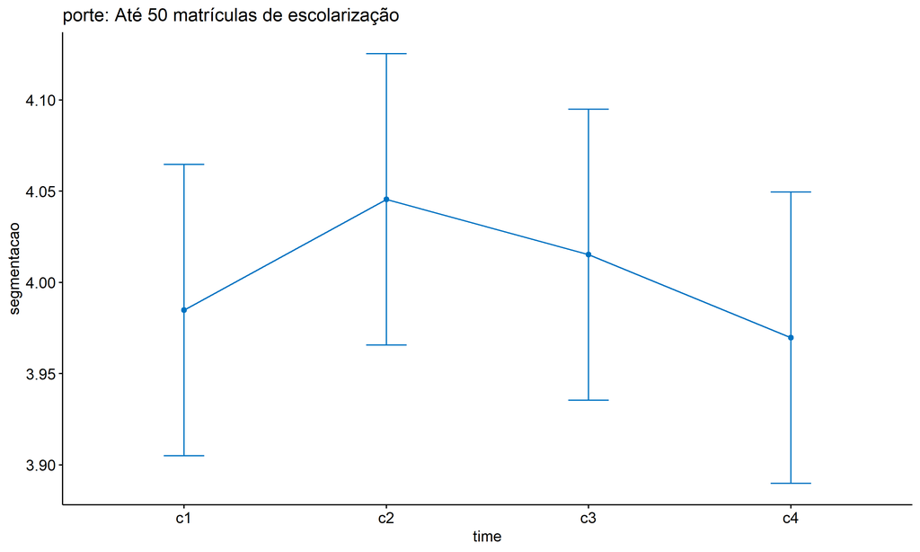

```r
emms.gg <- emms[which(emms$porte == "Até 50 matrículas de escolarização"),]
if (nrow(emms.gg) > 0)
  ggline(emms.gg, x = "time", y = "emmean", color = "#0073C2FF", ylab = "segmentacao") +
    geom_errorbar(aes(ymin = conf.low, ymax = conf.high),
                  width = 0.2, color = "#0073C2FF") +
    stat_pvalue_manual(
      add_xy_position(pwc[which(pwc$porte == "Até 50 matrículas de escolarização"),],
                      x = "time", fun = "mean_se"),
      hide.ns = T, color = "#0073C2FF", tip.length = F) +
    labs(title = "porte: Até 50 matrículas de escolarização")+
    theme(legend.text = element_blank())
```

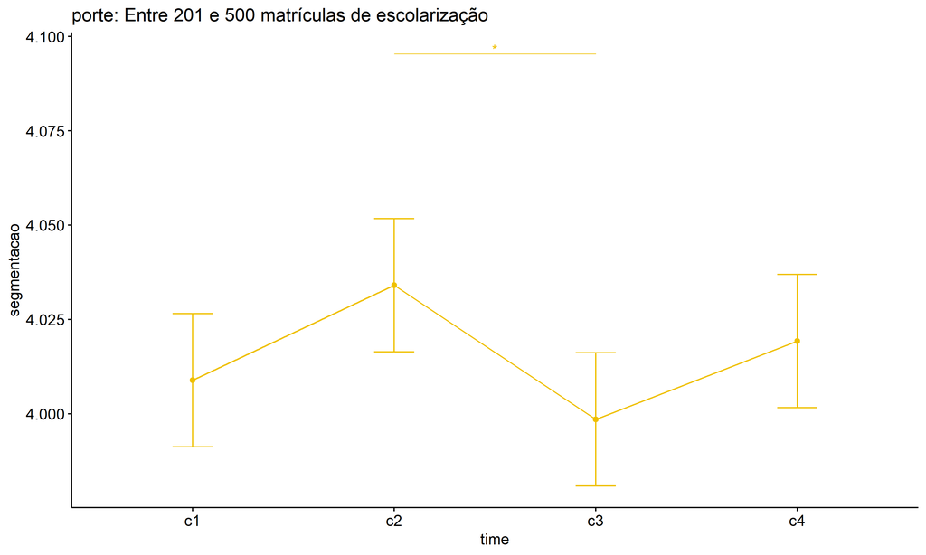

```r
emms.gg <- emms[which(emms$porte == "Entre 201 e 500 matrículas de escolarização"),]
if (nrow(emms.gg) > 0)
  ggline(emms.gg, x = "time", y = "emmean", color = "#EFC000FF", ylab = "segmentacao") +
    geom_errorbar(aes(ymin = conf.low, ymax = conf.high),
                  width = 0.2, color = "#EFC000FF") +
    stat_pvalue_manual(
      add_xy_position(pwc[which(pwc$porte == "Entre 201 e 500 matrículas de escolarização"),],
                      x = "time", fun = "mean_se"),
      hide.ns = T, color = "#EFC000FF", tip.length = F) +
    labs(title = "porte: Entre 201 e 500 matrículas de escolarização")+
    theme(legend.text = element_blank())
```

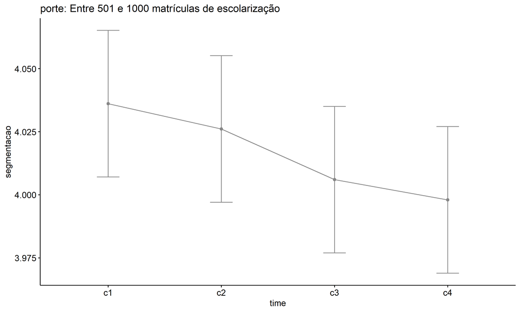

```r
emms.gg <- emms[which(emms$porte == "Entre 501 e 1000 matrículas de escolarização"),]
if (nrow(emms.gg) > 0)
  ggline(emms.gg, x = "time", y = "emmean", color = "#868686FF", ylab = "segmentacao") +
    geom_errorbar(aes(ymin = conf.low, ymax = conf.high),
                  width = 0.2, color = "#868686FF") +
    stat_pvalue_manual(
      add_xy_position(pwc[which(pwc$porte == "Entre 501 e 1000 matrículas de escolarização"),],
                      x = "time", fun = "mean_se"),
      hide.ns = T, color = "#868686FF", tip.length = F) +
    labs(title = "porte: Entre 501 e 1000 matrículas de escolarização")+
    theme(legend.text = element_blank())
```

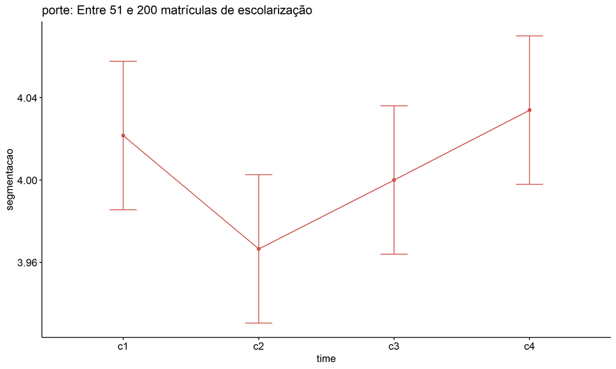

```r
emms.gg <- emms[which(emms$porte == "Entre 51 e 200 matrículas de escolarização"),]
if (nrow(emms.gg) > 0)
  ggline(emms.gg, x = "time", y = "emmean", color = "#CD534CFF", ylab = "segmentacao") +
    geom_errorbar(aes(ymin = conf.low, ymax = conf.high),
                  width = 0.2, color = "#CD534CFF") +
    stat_pvalue_manual(
      add_xy_position(pwc[which(pwc$porte == "Entre 51 e 200 matrículas de escolarização"),],
                      x = "time", fun = "mean_se"),
      hide.ns = T, color = "#CD534CFF", tip.length = F) +
    labs(title = "porte: Entre 51 e 200 matrículas de escolarização")+
    theme(legend.text = element_blank())
```

```r
emms.gg <- emms[which(emms$porte == "Mais de 1000 matrículas de escolarização"),]
if (nrow(emms.gg) > 0)
  ggline(emms.gg, x = "time", y = "emmean", color = "#7AA6DCFF", ylab = "segmentacao") +
    geom_errorbar(aes(ymin = conf.low, ymax = conf.high),
                  width = 0.2, color = "#7AA6DCFF") +
    stat_pvalue_manual(
      add_xy_position(pwc[which(pwc$porte == "Mais de 1000 matrículas de escolarização"),],
                      x = "time", fun = "mean_se"),
      hide.ns = T, color = "#7AA6DCFF", tip.length = F) +
    labs(title = "porte: Mais de 1000 matrículas de escolarização")+
    theme(legend.text = element_blank())
```

## PairWise Computation after removing non.normal data

```r
if (length(non.ids) > 0)
  (pwc2 <- ldat2 %>% group_by(time) %>%
     emmeans_test(segmentacao ~ porte, detailed = T, p.adjust.method = "bonferroni"))
```

```r
if (length(non.ids) > 0)
  (emms2 <- get_emmeans(pwc2))
```

```r
if (length(non.ids) > 0) {
  pwc2 <- add_xy_position(pwc2, x = "time", fun = "mean_se", dodge = 0.25)
  pd2 <- position_dodge(width = 0.25)

  ggline(emms2, x = "time", y = "emmean", color = "porte",
         palette = c("#0073C2FF","#EFC000FF","#868686FF","#CD534CFF","#7AA6DCFF"),
         position = pd, ylab = "segmentacao") +
    geom_errorbar(aes(ymin = conf.low, ymax = conf.high, color = porte),
                position = pd, width = 0.2) +
    stat_pvalue_manual(pwc2, hide.ns = T, tip.length = F, linetype = 1)
}
```

```r
if (length(non.ids) > 0)
  (pwc2 <- ldat2 %>% group_by(porte) %>%
     emmeans_test(segmentacao ~ time, detailed = T, p.adjust.method = "bonferroni"))
```

```r
if (length(non.ids) > 0)
  (emms2 <- get_emmeans(pwc2))
```

```r
if (length(non.ids) > 0) {
  emms.gg <- emms2[which(emms2$porte == "Até 50 matrículas de escolarização"),]
  if (nrow(emms.gg) > 0)
    ggline(emms.gg, x = "time", y = "emmean", color = "#0073C2FF", ylab = "segmentacao") +
    geom_errorbar(aes(ymin = conf.low, ymax = conf.high),
                  width = 0.2, color = "#0073C2FF") +
    stat_pvalue_manual(
      add_xy_position(pwc[which(pwc$porte == "Até 50 matrículas de escolarização"),],
                      x = "time", fun = "mean_se"),
      hide.ns = T, color = "#0073C2FF", tip.length = F) +
    labs(title = "porte: Até 50 matrículas de escolarização") +
    theme(legend.text = element_blank())
}
```

```r
if (length(non.ids) > 0) {
  emms.gg <- emms2[which(emms2$porte == "Entre 201 e 500 matrículas de escolarização"),]
  if (nrow(emms.gg) > 0)
    ggline(emms.gg, x = "time", y = "emmean", color = "#EFC000FF", ylab = "segmentacao") +
    geom_errorbar(aes(ymin = conf.low, ymax = conf.high),
                  width = 0.2, color = "#EFC000FF") +
    stat_pvalue_manual(
      add_xy_position(pwc[which(pwc$porte == "Entre 201 e 500 matrículas de escolarização"),],
                      x = "time", fun = "mean_se"),
      hide.ns = T, color = "#EFC000FF", tip.length = F) +
    labs(title = "porte: Entre 201 e 500 matrículas de escolarização") +
    theme(legend.text = element_blank())
}
```

```r
if (length(non.ids) > 0) {
  emms.gg <- emms2[which(emms2$porte == "Entre 501 e 1000 matrículas de escolarização"),]
  if (nrow(emms.gg) > 0)
    ggline(emms.gg, x = "time", y = "emmean", color = "#868686FF", ylab = "segmentacao") +
    geom_errorbar(aes(ymin = conf.low, ymax = conf.high),
                  width = 0.2, color = "#868686FF") +
    stat_pvalue_manual(
      add_xy_position(pwc[which(pwc$porte == "Entre 501 e 1000 matrículas de escolarização"),],
                      x = "time", fun = "mean_se"),
      hide.ns = T, color = "#868686FF", tip.length = F) +
    labs(title = "porte: Entre 501 e 1000 matrículas de escolarização") +
    theme(legend.text = element_blank())
}
```

```r
if (length(non.ids) > 0) {
  emms.gg <- emms2[which(emms2$porte == "Entre 51 e 200 matrículas de escolarização"),]
  if (nrow(emms.gg) > 0)
    ggline(emms.gg, x = "time", y = "emmean", color = "#CD534CFF", ylab = "segmentacao") +
    geom_errorbar(aes(ymin = conf.low, ymax = conf.high),
                  width = 0.2, color = "#CD534CFF") +
    stat_pvalue_manual(
      add_xy_position(pwc[which(pwc$porte == "Entre 51 e 200 matrículas de escolarização"),],
                      x = "time", fun = "mean_se"),
      hide.ns = T, color = "#CD534CFF", tip.length = F) +
    labs(title = "porte: Entre 51 e 200 matrículas de escolarização") +
    theme(legend.text = element_blank())
}
```

```r
if (length(non.ids) > 0) {
  emms.gg <- emms2[which(emms2$porte == "Mais de 1000 matrículas de escolarização"),]
  if (nrow(emms.gg) > 0)
    ggline(emms.gg, x = "time", y = "emmean", color = "#7AA6DCFF", ylab = "segmentacao") +
    geom_errorbar(aes(ymin = conf.low, ymax = conf.high),
                  width = 0.2, color = "#7AA6DCFF") +
    stat_pvalue_manual(
      add_xy_position(pwc[which(pwc$porte == "Mais de 1000 matrículas de escolarização"),],
                      x = "time", fun = "mean_se"),
      hide.ns = T, color = "#7AA6DCFF", tip.length = F) +
    labs(title = "porte: Mais de 1000 matrículas de escolarização") +
    theme(legend.text = element_blank())
}
```